# EDA prediksi kerusakan PART dalam 30 hari - OMEXP

Laporan ini memeriksa apakah histori perjalanan PART cukup konsisten untuk membentuk dataset prediksi failure dalam 30 hari. Kerusakan dihitung dari onset yang terkonfirmasi; RECON, relocation, RETURNED, dan proses repair tidak otomatis menjadi failure. Seluruh analisis hanya membaca tabel sumber.

```python
from pathlib import Path
import os, sys
import pandas as pd
import numpy as np
import matplotlib.pyplot as plt
import seaborn as sns
from IPython.display import Markdown, display
PROJECT_DIR = Path.cwd() if (Path.cwd() / 'src').exists() else Path.cwd().parent
sys.path.insert(0, str(PROJECT_DIR / 'src'))
from database import connect
sns.set_theme(style='whitegrid')
def query(sql, params=None):
    with connect() as conn:
        with conn.cursor() as cur:
            cur.execute(sql, params or ())
            return pd.DataFrame(cur.fetchall(), columns=[d.name for d in cur.description])
```

## 0. Objective dan pertanyaan analisis

**Objective:** menilai apakah histori journey PART cukup konsisten untuk membentuk dataset prediksi kerusakan dalam 30 hari, mengetahui pola failure berdasarkan waktu, model, lokasi, dan riwayat operasional, serta menentukan data dan fitur yang layak diteruskan ke baseline model.

Pertanyaan yang harus dijawab:

1. Apakah jumlah dan kualitas datanya cukup?
2. Apa definisi failure yang menjadi ground truth?
3. Seberapa sering failure terjadi?
4. Model dan lokasi mana yang memiliki hubungan dengan risiko lebih tinggi?
5. Fitur apa yang terlihat informatif dan mana yang redundan?
6. Apakah pola dan fitur stabil dari waktu ke waktu?
7. Data atau fitur apa yang belum boleh dipakai?

Setiap chapter mengikuti pola: **pertanyaan -> alasan -> metrik -> hasil -> interpretasi -> keputusan**.

## 1. Konteks bisnis dan definisi data

Konteks utama adalah PART yang berpindah melalui event operasional. TERMINAL dipisahkan karena populasi failure-nya berbeda. Definisi berikut digunakan konsisten di SQL, EDA, dan dataset snapshot.

| Istilah | Arti sederhana |
| --- | --- |
| **Model item** | Jenis atau tipe barang. Satu model dapat dimiliki banyak unit fisik. |
| **Unit item** | Satu barang fisik yang dibedakan dengan identifier atau serial. |
| **PART** | Komponen yang dipasang pada perangkat atau lokasi dan menjadi objek utama prediksi failure. |
| **TERMINAL** | Perangkat terminal. Jumlah dan pola failure-nya dipisahkan dari PART. |
| **Master data** | Daftar resmi model, lokasi, klien, status, dan jenis pekerjaan yang menjadi acuan validasi. |
| **Journey/event** | Satu catatan kegiatan atau perubahan status sebuah item pada suatu waktu. |
| **Operational event** | Event dengan waktu yang layak dipakai. RECON administratif dan tanggal tidak valid tidak ikut menghitung durasi. |
| **Installation cycle** | Periode sejak PART dipasang sampai failure pertama, pemasangan berikutnya, atau akhir data. |
| **Failure onset** | Waktu awal PART dianggap berhenti beroperasi karena kerusakan. |
| **Failure outcome** | Status yang mengonfirmasi hasil kerusakan, misalnya BROKEN atau UNREPAIRABLE. |
| **Snapshot** | Foto kondisi data PART pada satu tanggal, bukan foto gambar. Satu PART dapat memiliki banyak snapshot. |
| **Target 30 hari** | Pertanyaan apakah failure terjadi setelah snapshot dan paling lambat 30 hari berikutnya. |
| **Positif** | Snapshot yang benar-benar diikuti failure dalam 30 hari. |
| **Negatif** | Snapshot yang tidak diikuti failure dan memiliki bukti follow-up penuh selama 30 hari. |
| **Positive rate** | Jumlah positif dibagi seluruh observasi yang layak. Nilainya berubah menurut unit hitung: snapshot, cycle, atau unit PART. |
| **Class imbalance** | Jumlah label positif dan negatif sangat tidak seimbang. Akurasi biasa dapat terlihat bagus walaupun model gagal menemukan failure. |
| **Korelasi** | Ukuran apakah dua fitur cenderung berubah bersama. Korelasi tinggi dapat menunjukkan informasi yang berulang. |
| **Multikolinearitas/redundansi** | Beberapa fitur membawa informasi yang hampir sama, misalnya hitungan 90 hari dan 180 hari. Tidak selalu salah, tetapi perlu diseleksi atau diregularisasi. |
| **Information Value (IV)** | Screening satu fitur terhadap target. Nilai lebih besar berarti pemisahan awal lebih kuat, tetapi bukan bukti kausal atau feature importance model final. |
| **Drift / PSI** | Perubahan distribusi fitur terhadap periode referensi. PSI di bawah 0,10 relatif stabil; 0,10-0,25 perlu dipantau; minimal 0,25 menunjukkan drift besar. |
| **Missing struktural** | Nilai kosong yang mempunyai arti, misalnya hari sejak failure terakhir kosong karena PART memang belum pernah failure. |
| **Follow-up tidak lengkap** | Belum tersedia cukup data setelah snapshot atau failure untuk memastikan kejadian selanjutnya. |
| **Right-censored** | Cycle masih berjalan ketika database berhenti; akhir umur PART belum diketahui. |
| **Cohort valid** | Kelompok cycle PART yang lolos aturan awal: identifier, model, dan waktu pemasangan dapat dipercaya. |
| **Fitur** | Informasi yang tersedia pada tanggal snapshot dan dapat menjadi masukan model, misalnya umur PART, model, lokasi, atau corrective sebelumnya. |
| **Lokasi canonical** | Nama lokasi yang sudah dicocokkan dengan master lokasi resmi melalui exact match, alias kontekstual terverifikasi, atau fuzzy berkeyakinan tinggi. |
| **Fuzzy score** | Nilai kemiripan teks 0-100%. Auto-mapping memerlukan skor minimal 90% dan selisih minimal 8 poin dari kandidat kedua. |
| **Fuzzy review** | Kandidat yang belum aman dipetakan otomatis karena skor rendah atau dua kandidat terlalu berdekatan. |
| **Data leakage** | Kesalahan ketika informasi masa depan ikut dipakai untuk memprediksi masa depan. |

## 2. Data preparation dan normalisasi

**Pertanyaan:** bagaimana event mentah menjadi dataset observasi yang dapat diaudit? **Mengapa penting:** kesalahan mapping atau semantic dapat mengubah urutan waktu dan ground truth.

```
Data mentah -> cleaning teks -> canonical/fuzzy mapping -> validasi master
            -> semantic event -> operational timeline -> installation cycle
            -> observation dataset 30 hari
```

| Kondisi | Perlakuan pipeline | Keputusan |
| --- | --- | --- |
| RECON | Disimpan untuk audit, tidak ikut durasi operasional | KEEP_AUDIT |
| Tanggal invalid/future | Tidak masuk operational timeline | EXCLUDE_TIME |
| Lokasi fuzzy tidak aman | Nilai mentah disimpan, tidak dipakai sebagai fitur lokasi | REVIEW |
| Model inconsistent | Tidak masuk initial cohort | EXCLUDE_COHORT |
| Failure incomplete flow | Tetap failure, bukan negative | KEEP_POSITIVE_REVIEW |
| Reinstall tanpa failure tercatat | Ditandai unknown, tidak otomatis menjadi negatif | EXCLUDE_NEGATIVE |
| Right-censored dengan coverage aktivitas tidak terkonfirmasi | Tetap tersedia untuk audit dan sensitivity analysis | REVIEW_COVERAGE |

Alias yang disetujui dan singkatan teks disimpan pada tabel mapping `analytics`, bukan hard-coded di fungsi. Nilai mentah, canonical, metode, dasar mapping, dan approval tetap dapat ditelusuri.

## 3. Overview data yang dimiliki

**Pertanyaan:** data apa yang tersedia dan berapa besar cakupannya? Metrik utama adalah jumlah journey, event operasional, unit/model PART, lokasi, cycle, failure, dan periode. KPI ringkas ditampilkan terlebih dahulu; detail quality dan cohort dibahas pada chapter berikutnya.

```python
database_overview = query("""
WITH label_gap AS (
    SELECT c.installation_cycle_id,
        BOOL_OR(o.event_semantic = 'RETURN_FLOW') has_return,
        BOOL_OR(o.event_semantic = 'FAILURE_OUTCOME') has_failure_outcome
    FROM analytics.item_installation_cycle c
    JOIN analytics.item_journey_operational_timeline o
      ON o.item_identifier_clean = c.item_identifier_clean
     AND o.created_on > c.installed_on AND o.created_on <= c.cycle_end_on
    WHERE NOT c.has_observed_failure
      AND o.event_semantic IN ('RETURN_FLOW', 'FAILURE_OUTCOME')
    GROUP BY c.installation_cycle_id
)
SELECT * FROM (
 SELECT 1 urutan, 'Item yang muncul di journal' kelompok, 'Model item yang digunakan' ukuran, (SELECT COUNT(DISTINCT item_model_code_clean) FROM analytics.item_journey_clean)::bigint jumlah, 'Distinct seluruh model pada journey; bukan jumlah unit fisik' keterangan
 UNION ALL SELECT 2, 'Item yang muncul di journal', 'Model PART yang digunakan', (SELECT COUNT(DISTINCT item_model_code_clean) FROM analytics.item_journey_clean WHERE item_category_clean='PART'), 'Model yang benar-benar muncul pada event PART'
 UNION ALL SELECT 3, 'Item yang muncul di journal', 'Model TERMINAL yang digunakan', (SELECT COUNT(DISTINCT item_model_code_clean) FROM analytics.item_journey_clean WHERE item_category_clean='TERMINAL'), 'Model yang benar-benar muncul pada event TERMINAL'
 UNION ALL SELECT 4, 'Item yang muncul di journal', 'Identifier PART yang digunakan', (SELECT COUNT(DISTINCT item_identifier_clean) FROM analytics.item_journey_clean WHERE item_category_clean='PART' AND item_identifier_clean IS NOT NULL), 'Unit PART yang mempunyai sedikitnya satu event'
 UNION ALL SELECT 5, 'Item yang muncul di journal', 'Identifier TERMINAL yang digunakan', (SELECT COUNT(DISTINCT item_identifier_clean) FROM analytics.item_journey_clean WHERE item_category_clean='TERMINAL' AND item_identifier_clean IS NOT NULL), 'Unit TERMINAL yang mempunyai sedikitnya satu event'
 UNION ALL SELECT 6, 'Item yang muncul di journal', 'Lokasi valid yang digunakan', (SELECT COUNT(DISTINCT place_canonical_clean) FROM analytics.item_journey_clean WHERE place_canonical_clean IS NOT NULL), 'Lokasi journey yang berhasil dicocokkan ke master'
 UNION ALL SELECT 7, 'Item yang muncul di journal', 'Klien valid yang digunakan', (SELECT COUNT(DISTINCT client_canonical_clean) FROM analytics.item_journey_clean WHERE client_canonical_clean IS NOT NULL), 'Klien canonical setelah exact/fuzzy mapping aman'
 UNION ALL SELECT 8, 'Aktivitas', 'Seluruh journey/event mentah', (SELECT COUNT(*) FROM analytics.item_journey_clean), 'Termasuk RECON dan event dengan tanggal bermasalah'
 UNION ALL SELECT 9, 'Aktivitas', 'Event operasional', (SELECT COUNT(*) FROM analytics.item_journey_operational_timeline), 'Event yang layak dipakai menyusun urutan waktu'
 UNION ALL SELECT 10, 'Aktivitas', 'Work order', (SELECT COUNT(*) FROM analytics.work_order_clean), 'Dokumen pekerjaan yang tersedia'
 UNION ALL SELECT 11, 'Aktivitas', 'Riwayat status work order', (SELECT COUNT(*) FROM analytics.work_order_history_clean), 'Perubahan status dari seluruh work order'
 UNION ALL SELECT 12, 'Cycle dan failure', 'Event pemasangan', (SELECT COUNT(*) FROM analytics.item_journey_operational_timeline WHERE status_clean='INSTALLED'), 'Satu PART dapat dipasang lebih dari sekali'
 UNION ALL SELECT 13, 'Cycle dan failure', 'Seluruh installation cycle', (SELECT COUNT(*) FROM analytics.item_installation_cycle), 'Cycle sejak pemasangan sampai failure, reinstall, atau cutoff'
 UNION ALL SELECT 14, 'Cycle dan failure', 'Cycle cohort valid', (SELECT COUNT(*) FROM analytics.item_installation_cycle WHERE is_initial_model_cohort), 'Cycle PART yang lolos pemeriksaan awal'
 UNION ALL SELECT 15, 'Cycle dan failure', 'Seluruh failure', (SELECT COUNT(*) FROM analytics.failure_event_clean), 'Corrective dismantle ditambah preventive yang dikonfirmasi rusak'
 UNION ALL SELECT 16, 'Cycle dan failure', 'Failure pada PART', (SELECT COUNT(*) FROM analytics.failure_event_clean WHERE item_category_clean='PART'), 'Failure dengan kategori PART'
 UNION ALL SELECT 17, 'Cycle dan failure', 'Failure pada TERMINAL', (SELECT COUNT(*) FROM analytics.failure_event_clean WHERE item_category_clean='TERMINAL'), 'Dipisahkan dari model failure PART'
 UNION ALL SELECT 18, 'Cycle dan failure', 'Cycle valid yang berakhir failure', (SELECT COUNT(*) FROM analytics.item_installation_cycle WHERE is_initial_model_cohort AND has_observed_failure), 'Failure yang masuk cohort snapshot utama'
 UNION ALL SELECT 19, 'Cycle dan failure', 'Failure dengan alur lanjutan terkonfirmasi', (SELECT COUNT(*) FROM analytics.failure_event_flow WHERE flow_confirmation_status <> 'OPEN_OR_INCOMPLETE_FLOW'), 'Ada RETURN atau proses repair yang cukup sebagai konfirmasi'
 UNION ALL SELECT 20, 'Cycle dan failure', 'Failure tanpa alur lanjutan lengkap', (SELECT COUNT(*) FROM analytics.failure_event_flow WHERE flow_confirmation_status='OPEN_OR_INCOMPLETE_FLOW'), 'Tidak otomatis salah dan tidak menghapus label failure'
 UNION ALL SELECT 21, 'Cycle dan failure', 'Kemungkinan masih berjalan (0-30 hari)', (SELECT COALESCE(SUM(failure_count),0) FROM analytics.eda_incomplete_failure_summary WHERE followup_review_group='LIKELY_ONGOING_0_30D'), 'Terjadi dekat cutoff data'
 UNION ALL SELECT 22, 'Cycle dan failure', 'Perlu dipantau (31-180 hari)', (SELECT COALESCE(SUM(failure_count),0) FROM analytics.eda_incomplete_failure_summary WHERE followup_review_group='REVIEW_31_180D'), 'Belum cukup baru, tetapi belum pasti histori hilang'
 UNION ALL SELECT 23, 'Cycle dan failure', 'Kemungkinan histori hilang (>180 hari)', (SELECT COALESCE(SUM(failure_count),0) FROM analytics.eda_incomplete_failure_summary WHERE followup_review_group='LIKELY_HISTORY_GAP_GT_180D'), 'Prioritas untuk sampling manual'
 UNION ALL SELECT 24, 'Review label', 'Cycle RETURNED tanpa onset failure', (SELECT COUNT(*) FROM label_gap WHERE has_return), 'RETURNED saja belum membuktikan rusak'
 UNION ALL SELECT 25, 'Review label', 'Status rusak jelas tanpa onset tepercaya', (SELECT COUNT(*) FROM label_gap WHERE has_failure_outcome), 'Kandidat review, belum menjadi label utama'
 UNION ALL SELECT 26, 'Dataset model', 'Seluruh snapshot 30 hari', (SELECT COUNT(*) FROM analytics.item_observation_30d), 'Satu PART dapat muncul berkali-kali'
 UNION ALL SELECT 27, 'Dataset model', 'Snapshot layak training', (SELECT COUNT(*) FROM analytics.item_observation_30d WHERE is_training_eligible), 'Memiliki label positif atau follow-up negatif penuh'
 UNION ALL SELECT 28, 'Dataset model', 'Snapshot positif', (SELECT COUNT(*) FROM analytics.item_observation_30d WHERE is_training_eligible AND target_failure_30d), 'Failure terjadi dalam 30 hari berikutnya'
 UNION ALL SELECT 29, 'Dataset model', 'Snapshot negatif', (SELECT COUNT(*) FROM analytics.item_observation_30d WHERE is_training_eligible AND NOT target_failure_30d), 'Tidak failure dan follow-up 30 hari tersedia'
 UNION ALL SELECT 30, 'Dataset model', 'Snapshot dengan follow-up belum lengkap', (SELECT COUNT(*) FROM analytics.item_observation_30d WHERE NOT is_training_eligible), 'Dikeluarkan dari training'
 UNION ALL SELECT 31, 'Fitur lokasi', 'Snapshot dengan lokasi master valid', (SELECT COUNT(*) FROM analytics.item_observation_30d WHERE is_training_eligible AND is_location_feature_eligible), 'Boleh masuk analisis lokasi'
 UNION ALL SELECT 32, 'Fitur lokasi', 'Snapshot tanpa lokasi master', (SELECT COUNT(*) FROM analytics.item_observation_30d WHERE is_training_eligible AND NOT is_location_feature_eligible), 'Tetap diaudit, tetapi lokasi tidak dipakai sebagai fitur'
) ringkasan ORDER BY urutan
""")
database_overview['Jumlah'] = pd.to_numeric(database_overview['jumlah']).map(lambda x: f'{int(x):,}'.replace(',', '.'))
kpi_order = ['Model PART yang digunakan','Identifier PART yang digunakan',
             'Lokasi valid yang digunakan','Seluruh journey/event mentah',
             'Event operasional','Seluruh installation cycle','Seluruh failure',
             'Snapshot layak training']
overview_kpi = database_overview[database_overview.ukuran.isin(kpi_order)].copy()
overview_kpi['urutan_kpi'] = overview_kpi.ukuran.map({name: i for i, name in enumerate(kpi_order)})
overview_kpi = overview_kpi.sort_values('urutan_kpi')
display(overview_kpi[['ukuran','Jumlah','keterangan']].rename(columns={'ukuran':'KPI utama','keterangan':'Cara membaca'}))
modeling_period = query("SELECT MIN(observation_on)::date awal, MAX(observation_on)::date cutoff FROM analytics.item_observation_30d")
display(Markdown(f"**Periode dataset model:** {modeling_period.awal.iloc[0]:%d %B %Y} sampai **cutoff {modeling_period.cutoff.iloc[0]:%d %B %Y}**. Event setelah cutoff atau tanggal yang tidak dipercaya tidak ikut menghitung umur operasional."))
```

|  | KPI utama | Jumlah | Cara membaca |
| --- | --- | --- | --- |
| 1 | Model PART yang digunakan | 79 | Model yang benar-benar muncul pada event PART |
| 3 | Identifier PART yang digunakan | 23.564 | Unit PART yang mempunyai sedikitnya satu event |
| 5 | Lokasi valid yang digunakan | 154 | Lokasi journey yang berhasil dicocokkan ke master |
| 7 | Seluruh journey/event mentah | 189.865 | Termasuk RECON dan event dengan tanggal bermas... |
| 8 | Event operasional | 159.321 | Event yang layak dipakai menyusun urutan waktu |
| 12 | Seluruh installation cycle | 24.045 | Cycle sejak pemasangan sampai failure, reinsta... |
| 14 | Seluruh failure | 6.715 | Corrective dismantle ditambah preventive yang ... |
| 26 | Snapshot layak training | 1.324.145 | Memiliki label positif atau follow-up negatif ... |

**Periode dataset model:** 01 January 2013 sampai **cutoff 03 August 2026**. Event setelah cutoff atau tanggal yang tidak dipercaya tidak ikut menghitung umur operasional.

## 4. Data quality, coverage, dan keputusan cleaning

**Pertanyaan:** masalah apa yang ditemukan, seberapa besar dampaknya, dan apa tindakan pipeline? Bagian ini menggabungkan readiness, audit journal, master coverage, fuzzy review, outlier, serta kualitas cycle/label negatif sebelum analisis pola dilakukan.

### 4.1 Readiness snapshot dan pemeriksaan leakage

**Metrik:** cycle valid, snapshot eligible, key ganda, label positif invalid, dan fitur waktu negatif. Nilai nol pada tiga pemeriksaan terakhir berarti struktur snapshot lolos quality gate dasar.

```python
readiness = query('SELECT * FROM analytics.eda_failure_readiness_summary ORDER BY metric')
metric_labels = {'all_observations': 'Semua snapshot', 'cycles_with_failure': 'Siklus yang mengalami kerusakan', 'excluded_incomplete_followup': 'Snapshot tanpa data 30 hari yang lengkap', 'installation_cycles': 'Semua siklus pemasangan', 'invalid_zero_duration_cycles': 'Siklus berdurasi nol (tidak valid)', 'positive_30d_observations': 'Snapshot diikuti kerusakan dalam 30 hari', 'right_censored_cycles': 'Siklus masih berjalan saat data berakhir', 'training_eligible_observations': 'Snapshot yang dapat dipakai untuk model', 'valid_model_cohort_cycles': 'Siklus PART yang lolos pemeriksaan awal'}
readiness_display = readiness.assign(metric=readiness['metric'].replace(metric_labels)).rename(columns={'metric': 'Ukuran yang diperiksa', 'value': 'Jumlah'})
display(readiness_display)
checks = query("""
SELECT
 COUNT(*) - COUNT(DISTINCT (installation_cycle_id, observation_on)) AS duplicate_keys,
 COUNT(*) FILTER (WHERE target_failure_30d AND NOT (next_failure_on > observation_on AND next_failure_on <= observation_on + INTERVAL '30 days')) AS invalid_positive_labels,
 COUNT(*) FILTER (WHERE days_since_installation < 0 OR days_since_last_event < 0 OR days_since_last_failure < 0) AS negative_time_features
FROM analytics.item_observation_30d
""")
display(checks.rename(columns={'duplicate_keys': 'Snapshot ganda', 'invalid_positive_labels': 'Label kerusakan tidak sesuai', 'negative_time_features': 'Perhitungan waktu negatif'}))
assert checks.iloc[0].eq(0).all(), 'Dataset gagal pemeriksaan leakage/key.'
eligible_metric = int(readiness.loc[readiness.metric.eq('training_eligible_observations'),'value'].iloc[0])
display(Markdown(f"""**Temuan utama:** tersedia **{eligible_metric:,} snapshot** yang lolos aturan label saat ini dan seluruh pemeriksaan key/leakage bernilai nol.

**Tindak lanjut:** snapshot tetap harus mengikuti split waktu dan feature whitelist; lolos quality gate ini belum berarti siap produksi.""".replace(',', '.')))
```

|  | Ukuran yang diperiksa | Jumlah |
| --- | --- | --- |
| 0 | Semua snapshot | 1406086 |
| 1 | Siklus yang mengalami kerusakan | 5894 |
| 2 | Snapshot tanpa data 30 hari yang lengkap | 81941 |
| 3 | Semua siklus pemasangan | 24045 |
| 4 | Siklus berdurasi nol (tidak valid) | 4 |
| 5 | Snapshot diikuti kerusakan dalam 30 hari | 5876 |
| 6 | right_censored_coverage_unconfirmed_cycles | 16754 |
| 7 | Siklus masih berjalan saat data berakhir | 16966 |
| 8 | strict_training_eligible_observations | 186347 |
| 9 | Snapshot yang dapat dipakai untuk model | 1324145 |
| 10 | unknown_reinstall_cycles | 1185 |
| 11 | Siklus PART yang lolos pemeriksaan awal | 23927 |

|  | Snapshot ganda | Label kerusakan tidak sesuai | Perhitungan waktu negatif |
| --- | --- | --- | --- |
| 0 | 0 | 0 | 0 |

**Temuan utama:** tersedia **1.324.145 snapshot** yang lolos aturan label saat ini dan seluruh pemeriksaan key/leakage bernilai nol.

**Tindak lanjut:** snapshot tetap harus mengikuti split waktu dan feature whitelist; lolos quality gate ini belum berarti siap produksi.

### 4.2 Audit journal, duplikasi, dan mapping fuzzy

**Metrik:** jumlah record terdampak, persentase terhadap journal, dampak, serta keputusan keep/exclude/review. Detail fuzzy menunjukkan nilai sumber, kandidat, skor, margin, dan metode keputusan.

|  | Pemeriksaan | Jumlah terdampak | Arti |
| --- | --- | --- | --- |
| 0 | Identifier item kosong | 0 | Identifier item kosong |
| 1 | Model item kosong | 0 | Kode model item kosong |
| 2 | Tipe item kosong | 0 | Tipe item kosong |
| 3 | Kategori item kosong | 0 | Kategori PART atau TERMINAL kosong |
| 4 | Klien kosong | 0 | Klien kosong |
| 5 | Lokasi mentah kosong | 0 | Lokasi mentah kosong |
| 6 | Lokasi belum cocok setelah mapping | 15 | Lokasi terisi tetapi tidak dapat dipetakan ke ... |
| 7 | Klien belum cocok setelah mapping | 0 | Klien terisi tetapi tidak dapat dipetakan ke m... |
| 8 | Status kosong | 0 | Status journey kosong |
| 9 | Tanggal kosong | 0 | Tanggal journey kosong |
| 10 | Tanggal invalid/masa depan | 75 | Tanggal terlalu lama, invalid, atau melewati w... |
| 11 | journey_id duplikat | 0 | journey_id tercatat lebih dari satu kali |
| 12 | Baris tambahan dengan isi log identik | 27 | Baris tambahan setelah seluruh isi bisnis log ... |
| 13 | created_on bukan datetime | 0 | Kolom created_on sumber bukan tipe date/timestamp |

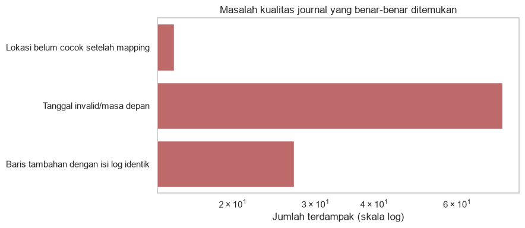

|  | Layer | Tabel/view | Kolom | Tipe data |
| --- | --- | --- | --- | --- |
| 0 | analytics | item_journey_clean | created_on | timestamp without time zone |
| 1 | journal | t_item_journey | created_on | timestamp without time zone |

|  | journey_id yang perlu dibandingkan | Model | Status | Aktivitas | Waktu | Lokasi mentah | Jumlah baris |
| --- | --- | --- | --- | --- | --- | --- | --- |
| 0 | {144477,153192,153193} | 0110403 | DISMANTLED | RECON | 2023-03-05 09:00:00 | STASIUN TEBET | 3 |
| 1 | {144479,153194,153195} | 0110403 | DISMANTLED | RECON | 2023-03-05 09:00:00 | STASIUN TEBET | 3 |
| 2 | {144416,153188,153189} | 0110402 | DISMANTLED | RECON | 2023-03-05 09:00:00 | STASIUN TEBET | 3 |
| 3 | {144417,153190,153191} | 0110402 | DISMANTLED | RECON | 2023-03-05 09:00:00 | STASIUN TEBET | 3 |
| 4 | {126356,126357} | 0120201 | REPAIRED | REPARATION | 2019-01-13 09:00:00 | GUDANG NI | 2 |
| 5 | {122511,122512} | 0120201 | RETURNED | RETURN | 2019-01-15 14:00:00 | GUDANG NI | 2 |
| 6 | {126746,126747} | 0121602 | REPAIRED | REPARATION | 2019-07-16 09:00:00 | GUDANG NI | 2 |
| 7 | {122901,122902} | 0121602 | RETURNED | RETURN | 2019-07-18 14:00:00 | GUDANG NI | 2 |
| 8 | {127256,127257} | 0121701 | REPAIRED | REPARATION | 2020-02-24 09:00:00 | GUDANG NI | 2 |
| 9 | {123411,123412} | 0121701 | RETURNED | RETURN | 2020-02-26 14:00:00 | GUDANG NI | 2 |
| 10 | {144543,153196} | 0110404 | DISMANTLED | RECON | 2023-03-05 09:00:00 | STASIUN JAKARTA KOTA | 2 |
| 11 | {145959,145960} | 0220601 | DISMANTLED | RECON | 2023-03-05 09:00:00 | STASIUN SUDIRMAN | 2 |
| 12 | {144790,144791} | 0120202 | DISMANTLED | RECON | 2023-03-05 09:00:00 | STASIUN PONDOK RANJI | 2 |
| 13 | {145208,153211} | 0120701 | DISMANTLED | RECON | 2023-03-05 09:00:00 | STASIUN TEBET | 2 |
| 14 | {144843,153202} | 0120202 | DISMANTLED | RECON | 2023-03-05 09:00:00 | STASIUN TEBET | 2 |
| 15 | {145484,153219} | 0121401 | DISMANTLED | RECON | 2023-03-05 09:00:00 | STASIUN TEBET | 2 |
| 16 | {144622,153198} | 0120201 | DISMANTLED | RECON | 2023-03-05 09:00:00 | STASIUN TEBET | 2 |
| 17 | {146416,153242} | 0420504 | DISMANTLED | RECON | 2023-03-05 09:00:00 | STASIUN TEBET | 2 |
| 18 | {145586,153221} | 0121401 | DISMANTLED | RECON | 2023-03-05 09:00:00 | STASIUN TEBET | 2 |
| 19 | {145609,153222} | 0121401 | DISMANTLED | RECON | 2023-03-05 09:00:00 | STASIUN TEBET | 2 |

|  | Jenis | Nilai sumber | Nilai canonical | Kandidat terbaik | Keputusan | Kemiripan (%) | Selisih kandidat (%) | Event | Item |
| --- | --- | --- | --- | --- | --- | --- | --- | --- | --- |
| 0 | CLIENT | KERETE COMMUTER INDONESIA (KCI) | KERETA COMMUTER INDONESIA (KCI) | KERETA COMMUTER INDONESIA (KCI) | FUZZY_AUTO_ACCEPTED | 96.55 | 75.86 | 58645 | 11729 |
| 1 | LOCATION | GUDANG NUTECH | GUDANG NI | GUDANG NI | VERIFIED_CONTEXT_ALIAS | 61.54 | NaN | 8567 | 5611 |
| 2 | LOCATION | NOC JUANDA | None | IT KCI JUANDA | FUZZY_REVIEW | 61.54 | 11.54 | 15 | 9 |

**Temuan utama:** ada **3 jenis pemeriksaan** dengan dampak non-zero. Exact duplicate tidak dihapus otomatis dan mapping ambigu tetap masuk review.

**Tindak lanjut:** hanya record dengan aturan exclusion eksplisit yang dikeluarkan; record review tetap disimpan untuk audit.

```python
journal_quality = query('SELECT * FROM analytics.eda_journey_quality_summary ORDER BY check_order')
quality_labels = {'MISSING_ITEM_IDENTIFIER': 'Identifier item kosong', 'MISSING_ITEM_MODEL': 'Model item kosong', 'MISSING_ITEM_TYPE': 'Tipe item kosong', 'MISSING_ITEM_CATEGORY': 'Kategori item kosong', 'MISSING_CLIENT': 'Klien kosong', 'MISSING_LOCATION': 'Lokasi mentah kosong', 'LOCATION_NOT_IN_MASTER': 'Lokasi belum cocok setelah mapping', 'CLIENT_NOT_IN_MASTER': 'Klien belum cocok setelah mapping', 'MISSING_STATUS': 'Status kosong', 'MISSING_DATE': 'Tanggal kosong', 'INVALID_OR_FUTURE_DATE': 'Tanggal invalid/masa depan', 'DUPLICATE_JOURNEY_ID': 'journey_id duplikat', 'EXACT_LOG_DUPLICATE_EXTRA_ROWS': 'Baris tambahan dengan isi log identik', 'CREATED_ON_NOT_DATETIME': 'created_on bukan datetime'}
journal_quality['affected_count'] = pd.to_numeric(journal_quality['affected_count'], errors='coerce').fillna(0).astype(int)
journal_quality_display = journal_quality.assign(check_name=journal_quality['check_name'].replace(quality_labels)).rename(columns={'check_name': 'Pemeriksaan', 'affected_count': 'Jumlah terdampak', 'explanation': 'Arti'})
display(journal_quality_display[['Pemeriksaan', 'Jumlah terdampak', 'Arti']])
quality_nonzero = journal_quality_display[journal_quality_display['Jumlah terdampak'].gt(0)]
if not quality_nonzero.empty:
    plt.figure(figsize=(9, 4)); sns.barplot(data=quality_nonzero, y='Pemeriksaan', x='Jumlah terdampak', color='indianred'); plt.xscale('log'); plt.title('Masalah kualitas journal yang benar-benar ditemukan'); plt.xlabel('Jumlah terdampak (skala log)'); plt.ylabel(''); plt.tight_layout(); plt.show()
date_types = query("""SELECT table_schema, table_name, column_name, data_type FROM information_schema.columns WHERE (table_schema, table_name, column_name) IN (('journal','t_item_journey','created_on'), ('analytics','item_journey_clean','created_on')) ORDER BY table_schema""")
display(date_types.rename(columns={'table_schema': 'Layer', 'table_name': 'Tabel/view', 'column_name': 'Kolom', 'data_type': 'Tipe data'}))
duplicate_groups = query("""SELECT ARRAY_AGG(journey_id ORDER BY journey_id)::text journey_ids, item_model_code_clean, status_clean, activity_clean, created_on, place_clean, COUNT(*) row_count FROM analytics.item_journey_clean GROUP BY item_identifier_clean, created_on, item_category_clean, item_type_clean, item_model_code_clean, client_clean, ref_doc_code_clean, wo_type_clean, wo_code_clean, place_clean, activity_clean, status_clean, done_by_clean, remark HAVING COUNT(*) > 1 ORDER BY row_count DESC, created_on LIMIT 20""")
display(duplicate_groups.rename(columns={'journey_ids': 'journey_id yang perlu dibandingkan', 'item_model_code_clean': 'Model', 'status_clean': 'Status', 'activity_clean': 'Aktivitas', 'created_on': 'Waktu', 'place_clean': 'Lokasi mentah', 'row_count': 'Jumlah baris'}))
fuzzy_mapping = query('SELECT * FROM analytics.eda_fuzzy_mapping_review ORDER BY mapping_type, event_count DESC')
fuzzy_mapping['similarity_percentage'] = (pd.to_numeric(fuzzy_mapping.similarity_score, errors='coerce') * 100).round(2); fuzzy_mapping['margin_percentage'] = (pd.to_numeric(fuzzy_mapping.score_margin, errors='coerce') * 100).round(2)
display(fuzzy_mapping.rename(columns={'mapping_type': 'Jenis', 'source_value': 'Nilai sumber', 'canonical_value': 'Nilai canonical', 'best_candidate': 'Kandidat terbaik', 'mapping_method': 'Keputusan', 'similarity_percentage': 'Kemiripan (%)', 'margin_percentage': 'Selisih kandidat (%)', 'event_count': 'Event', 'item_count': 'Item'})[['Jenis','Nilai sumber','Nilai canonical','Kandidat terbaik','Keputusan','Kemiripan (%)','Selisih kandidat (%)','Event','Item']])
display(Markdown(f"""**Temuan utama:** ada **{len(quality_nonzero)} jenis pemeriksaan** dengan dampak non-zero. Exact duplicate tidak dihapus otomatis dan mapping ambigu tetap masuk review.

**Tindak lanjut:** hanya record dengan aturan exclusion eksplisit yang dikeluarkan; record review tetap disimpan untuk audit."""))
```

### 4.3 Coverage master dan missing data

**Metrik:** unmatched snapshot, kategori langka, dan missing rate. Missing struktural seperti “belum pernah failure” tidak dianggap kesalahan input dan tidak boleh diisi nol tanpa indikator.

|  | Fitur master | Snapshot training | Berhasil dipetakan | Belum dipetakan | Jumlah kategori | Kategori langka (<100 snapshot) | Snapshot pada kategori langka | Unmatched (%) | Kategori langka (%) | Keputusan |
| --- | --- | --- | --- | --- | --- | --- | --- | --- | --- | --- |
| 0 | CLIENT | 1324145 | 1324145 | 0 | 4 | 0 | 0 | 0.0000 | 0.0000 | COVERAGE_SAFE_KEEP_UNKNOWN_FALLBACK |
| 1 | LOCATION | 1324145 | 1323971 | 174 | 153 | 5 | 345 | 0.0131 | 0.0261 | COVERAGE_SAFE_KEEP_UNKNOWN_FALLBACK |

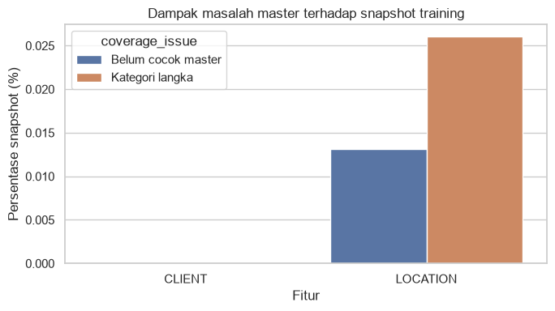

Lokasi belum cocok master hanya memengaruhi **174 dari 1.324.145 snapshot (0.0131%)**. Secara coverage. lokasi aman diuji sebagai prediktor. tetapi tetap gunakan kategori `UNKNOWN`. missing flag. minimum support. dan bandingkan model dengan-versus-tanpa lokasi.

|  | Informasi | Jumlah kosong | Persentase kosong | Jumlah tersedia | Strategi sebelum modeling |
| --- | --- | --- | --- | --- | --- |
| 0 | Hari sejak kerusakan terakhir | 1250548 | 94.4419 | 73597 | Bukan error: belum pernah failure; gunakan ind... |
| 1 | Hari sejak corrective terakhir | 1164588 | 87.9502 | 159557 | Bukan error: belum pernah corrective; gunakan ... |
| 2 | Lokasi terakhir | 174 | 0.0131 | 1323971 | UNKNOWN + penanda; bandingkan model tanpa lokasi |
| 3 | Model PART | 0 | 0.0000 | 1324145 | Keluarkan bila identitas inti kosong |
| 4 | Hari sejak kegiatan terakhir | 0 | 0.0000 | 1324145 | Median per model + penanda kosong |
| 5 | Client pemasangan | 0 | 0.0000 | 1324145 | Gunakan kategori UNKNOWN dan penanda kosong |
| 6 | Hari sejak pemasangan | 0 | 0.0000 | 1324145 | Keluarkan bila awal cycle tidak diketahui |
| 7 | Lama di lokasi terakhir | 0 | 0.0000 | 1324145 | Penanda kosong; bandingkan tanpa umur lokasi |

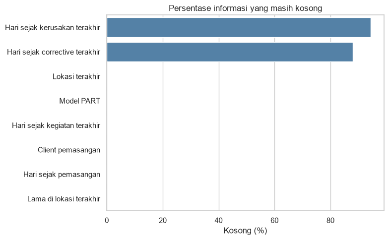

```python
master_coverage = query('SELECT * FROM analytics.eda_snapshot_master_coverage ORDER BY feature_name')
for col in ['total_snapshot','matched_snapshot','unmatched_snapshot','category_count','rare_category_count','rare_snapshot_count','unmatched_percentage','rare_snapshot_percentage']: master_coverage[col] = pd.to_numeric(master_coverage[col], errors='coerce')
coverage_display = master_coverage.rename(columns={'feature_name': 'Fitur master', 'total_snapshot': 'Snapshot training', 'matched_snapshot': 'Berhasil dipetakan', 'unmatched_snapshot': 'Belum dipetakan', 'category_count': 'Jumlah kategori', 'rare_category_count': 'Kategori langka (<100 snapshot)', 'rare_snapshot_count': 'Snapshot pada kategori langka', 'unmatched_percentage': 'Unmatched (%)', 'rare_snapshot_percentage': 'Kategori langka (%)', 'feature_decision': 'Keputusan'})
display(coverage_display)
coverage_plot = master_coverage.melt(id_vars='feature_name', value_vars=['unmatched_percentage','rare_snapshot_percentage'], var_name='coverage_issue', value_name='percentage')
coverage_plot['coverage_issue'] = coverage_plot.coverage_issue.map({'unmatched_percentage':'Belum cocok master','rare_snapshot_percentage':'Kategori langka'})
plt.figure(figsize=(7, 4)); sns.barplot(data=coverage_plot, x='feature_name', y='percentage', hue='coverage_issue').set(title='Dampak masalah master terhadap snapshot training', xlabel='Fitur', ylabel='Persentase snapshot (%)'); plt.tight_layout(); plt.show()
location_coverage = master_coverage.loc[master_coverage.feature_name.eq('LOCATION')].iloc[0]
display(Markdown(f"Lokasi belum cocok master hanya memengaruhi **{int(location_coverage.unmatched_snapshot):,} dari {int(location_coverage.total_snapshot):,} snapshot ({float(location_coverage.unmatched_percentage):.4f}%)**. Secara coverage, lokasi aman diuji sebagai prediktor, tetapi tetap gunakan kategori `UNKNOWN`, missing flag, minimum support, dan bandingkan model dengan-versus-tanpa lokasi.".replace(',', '.')))
missing = query('SELECT * FROM analytics.eda_feature_missingness ORDER BY missing_percentage DESC')
feature_labels = {'item_model_code_clean': 'Model PART', 'installed_client_clean': 'Client pemasangan', 'last_place_clean': 'Lokasi terakhir', 'days_since_installation': 'Hari sejak pemasangan', 'days_since_last_event': 'Hari sejak kegiatan terakhir', 'days_since_last_failure': 'Hari sejak kerusakan terakhir', 'days_since_last_corrective': 'Hari sejak corrective terakhir', 'days_at_last_location': 'Lama di lokasi terakhir'}
handling_labels = {'EXCLUDE_ROW_IF_MISSING_CORE_IDENTITY':'Keluarkan bila identitas inti kosong', 'UNKNOWN_CATEGORY_PLUS_MISSING_FLAG':'Gunakan kategori UNKNOWN dan penanda kosong', 'UNKNOWN_CATEGORY_PLUS_FLAG_COMPARE_WITHOUT_LOCATION':'UNKNOWN + penanda; bandingkan model tanpa lokasi', 'EXCLUDE_IF_MISSING_CYCLE_START':'Keluarkan bila awal cycle tidak diketahui', 'MEDIAN_BY_MODEL_PLUS_MISSING_FLAG':'Median per model + penanda kosong', 'STRUCTURAL_NO_PRIOR_FAILURE_USE_INDICATOR_AND_SENTINEL':'Bukan error: belum pernah failure; gunakan indikator + sentinel', 'STRUCTURAL_NO_PRIOR_CORRECTIVE_USE_INDICATOR_AND_SENTINEL':'Bukan error: belum pernah corrective; gunakan indikator + sentinel', 'MISSING_FLAG_AND_COMPARE_MODEL_WITHOUT_LOCATION_AGE':'Penanda kosong; bandingkan tanpa umur lokasi'}
missing['missing_percentage'] = pd.to_numeric(missing.missing_percentage, errors='coerce')
missing_display = missing.assign(feature_name=missing['feature_name'].replace(feature_labels), recommended_handling=missing['recommended_handling'].replace(handling_labels)).rename(columns={'feature_name': 'Informasi', 'missing_count': 'Jumlah kosong', 'missing_percentage': 'Persentase kosong', 'available_count': 'Jumlah tersedia', 'recommended_handling': 'Strategi sebelum modeling'})
display(missing_display[['Informasi','Jumlah kosong','Persentase kosong','Jumlah tersedia','Strategi sebelum modeling']])
plt.figure(figsize=(8, 5)); sns.barplot(data=missing_display, y='Informasi', x='Persentase kosong', color='steelblue').set(title='Persentase informasi yang masih kosong', xlabel='Kosong (%)', ylabel=''); plt.tight_layout(); plt.show()
```

### 4.4 Outlier dan daftar manual review

Outlier adalah tanda pemeriksaan, bukan alasan menghapus otomatis. Setiap temuan dibaca bersama dampak dan konteks proses bisnisnya.

```python
outliers = query('SELECT * FROM analytics.eda_outlier_summary ORDER BY affected_count DESC')
outlier_labels = {'OPERATIONAL_GAP_GT_10Y': 'Jarak kegiatan lebih dari 10 tahun', 'ZERO_OR_NEGATIVE_DURATION_CYCLE': 'Cycle tanpa durasi positif', 'FAILURE_NOT_PRECEDED_BY_INSTALLED': 'Failure tidak langsung didahului INSTALLED', 'ITEM_WITH_5_PLUS_FAILURES': 'PART dengan minimal 5 failure', 'JOURNEY_MODEL_INCONSISTENT': 'Model journey tidak konsisten', 'INVALID_OR_FUTURE_JOURNEY_DATE': 'Tanggal journey invalid/masa depan', 'SNAPSHOT_WITHOUT_MASTER_LOCATION': 'Snapshot tanpa lokasi master'}
outliers_display = outliers.assign(check_name=outliers['check_name'].replace(outlier_labels)).rename(columns={'check_name': 'Yang perlu diperiksa', 'affected_count': 'Jumlah terdampak', 'explanation': 'Alasan'})
display(outliers_display)
display(Markdown("""**Interpretasi:** jumlah besar belum otomatis menunjukkan error; gap lama, failure tanpa previous INSTALLED, dan item berulang perlu sampling berbasis kasus.

**Keputusan:** pertahankan untuk audit, lalu keluarkan hanya melalui quality rule yang sudah disetujui."""))
```

|  | Yang perlu diperiksa | Jumlah terdampak | Alasan |
| --- | --- | --- | --- |
| 0 | RIGHT_CENSORED_ACTIVITY_COVERAGE_UNCONFIRMED | 16754 | Cycle masih terbuka, tetapi PART sudah lama ti... |
| 1 | Failure tidak langsung didahului INSTALLED | 1263 | Status operasional tepat sebelum failure bukan... |
| 2 | REINSTALL_WITHOUT_RECORDED_FAILURE | 1185 | Cycle berakhir dengan reinstall tetapi tidak m... |
| 3 | Model journey tidak konsisten | 732 | Journey menggunakan model yang tidak konsisten... |
| 4 | Jarak kegiatan lebih dari 10 tahun | 322 | Jarak dari event operasional sebelumnya lebih ... |
| 5 | PART dengan minimal 5 failure | 186 | Jumlah PART yang memiliki sedikitnya lima failure |
| 6 | Snapshot tanpa lokasi master | 174 | Snapshot training tidak mempunyai lokasi canon... |
| 7 | Tanggal journey invalid/masa depan | 75 | Journey mempunyai tanggal invalid atau berada ... |
| 8 | Cycle tanpa durasi positif | 4 | Cycle tidak mempunyai durasi waktu positif |

**Interpretasi:** jumlah besar belum otomatis menunjukkan error; gap lama, failure tanpa previous INSTALLED, dan item berulang perlu sampling berbasis kasus.

**Keputusan:** pertahankan untuk audit, lalu keluarkan hanya melalui quality rule yang sudah disetujui.

```python
cycle_quality = query("""SELECT cycle_quality_status, COUNT(*) cycle_count FROM analytics.item_installation_cycle GROUP BY 1 ORDER BY 2 DESC""")
snapshot_quality = query("""SELECT target_quality_status, COUNT(*) snapshot_count FROM analytics.item_observation_30d GROUP BY 1 ORDER BY 2 DESC""")
display(cycle_quality.rename(columns={'cycle_quality_status':'Kualitas cycle','cycle_count':'Jumlah cycle'}))
display(snapshot_quality.rename(columns={'target_quality_status':'Keputusan label snapshot','snapshot_count':'Jumlah snapshot'}))
unknown_reinstall_count = int(cycle_quality.loc[cycle_quality.cycle_quality_status.eq('UNKNOWN_REINSTALL_WITHOUT_RECORDED_FAILURE'),'cycle_count'].sum())
coverage_unconfirmed_count = int(cycle_quality.loc[cycle_quality.cycle_quality_status.eq('RIGHT_CENSORED_ACTIVITY_COVERAGE_UNCONFIRMED'),'cycle_count'].sum())
display(Markdown(f"""**Temuan utama:** **{unknown_reinstall_count:,} cycle reinstall** tidak lagi otomatis menjadi negatif. **{coverage_unconfirmed_count:,} cycle right-censored** memiliki coverage aktivitas yang belum terkonfirmasi dan disediakan sebagai sensitivity flag.

**Keputusan:** failure positif tidak diubah; label negatif dibuat lebih konservatif dan dapat diaudit.""".replace(',', '.')))
```

|  | Kualitas cycle | Jumlah cycle |
| --- | --- | --- |
| 0 | RIGHT_CENSORED_ACTIVITY_COVERAGE_UNCONFIRMED | 16754 |
| 1 | RELIABLE_OBSERVED_FAILURE | 5894 |
| 2 | UNKNOWN_REINSTALL_WITHOUT_RECORDED_FAILURE | 1185 |
| 3 | RIGHT_CENSORED_RECENT_ACTIVITY | 212 |

|  | Keputusan label snapshot | Jumlah snapshot |
| --- | --- | --- |
| 0 | NEGATIVE_FULL_30D_FOLLOWUP | 1318269 |
| 1 | EXCLUDED_UNKNOWN_REINSTALL_WITHOUT_FAILURE | 65064 |
| 2 | EXCLUDED_INCOMPLETE_30D_FOLLOWUP | 16877 |
| 3 | POSITIVE_FAILURE_WITHIN_30D | 5876 |

**Temuan utama:** **1.185 cycle reinstall** tidak lagi otomatis menjadi negatif. **16.754 cycle right-censored** memiliki coverage aktivitas yang belum terkonfirmasi dan disediakan sebagai sensitivity flag.

**Keputusan:** failure positif tidak diubah; label negatif dibuat lebih konservatif dan dapat diaudit.

## 5. Analisis deskriptif dasar

**Pertanyaan:** secara umum seperti apa bentuk aktivitas item dan lokasi? Bagian ini melihat model/lokasi paling aktif, kelompok dengan data sangat sedikit, status, semantic, dan pola hari kerja sebelum membahas risiko failure.

### 5.1 Distribusi item, model, lokasi, dan hari aktivitas

Jumlah event menunjukkan aktivitas, bukan risiko. Model/lokasi dengan data kecil ditandai agar persentase ekstrem tidak langsung dipercaya.

|  | Kategori | Model | Event | Unit | Installed | Dismantled | Failure | Pertama | Terakhir |
| --- | --- | --- | --- | --- | --- | --- | --- | --- | --- |
| 0 | PART | 0120201 | 17962 | 3419 | 3183 | 683 | 581 | 2012-12-28 | 2026-08-03 |
| 1 | PART | 0521201 | 10489 | 1030 | 1729 | 837 | 822 | 2012-12-28 | 2026-08-03 |
| 2 | PART | 0720301 | 10221 | 2043 | 1922 | 196 | 154 | 2019-04-05 | 2026-07-29 |
| 3 | PART | 0121101 | 8608 | 1174 | 1473 | 579 | 560 | 2012-12-28 | 2026-08-03 |
| 4 | PART | 0120204 | 8100 | 1005 | 1245 | 364 | 351 | 2020-05-22 | 2026-08-01 |
| 5 | PART | 0120401 | 7645 | 395 | 1029 | 862 | 841 | 2016-01-01 | 2026-07-13 |
| 6 | PART | 0121103 | 5722 | 1045 | 1089 | 126 | 106 | 2012-12-28 | 2026-07-02 |
| 7 | PART | 0620302 | 5693 | 1090 | 1077 | 115 | 78 | 2019-03-09 | 2026-07-29 |
| 8 | TERMINAL | 0110501 | 5527 | 1062 | 1091 | 41 | 1 | 2012-12-28 | 2026-07-02 |
| 9 | PART | 0121602 | 4976 | 212 | 682 | 572 | 562 | 2017-08-06 | 2026-07-31 |
| 10 | PART | 0620505 | 4721 | 691 | 701 | 267 | 196 | 2015-11-21 | 2026-08-02 |
| 11 | PART | 0321501 | 4643 | 923 | 913 | 32 | 11 | 2012-12-28 | 2026-07-02 |
| 12 | PART | 0420502 | 4076 | 616 | 672 | 320 | 305 | 2012-12-28 | 2026-08-03 |
| 13 | PART | 0521202 | 3488 | 669 | 374 | 227 | 214 | 2023-03-09 | 2026-08-03 |
| 14 | PART | 0321302 | 3082 | 1000 | 490 | 31 | 12 | 2019-11-16 | 2026-07-29 |

Ada **10** model dengan maksimal lima event atau hanya satu unit. Kelompok kecil ini tidak aman dibandingkan berdasarkan persentase tanpa batas minimum sampel.

|  | Kategori | Model jarang | Event | Unit | Pertama | Terakhir |
| --- | --- | --- | --- | --- | --- | --- |
| 136 | TERMINAL | 1611103 | 3 | 3 | 2024-06-17 | 2024-06-17 |
| 135 | PART | 0921611 | 4 | 4 | 2025-06-09 | 2025-06-09 |
| 127 | TERMINAL | 1010811 | 5 | 1 | 2020-01-01 | 2025-05-12 |
| 128 | TERMINAL | 1011203 | 5 | 1 | 2020-01-01 | 2025-05-12 |
| 129 | TERMINAL | 1010806 | 5 | 1 | 2020-01-01 | 2025-05-12 |
| 130 | TERMINAL | 1011205 | 5 | 1 | 2020-05-22 | 2025-05-04 |
| 131 | TERMINAL | 1011206 | 5 | 1 | 2020-05-22 | 2025-05-04 |
| 132 | PART | 1020516 | 5 | 1 | 2020-05-22 | 2025-05-04 |
| 133 | TERMINAL | 1011201 | 5 | 1 | 2020-01-01 | 2025-05-12 |
| 134 | PART | 1020608 | 5 | 1 | 2020-01-01 | 2025-05-12 |
| 126 | PART | 1020515 | 6 | 2 | 2019-05-20 | 2025-05-14 |
| 125 | PART | 0820305 | 6 | 6 | 2024-06-17 | 2024-06-17 |
| 124 | PART | 1021407 | 9 | 5 | 2020-05-22 | 2025-05-04 |
| 120 | PART | 1020511 | 10 | 2 | 2020-01-01 | 2025-05-12 |
| 121 | TERMINAL | 1011202 | 10 | 2 | 2020-01-01 | 2025-05-12 |

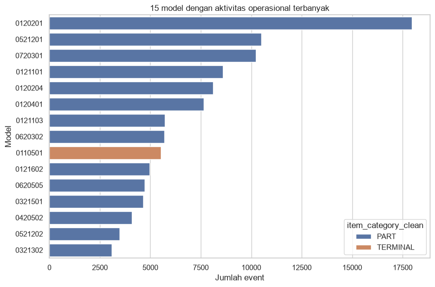

|  | Lokasi | Event | Unit | Model | Installed | Dismantled | Failure | Pertama | Terakhir |
| --- | --- | --- | --- | --- | --- | --- | --- | --- | --- |
| 0 | GUDANG NI | 57448 | 17258 | 136 | 0 | 56 | 56 | 2012-12-29 | 2026-08-03 |
| 1 | SERVICE CENTER | 4424 | 793 | 42 | 0 | 0 | 0 | 2025-04-21 | 2026-08-03 |
| 2 | STASIUN BOGOR | 4317 | 1030 | 51 | 1060 | 403 | 394 | 2012-12-28 | 2026-07-30 |
| 3 | STASIUN TANAH ABANG | 3635 | 1227 | 40 | 1226 | 237 | 152 | 2012-12-28 | 2026-07-02 |
| 4 | STASIUN JAKARTA KOTA | 3390 | 798 | 50 | 813 | 301 | 264 | 2013-05-28 | 2026-07-02 |
| 5 | STASIUN TEBET | 2545 | 612 | 42 | 601 | 266 | 236 | 2012-12-28 | 2026-07-16 |
| 6 | STASIUN JUANDA | 2281 | 546 | 46 | 529 | 183 | 160 | 2012-12-28 | 2026-07-27 |
| 7 | STASIUN CITAYAM | 2084 | 503 | 48 | 503 | 233 | 204 | 2012-12-28 | 2026-07-30 |
| 8 | STASIUN SUDIRMAN | 1975 | 461 | 48 | 464 | 169 | 160 | 2012-12-28 | 2026-07-28 |
| 9 | STASIUN PONDOK CINA | 1933 | 479 | 48 | 469 | 152 | 149 | 2012-12-28 | 2026-07-29 |
| 10 | STASIUN TANGERANG | 1830 | 442 | 41 | 451 | 186 | 182 | 2013-05-28 | 2026-07-25 |
| 11 | STASIUN MANGGARAI | 1625 | 405 | 45 | 393 | 147 | 138 | 2012-12-28 | 2026-07-31 |
| 12 | STASIUN KEBAYORAN | 1577 | 392 | 44 | 391 | 168 | 160 | 2012-12-28 | 2026-07-15 |
| 13 | STASIUN CAWANG | 1575 | 480 | 55 | 485 | 92 | 90 | 2012-12-28 | 2026-07-29 |
| 14 | STASIUN DEPOK | 1557 | 373 | 37 | 386 | 172 | 172 | 2012-12-28 | 2026-07-22 |

|  | Lokasi dengan aktivitas rendah | Event | Unit | Model | Pertama | Terakhir |
| --- | --- | --- | --- | --- | --- | --- |
| 153 | GEDUNG OCC | 12 | 6 | 4 | 2023-08-21 | 2023-08-28 |
| 152 | RAWABUAYA (KA BANDARA) | 14 | 7 | 6 | 2025-05-13 | 2025-05-14 |
| 151 | STASIUN BATANG KUIS | 28 | 14 | 13 | 2025-05-11 | 2025-05-12 |
| 150 | STASIUN BANDARKHALIPAH | 30 | 15 | 13 | 2025-05-11 | 2025-05-12 |
| 149 | STASIUN ARASKABU | 32 | 16 | 14 | 2025-05-11 | 2025-05-12 |
| 148 | STASIUN TANTAH TINGGI | 35 | 7 | 6 | 2014-08-04 | 2014-08-08 |
| 146 | SRASIUN RAWA BUAYA | 40 | 8 | 8 | 2017-08-06 | 2017-08-10 |
| 147 | STASIUN KELENDER BARU | 40 | 8 | 8 | 2017-08-06 | 2017-08-10 |
| 145 | STASIUN MAGUWO | 48 | 22 | 13 | 2019-03-15 | 2026-07-13 |
| 144 | STASIUN SOLOBALAPAN | 50 | 10 | 8 | 2023-11-17 | 2023-11-22 |
| 143 | STASIUN GAWOK | 51 | 24 | 13 | 2019-03-15 | 2026-05-08 |
| 142 | STASIUN MANGGABESAR | 70 | 14 | 7 | 2017-08-06 | 2017-08-10 |
| 140 | STASIUN DELANGGU | 81 | 27 | 16 | 2012-12-28 | 2026-02-18 |
| 141 | STASIUN PONDOK RAJEG | 81 | 33 | 15 | 2019-03-15 | 2026-07-31 |
| 139 | STASIUN CEPER | 84 | 29 | 19 | 2012-12-28 | 2026-01-14 |

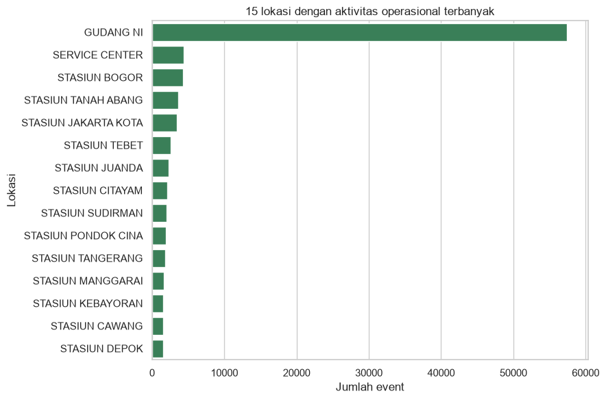

**Temuan utama:** terdapat **137 kombinasi kategori-model** dan **154 lokasi canonical** pada event operasional.

**Interpretasi:** volume aktivitas tidak sama dengan failure rate. Analisis risiko berikutnya selalu memakai penyebut snapshot dan minimum support.

```python
item_activity = query('SELECT * FROM analytics.eda_item_activity_summary ORDER BY event_count DESC')
for col in ['event_count', 'item_count', 'installation_count', 'dismantle_count', 'failure_count']: item_activity[col] = pd.to_numeric(item_activity[col], errors='coerce')
top_items = item_activity.head(15)
rare_items = item_activity.sort_values(['event_count', 'item_count']).head(15)
display(top_items.rename(columns={'item_category_clean': 'Kategori', 'item_model_code_clean': 'Model', 'event_count': 'Event', 'item_count': 'Unit', 'installation_count': 'Installed', 'dismantle_count': 'Dismantled', 'failure_count': 'Failure', 'first_activity_date': 'Pertama', 'last_activity_date': 'Terakhir'}))
display(Markdown(f"Ada **{int(((item_activity.event_count <= 5) | (item_activity.item_count <= 1)).sum())}** model dengan maksimal lima event atau hanya satu unit. Kelompok kecil ini tidak aman dibandingkan berdasarkan persentase tanpa batas minimum sampel."))
display(rare_items[['item_category_clean','item_model_code_clean','event_count','item_count','first_activity_date','last_activity_date']].rename(columns={'item_category_clean': 'Kategori', 'item_model_code_clean': 'Model jarang', 'event_count': 'Event', 'item_count': 'Unit', 'first_activity_date': 'Pertama', 'last_activity_date': 'Terakhir'}))
plt.figure(figsize=(9, 6)); sns.barplot(data=top_items, y='item_model_code_clean', x='event_count', hue='item_category_clean', dodge=False); plt.title('15 model dengan aktivitas operasional terbanyak'); plt.xlabel('Jumlah event'); plt.ylabel('Model'); plt.tight_layout(); plt.show()
location_activity = query('SELECT * FROM analytics.eda_location_activity_summary ORDER BY event_count DESC')
for col in ['event_count', 'item_count', 'model_count', 'installation_count', 'dismantle_count', 'failure_count']: location_activity[col] = pd.to_numeric(location_activity[col], errors='coerce')
top_locations = location_activity.head(15); rare_locations = location_activity.sort_values('event_count').head(15)
display(top_locations.rename(columns={'place_canonical_clean': 'Lokasi', 'event_count': 'Event', 'item_count': 'Unit', 'model_count': 'Model', 'installation_count': 'Installed', 'dismantle_count': 'Dismantled', 'failure_count': 'Failure', 'first_activity_date': 'Pertama', 'last_activity_date': 'Terakhir'}))
display(rare_locations[['place_canonical_clean','event_count','item_count','model_count','first_activity_date','last_activity_date']].rename(columns={'place_canonical_clean': 'Lokasi dengan aktivitas rendah', 'event_count': 'Event', 'item_count': 'Unit', 'model_count': 'Model', 'first_activity_date': 'Pertama', 'last_activity_date': 'Terakhir'}))
plt.figure(figsize=(9, 6)); sns.barplot(data=top_locations, y='place_canonical_clean', x='event_count', color='seagreen'); plt.title('15 lokasi dengan aktivitas operasional terbanyak'); plt.xlabel('Jumlah event'); plt.ylabel('Lokasi'); plt.tight_layout(); plt.show()

display(Markdown(f"""**Temuan utama:** terdapat **{len(item_activity)} kombinasi kategori-model** dan **{len(location_activity)} lokasi canonical** pada event operasional.

**Interpretasi:** volume aktivitas tidak sama dengan failure rate. Analisis risiko berikutnya selalu memakai penyebut snapshot dan minimum support."""))
```

## 6. Tren operasional dan failure

**Pertanyaan:** bagaimana event, installation, dismantle, failure, dan positive rate berubah menurut waktu? Perubahan pada 2025 harus dibaca bersama perubahan detail pencatatan repair, sehingga tren belum otomatis berarti kondisi perangkat memburuk.

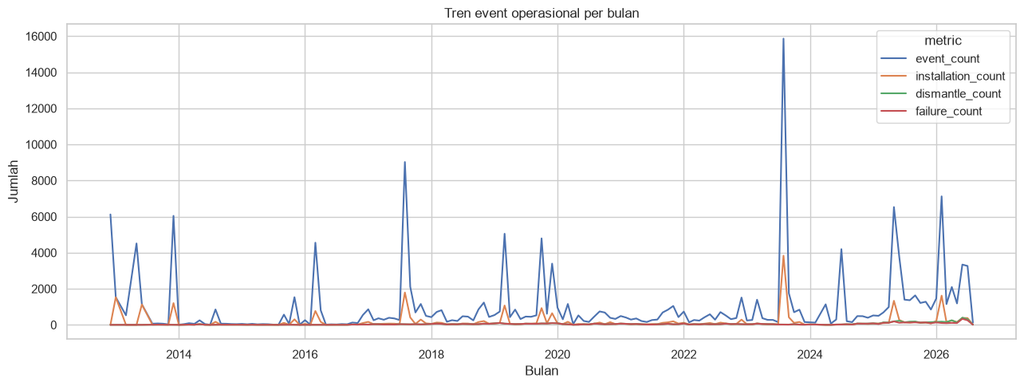

|  | Tahun | Snapshot | Positif | Positive rate (%) |
| --- | --- | --- | --- | --- |
| 0 | 2013 | 23599 | 34 | 0.1441 |
| 1 | 2014 | 37019 | 104 | 0.2809 |
| 2 | 2015 | 38901 | 50 | 0.1285 |
| 3 | 2016 | 49757 | 86 | 0.1728 |
| 4 | 2017 | 64048 | 341 | 0.5324 |
| 5 | 2018 | 82652 | 546 | 0.6606 |
| 6 | 2019 | 97511 | 827 | 0.8481 |
| 7 | 2020 | 111325 | 459 | 0.4123 |
| 8 | 2021 | 114976 | 445 | 0.3870 |
| 9 | 2022 | 118776 | 458 | 0.3856 |
| 10 | 2023 | 140134 | 349 | 0.2490 |
| 11 | 2024 | 168419 | 221 | 0.1312 |
| 12 | 2025 | 177433 | 1054 | 0.5940 |
| 13 | 2026 | 99595 | 902 | 0.9057 |

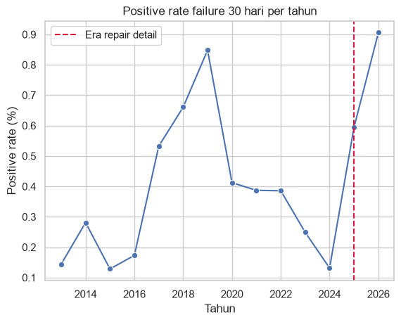

**Temuan utama:** positive rate berubah dari **0.1312% (2024)** menjadi **0.5940% (2025)** dan **0.9057% (2026 parsial)**.

**Interpretasi:** perubahan ini bercampur dengan perubahan pencatatan sejak 2025.

**Keputusan:** validation dan test wajib dipisahkan berdasarkan waktu/era.

```python
monthly_trend = query("""SELECT activity_month, SUM(event_count) event_count, SUM(installation_count) installation_count, SUM(dismantle_count) dismantle_count, SUM(failure_count) failure_count FROM analytics.eda_activity_calendar_summary GROUP BY activity_month ORDER BY activity_month""")
monthly_trend['activity_month'] = pd.to_datetime(monthly_trend.activity_month)
trend_columns = ['event_count','installation_count','dismantle_count','failure_count']
monthly_trend[trend_columns] = monthly_trend[trend_columns].apply(pd.to_numeric)
monthly_trend_long = monthly_trend.melt(id_vars='activity_month', value_vars=trend_columns, var_name='metric', value_name='count')
plt.figure(figsize=(13,5)); sns.lineplot(data=monthly_trend_long, x='activity_month', y='count', hue='metric'); plt.title('Tren event operasional per bulan'); plt.xlabel('Bulan'); plt.ylabel('Jumlah'); plt.tight_layout(); plt.show()
yearly = query('SELECT * FROM analytics.eda_failure_rate_by_year ORDER BY observation_year')
yearly['positive_percentage'] = pd.to_numeric(yearly.positive_percentage)
display(yearly.rename(columns={'observation_year':'Tahun','observation_count':'Snapshot','positive_count':'Positif','positive_percentage':'Positive rate (%)'}))
ax=sns.lineplot(data=yearly,x='observation_year',y='positive_percentage',marker='o'); ax.axvline(2025,color='crimson',linestyle='--',label='Era repair detail'); ax.set(title='Positive rate failure 30 hari per tahun',xlabel='Tahun',ylabel='Positive rate (%)'); ax.legend(); plt.show()
rate_2024=float(yearly.loc[yearly.observation_year.eq(2024),'positive_percentage'].iloc[0]); rate_2025=float(yearly.loc[yearly.observation_year.eq(2025),'positive_percentage'].iloc[0]); rate_2026=float(yearly.loc[yearly.observation_year.eq(2026),'positive_percentage'].iloc[0])
display(Markdown(f"""**Temuan utama:** positive rate berubah dari **{rate_2024:.4f}% (2024)** menjadi **{rate_2025:.4f}% (2025)** dan **{rate_2026:.4f}% (2026 parsial)**.

**Interpretasi:** perubahan ini bercampur dengan perubahan pencatatan sejak 2025.

**Keputusan:** validation dan test wajib dipisahkan berdasarkan waktu/era."""))
```

### 6.1 Tren model dan lokasi operasional

Bagian ini menunjukkan sebaran pemasangan dan perubahan volume, bukan positive rate. Tujuannya melihat perubahan mix operasional yang dapat menyebabkan drift.

|  | Sebaran model | Jumlah model | Jumlah pemasangan |
| --- | --- | --- | --- |
| 0 | Hanya 1 lokasi | 9 | 72 |
| 1 | 2-5 lokasi | 11 | 61 |
| 2 | 6-20 lokasi | 13 | 584 |
| 3 | >20 lokasi | 43 | 23323 |

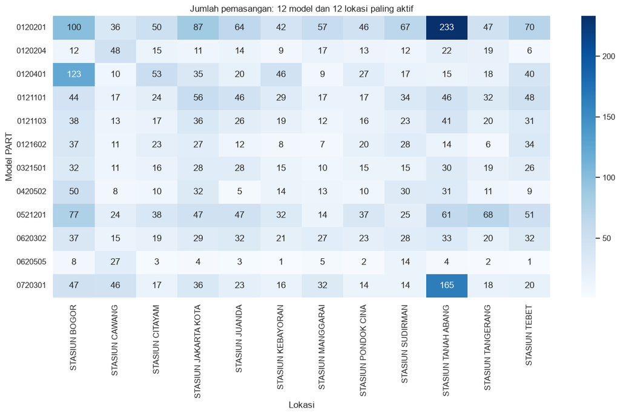

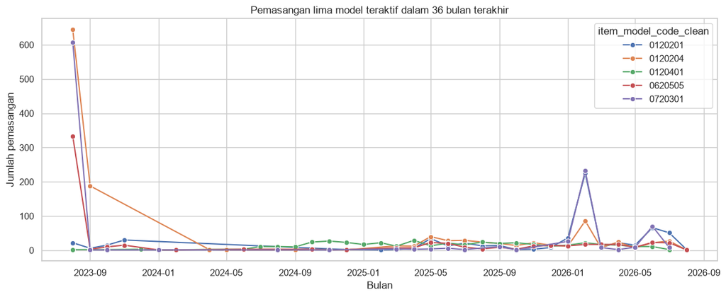

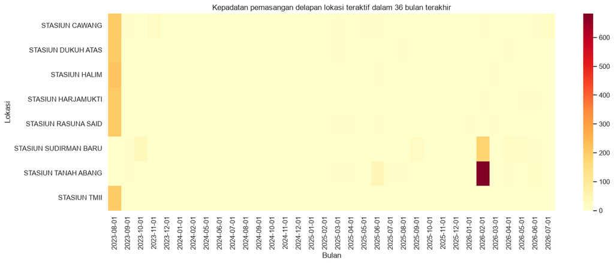

```python
model_location_scope = query("""WITH scope AS (SELECT item_model_code_clean, COUNT(*) location_count, SUM(installation_count) installations, SUM(item_count) item_location_pairs FROM analytics.eda_item_location_installation_summary GROUP BY item_model_code_clean) SELECT CASE WHEN location_count=1 THEN 'Hanya 1 lokasi' WHEN location_count<=5 THEN '2-5 lokasi' WHEN location_count<=20 THEN '6-20 lokasi' ELSE '>20 lokasi' END location_scope, COUNT(*) model_count, SUM(installations) installations FROM scope GROUP BY 1 ORDER BY MIN(location_count)""")
display(model_location_scope.rename(columns={'location_scope': 'Sebaran model', 'model_count': 'Jumlah model', 'installations': 'Jumlah pemasangan'}))
item_location_matrix = query("""WITH top_model AS (SELECT item_model_code_clean FROM analytics.eda_item_location_installation_summary GROUP BY 1 ORDER BY SUM(installation_count) DESC LIMIT 12), top_location AS (SELECT place_canonical_clean FROM analytics.eda_item_location_installation_summary GROUP BY 1 ORDER BY SUM(installation_count) DESC LIMIT 12) SELECT s.item_model_code_clean, s.place_canonical_clean, s.installation_count FROM analytics.eda_item_location_installation_summary s JOIN top_model m USING (item_model_code_clean) JOIN top_location l USING (place_canonical_clean)""")
item_location_matrix['installation_count'] = pd.to_numeric(item_location_matrix.installation_count); item_location_pivot = item_location_matrix.pivot(index='item_model_code_clean', columns='place_canonical_clean', values='installation_count').fillna(0)
plt.figure(figsize=(13, 8)); sns.heatmap(item_location_pivot, cmap='Blues', annot=True, fmt='.0f'); plt.title('Jumlah pemasangan: 12 model dan 12 lokasi paling aktif'); plt.xlabel('Lokasi'); plt.ylabel('Model PART'); plt.tight_layout(); plt.show()
recent_model_trend = query("""WITH boundary AS (SELECT MAX(created_on) cutoff FROM analytics.item_journey_operational_timeline), recent AS (SELECT DATE_TRUNC('month', o.created_on)::date activity_month, o.item_model_code_clean FROM analytics.item_journey_operational_timeline o CROSS JOIN boundary b WHERE o.item_category_clean='PART' AND o.status_clean='INSTALLED' AND o.created_on>b.cutoff-INTERVAL '36 months'), top_model AS (SELECT item_model_code_clean FROM recent GROUP BY 1 ORDER BY COUNT(*) DESC LIMIT 5) SELECT activity_month, item_model_code_clean, COUNT(*) installation_count FROM recent JOIN top_model USING (item_model_code_clean) GROUP BY 1,2 ORDER BY 1,2""")
recent_model_trend['activity_month'] = pd.to_datetime(recent_model_trend.activity_month); recent_model_trend['installation_count'] = pd.to_numeric(recent_model_trend.installation_count)
plt.figure(figsize=(12, 5)); sns.lineplot(data=recent_model_trend, x='activity_month', y='installation_count', hue='item_model_code_clean', marker='o'); plt.title('Pemasangan lima model teraktif dalam 36 bulan terakhir'); plt.xlabel('Bulan'); plt.ylabel('Jumlah pemasangan'); plt.tight_layout(); plt.show()
recent_location_trend = query("""WITH boundary AS (SELECT MAX(created_on) cutoff FROM analytics.item_journey_operational_timeline), recent AS (SELECT DATE_TRUNC('month', o.created_on)::date activity_month, o.place_canonical_clean FROM analytics.item_journey_operational_timeline o CROSS JOIN boundary b WHERE o.status_clean='INSTALLED' AND o.place_canonical_clean IS NOT NULL AND o.created_on>b.cutoff-INTERVAL '36 months'), top_location AS (SELECT place_canonical_clean FROM recent GROUP BY 1 ORDER BY COUNT(*) DESC LIMIT 8) SELECT activity_month, place_canonical_clean, COUNT(*) installation_count FROM recent JOIN top_location USING (place_canonical_clean) GROUP BY 1,2 ORDER BY 1,2""")
recent_location_trend['installation_count'] = pd.to_numeric(recent_location_trend.installation_count); recent_location_pivot = recent_location_trend.pivot(index='place_canonical_clean', columns='activity_month', values='installation_count').fillna(0)
plt.figure(figsize=(15, 6)); sns.heatmap(recent_location_pivot, cmap='YlOrRd'); plt.title('Kepadatan pemasangan delapan lokasi teraktif dalam 36 bulan terakhir'); plt.xlabel('Bulan'); plt.ylabel('Lokasi'); plt.tight_layout(); plt.show()
```

## 7. Lifecycle dan pola failure

**Pertanyaan:** berapa lama PART berada dalam cycle sebelum failure/dismantle, dan cycle mana yang berakhir jelas, reinstall, atau right-censored? Median dan persentil digunakan karena durasi sangat tidak simetris.

### 7.1 Installation -> failure

Metrik dihitung hanya pada cycle initial cohort dengan failure teramati. Hasil menjelaskan umur pada saat failure, bukan prediksi umur pasti setiap PART.

|  | Siklus dengan kerusakan | Rata-rata hari | Median hari | 90% rusak sebelum hari ke- |
| --- | --- | --- | --- | --- |
| 0 | 5876 | 932.64 | 515.83 | 2575.54 |

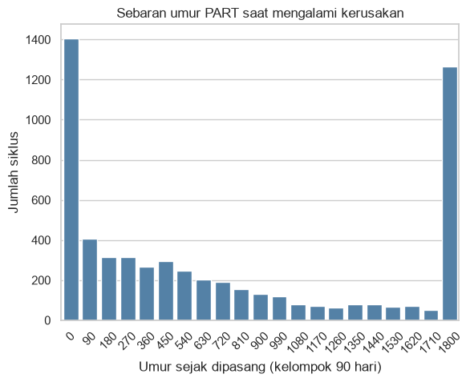

**Temuan utama:** median installation-to-failure adalah **515.83 hari**.

**Tindak lanjut:** bandingkan distribusi menurut model pada baseline; jangan gunakan rata-rata saja.

```python
cycle_stats = query("""SELECT COUNT(*) failure_cycles, ROUND(AVG(days_installed_to_failure)::numeric,2) mean_days, ROUND(PERCENTILE_CONT(0.5) WITHIN GROUP (ORDER BY days_installed_to_failure)::numeric,2) median_days, ROUND(PERCENTILE_CONT(0.9) WITHIN GROUP (ORDER BY days_installed_to_failure)::numeric,2) p90_days FROM analytics.item_installation_cycle WHERE is_initial_model_cohort AND has_observed_failure""")
display(cycle_stats.rename(columns={'failure_cycles': 'Siklus dengan kerusakan', 'mean_days': 'Rata-rata hari', 'median_days': 'Median hari', 'p90_days': '90% rusak sebelum hari ke-'}))
durations = query("SELECT LEAST(FLOOR(days_installed_to_failure / 90) * 90, 1800)::int bucket_days, COUNT(*) cycle_count FROM analytics.item_installation_cycle WHERE is_initial_model_cohort AND has_observed_failure GROUP BY 1 ORDER BY 1")
sns.barplot(data=durations, x='bucket_days', y='cycle_count', color='steelblue').set(title='Sebaran umur PART saat mengalami kerusakan', xlabel='Umur sejak dipasang (kelompok 90 hari)', ylabel='Jumlah siklus'); plt.xticks(rotation=45); plt.show()
display(Markdown(f"""**Temuan utama:** median installation-to-failure adalah **{float(cycle_stats.median_days.iloc[0]):,.2f} hari**.

**Tindak lanjut:** bandingkan distribusi menurut model pada baseline; jangan gunakan rata-rata saja.""".replace(',', '.')))
```

### 7.2 Installation -> dismantle dan lifecycle lokasi

Pasangan lokasi hanya dihitung jika installation dan dismantle dapat dipasangkan. Cycle tanpa dismantle tidak dipaksa menjadi durasi nol.

|  | Pemasangan PART | Memiliki dismantle berikutnya | Belum ada dismantle yang dapat dipasangkan | Lokasi installation=dismantle | Lokasi berbeda | Lokasi tidak tersedia | Rata-rata hari | Median hari | Persentil 90 hari | Durasi negatif |
| --- | --- | --- | --- | --- | --- | --- | --- | --- | --- | --- |
| 0 | 24045 | 6423 | 17622 | 5122 | 1294 | 7 | 939.41 | 471.55 | 2651.67 | 0 |

|  | Lokasi pemasangan | Semua pemasangan | Lifecycle lokasi sama | Rata-rata hari | Median hari | Persentil 90 hari |
| --- | --- | --- | --- | --- | --- | --- |
| 0 | STASIUN KLENDER | 236 | 76 | 3008.71 | 4495.56 | 4859.56 |
| 1 | STASIUN JATINEGARA | 198 | 63 | 2207.84 | 2015.67 | 4638.78 |
| 2 | STASIUN RAWA BUNTU | 195 | 53 | 1285.26 | 1314.76 | 2656.51 |
| 3 | STASIUN RAWA BUAYA | 134 | 41 | 1523.63 | 1190.55 | 3432.55 |
| 4 | STASIUN KAMPUNG BANDAN | 133 | 22 | 1375.11 | 1061.52 | 2638.46 |
| 5 | STASIUN TENJO | 79 | 28 | 1343.72 | 973.15 | 3314.39 |
| 6 | STASIUN JAYAKARTA | 141 | 31 | 1505.88 | 860.76 | 3111.68 |
| 7 | STASIUN KUNINGAN | 193 | 20 | 731.01 | 809.65 | 999.49 |
| 8 | STASIUN MANGGA BESAR | 191 | 65 | 1240.36 | 755.81 | 3113.61 |
| 9 | STASIUN HARJAMUKTI | 205 | 23 | 679.91 | 750.67 | 1023.64 |
| 10 | STASIUN BOJONG GEDE | 316 | 68 | 1052.72 | 748.14 | 2608.19 |
| 11 | STASIUN DARU | 80 | 25 | 1148.16 | 740.55 | 2619.54 |
| 12 | STASIUN KRANJI | 230 | 54 | 1123.08 | 735.26 | 2436.75 |
| 13 | STASIUN DUKUH ATAS | 201 | 23 | 659.50 | 734.35 | 973.92 |
| 14 | STASIUN BOJONG INDAH | 88 | 35 | 1186.09 | 724.76 | 2864.30 |
| 15 | STASIUN KALIDERES | 105 | 36 | 1282.31 | 702.49 | 3206.05 |
| 16 | STASIUN CAWANG | 429 | 72 | 907.86 | 671.58 | 2266.55 |
| 17 | STASIUN PONDOK RANJI | 328 | 58 | 1088.91 | 648.46 | 2606.45 |
| 18 | STASIUN TIGARAKSA | 85 | 24 | 1244.34 | 640.64 | 2873.93 |
| 19 | STASIUN SERPONG | 264 | 67 | 793.37 | 579.55 | 1910.15 |

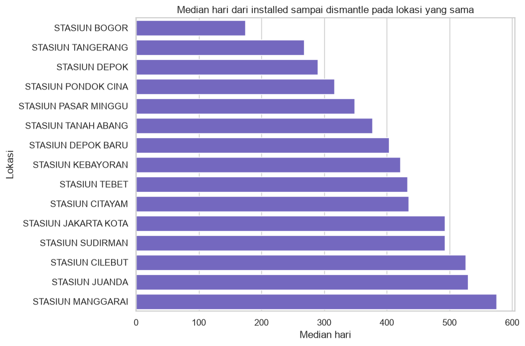

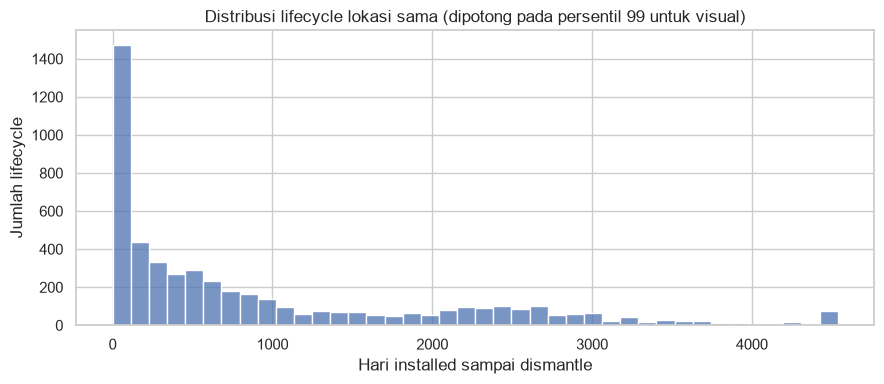

**Temuan utama:** median lifecycle pada lokasi yang sama adalah **471.55 hari**.

**Keputusan:** gunakan lifecycle lokasi hanya untuk record dengan pasangan waktu dan lokasi valid.

```python
lifecycle_overall = query("""SELECT COUNT(*) installations, COUNT(*) FILTER (WHERE has_next_dismantle) with_next_dismantle, COUNT(*) FILTER (WHERE NOT has_next_dismantle) no_dismantle_before_next_install_or_cutoff, COUNT(*) FILTER (WHERE is_same_location) same_location, COUNT(*) FILTER (WHERE is_location_mismatch) location_mismatch, COUNT(*) FILTER (WHERE has_next_dismantle AND (installed_place_clean IS NULL OR dismantled_place_clean IS NULL)) location_unavailable, ROUND(AVG(days_installed_to_dismantle) FILTER (WHERE is_same_location)::numeric,2) average_days, ROUND(PERCENTILE_CONT(.5) WITHIN GROUP (ORDER BY days_installed_to_dismantle) FILTER (WHERE is_same_location)::numeric,2) median_days, ROUND(PERCENTILE_CONT(.9) WITHIN GROUP (ORDER BY days_installed_to_dismantle) FILTER (WHERE is_same_location)::numeric,2) p90_days, COUNT(*) FILTER (WHERE days_installed_to_dismantle<0) negative_duration FROM analytics.eda_location_lifecycle_detail""")
display(lifecycle_overall.rename(columns={'installations': 'Pemasangan PART', 'with_next_dismantle': 'Memiliki dismantle berikutnya', 'no_dismantle_before_next_install_or_cutoff': 'Belum ada dismantle yang dapat dipasangkan', 'same_location': 'Lokasi installation=dismantle', 'location_mismatch': 'Lokasi berbeda', 'location_unavailable': 'Lokasi tidak tersedia', 'average_days': 'Rata-rata hari', 'median_days': 'Median hari', 'p90_days': 'Persentil 90 hari', 'negative_duration': 'Durasi negatif'}))
lifecycle_location = query("SELECT * FROM analytics.eda_location_lifecycle_summary WHERE matched_lifecycle_count>=20 ORDER BY median_days DESC")
for col in ['installation_count','matched_lifecycle_count','average_days','median_days','p90_days']: lifecycle_location[col] = pd.to_numeric(lifecycle_location[col], errors='coerce')
display(lifecycle_location.rename(columns={'installed_place_clean': 'Lokasi pemasangan', 'installation_count': 'Semua pemasangan', 'matched_lifecycle_count': 'Lifecycle lokasi sama', 'average_days': 'Rata-rata hari', 'median_days': 'Median hari', 'p90_days': 'Persentil 90 hari'}).head(20))
lifecycle_plot = lifecycle_location.sort_values('matched_lifecycle_count', ascending=False).head(15).sort_values('median_days')
plt.figure(figsize=(9, 6)); sns.barplot(data=lifecycle_plot, y='installed_place_clean', x='median_days', color='slateblue'); plt.title('Median hari dari installed sampai dismantle pada lokasi yang sama'); plt.xlabel('Median hari'); plt.ylabel('Lokasi'); plt.tight_layout(); plt.show()
lifecycle_duration = query("SELECT days_installed_to_dismantle FROM analytics.eda_location_lifecycle_detail WHERE is_same_location")['days_installed_to_dismantle'].astype(float)
lifecycle_clip = lifecycle_duration.clip(upper=lifecycle_duration.quantile(.99)); plt.figure(figsize=(9, 4)); sns.histplot(lifecycle_clip, bins=40); plt.title('Distribusi lifecycle lokasi sama (dipotong pada persentil 99 untuk visual)'); plt.xlabel('Hari installed sampai dismantle'); plt.ylabel('Jumlah lifecycle'); plt.tight_layout(); plt.show()
display(Markdown(f"""**Temuan utama:** median lifecycle pada lokasi yang sama adalah **{float(lifecycle_overall.median_days.iloc[0]):,.2f} hari**.

**Keputusan:** gunakan lifecycle lokasi hanya untuk record dengan pasangan waktu dan lokasi valid.""".replace(',', '.')))
```

## 8. Target dan faktor yang berhubungan dengan failure

**Pertanyaan:** seberapa tidak seimbang target, bagaimana karakteristik positif dan negatif, serta model/lokasi apa yang memiliki hubungan dengan failure? Hubungan tidak diartikan sebagai sebab-akibat dan selalu memakai minimum support.

### 8.1 Distribusi target dan imbalance

Target positif berarti failure terjadi setelah snapshot dan maksimal 30 hari. Negatif hanya digunakan jika follow-up penuh tersedia dan cycle tidak berakhir reinstall tanpa failure tercatat.

|  | Label | Arti label | Jumlah snapshot | Persentase (%) | Rasio negatif : positif | Status imbalance |
| --- | --- | --- | --- | --- | --- | --- |
| 0 | 0 | NO_FAILURE_WITHIN_30D | 1318269 | 99.5562 | 224.35 | SEVERE_RARE_EVENT_LT_2PCT |
| 1 | 1 | FAILURE_WITHIN_30D | 5876 | 0.4438 | 224.35 | SEVERE_RARE_EVENT_LT_2PCT |

**Kesimpulan imbalance:** hanya **0.4438%** snapshot yang positif. Terdapat sekitar **224.35 snapshot negatif untuk setiap 1 snapshot positif**. Karena itu evaluasi model nanti wajib memakai precision, recall, PR-AUC, ROC-AUC, calibration, dan confusion matrix; akurasi tidak boleh dipakai sendirian.

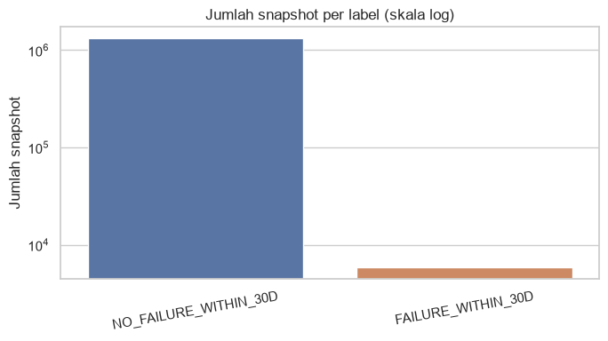

```python
target_distribution = query('SELECT * FROM analytics.eda_target_class_distribution ORDER BY label_value')
target_display = target_distribution.rename(columns={'label_value': 'Label', 'label_name': 'Arti label', 'snapshot_count': 'Jumlah snapshot', 'class_percentage': 'Persentase (%)', 'negative_to_positive_ratio': 'Rasio negatif : positif', 'imbalance_status': 'Status imbalance'})
display(target_display)
positive_row = target_distribution.loc[target_distribution.label_value.eq(1)].iloc[0]
display(Markdown(f"**Kesimpulan imbalance:** hanya **{float(positive_row.class_percentage):.4f}%** snapshot yang positif. Terdapat sekitar **{float(positive_row.negative_to_positive_ratio):.2f} snapshot negatif untuk setiap 1 snapshot positif**. Karena itu evaluasi model nanti wajib memakai precision, recall, PR-AUC, ROC-AUC, calibration, dan confusion matrix; akurasi tidak boleh dipakai sendirian."))
plt.figure(figsize=(7, 4)); ax=sns.barplot(data=target_distribution, x='label_name', y='snapshot_count', hue='label_name', legend=False); ax.set_yscale('log'); ax.set(title='Jumlah snapshot per label (skala log)', xlabel='', ylabel='Jumlah snapshot'); plt.xticks(rotation=10); plt.tight_layout(); plt.show()
```

### 8.2 Karakteristik snapshot positif dan negatif

Perbandingan memakai fitur yang tersedia pada tanggal snapshot. Sampel negatif diambil deterministik agar kelompok positif yang langka tetap terlihat.

| target_failure_30d | Jumlah snapshot | Rata-rata umur (hari) | Median umur (hari) | Rata-rata kerusakan sebelumnya | Rata-rata corrective sebelumnya | Rata-rata perpindahan | Rata-rata jumlah lokasi |
| --- | --- | --- | --- | --- | --- | --- | --- |
| Tidak rusak dalam 30 hari | 39767 | 1511.50 | 1230.0 | 0.09 | 0.74 | 0.00 | 1.38 |
| Rusak dalam 30 hari | 5876 | 918.99 | 510.0 | 0.81 | 5.26 | 0.01 | 2.52 |

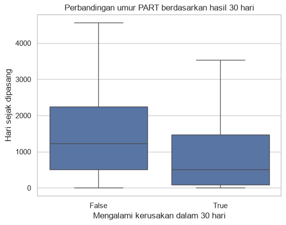

```python
sample = query("""SELECT target_failure_30d, days_since_installation, prior_failure_count, prior_corrective_count, prior_relocation_count, prior_distinct_places FROM analytics.item_observation_30d WHERE is_training_eligible AND (target_failure_30d OR MOD(ABS(HASHTEXT(installation_cycle_id || observation_date::text)::bigint), 100) < 3)""")
numeric_features = ['days_since_installation', 'prior_failure_count', 'prior_corrective_count', 'prior_relocation_count', 'prior_distinct_places']
sample[numeric_features] = sample[numeric_features].apply(pd.to_numeric, errors='coerce')
feature_summary = sample.groupby('target_failure_30d').agg(observations=('days_since_installation', 'size'), mean_age_days=('days_since_installation', 'mean'), median_age_days=('days_since_installation', 'median'), avg_prior_failures=('prior_failure_count', 'mean'), avg_prior_corrective=('prior_corrective_count', 'mean'), avg_prior_relocations=('prior_relocation_count', 'mean'), avg_prior_places=('prior_distinct_places', 'mean')).round(2)
feature_summary.index = feature_summary.index.map({False: 'Tidak rusak dalam 30 hari', True: 'Rusak dalam 30 hari'})
display(feature_summary.rename(columns={'observations': 'Jumlah snapshot', 'mean_age_days': 'Rata-rata umur (hari)', 'median_age_days': 'Median umur (hari)', 'avg_prior_failures': 'Rata-rata kerusakan sebelumnya', 'avg_prior_corrective': 'Rata-rata corrective sebelumnya', 'avg_prior_relocations': 'Rata-rata perpindahan', 'avg_prior_places': 'Rata-rata jumlah lokasi'}))
plot_data = sample[sample.days_since_installation <= sample.days_since_installation.quantile(.99)].copy()
sns.boxplot(data=plot_data, x='target_failure_30d', y='days_since_installation', showfliers=False).set(title='Perbandingan umur PART berdasarkan hasil 30 hari', xlabel='Mengalami kerusakan dalam 30 hari', ylabel='Hari sejak dipasang'); plt.show()
```

### 8.3 Risiko menurut model PART

Metrik adalah positive rate pada model dengan minimum 20 PART dan 10 snapshot positif. Model dengan volume besar tidak otomatis dianggap lebih berisiko.

|  | Model PART | Jumlah snapshot | Jumlah PART | Rusak dalam 30 hari | Persentase positif |
| --- | --- | --- | --- | --- | --- |
| 0 | 0521201 | 91544 | 1009 | 789 | 0.862 |
| 1 | 0120401 | 18883 | 362 | 706 | 3.739 |
| 2 | 0121101 | 108649 | 1134 | 543 | 0.500 |
| 3 | 0120201 | 266175 | 2852 | 514 | 0.193 |
| 4 | 0121602 | 11943 | 205 | 481 | 4.027 |
| 5 | 0120204 | 29259 | 926 | 351 | 1.200 |
| 6 | 0420502 | 51414 | 523 | 282 | 0.548 |
| 7 | 0121603 | 6281 | 102 | 252 | 4.012 |
| 8 | 0221601 | 5030 | 84 | 161 | 3.201 |
| 9 | 0120901 | 10009 | 155 | 160 | 1.599 |
| 10 | 0220402 | 5262 | 94 | 149 | 2.832 |
| 11 | 0620505 | 16724 | 522 | 148 | 0.885 |
| 12 | 0720301 | 89263 | 1853 | 136 | 0.152 |
| 13 | 0121701 | 13079 | 197 | 134 | 1.025 |
| 14 | 0121401 | 19396 | 306 | 129 | 0.665 |
| 15 | 0521202 | 2671 | 275 | 103 | 3.856 |
| 16 | 0121103 | 116880 | 1026 | 102 | 0.087 |
| 17 | 0420501 | 37888 | 391 | 77 | 0.203 |
| 18 | 1521405 | 12411 | 167 | 67 | 0.540 |
| 19 | 0420504 | 12942 | 224 | 63 | 0.487 |
| 20 | 0120202 | 23012 | 279 | 62 | 0.269 |
| 21 | 0620302 | 66397 | 986 | 50 | 0.075 |
| 22 | 0120801 | 12396 | 154 | 47 | 0.379 |
| 23 | 0220601 | 12075 | 166 | 44 | 0.364 |
| 24 | 1520512 | 20097 | 259 | 35 | 0.174 |

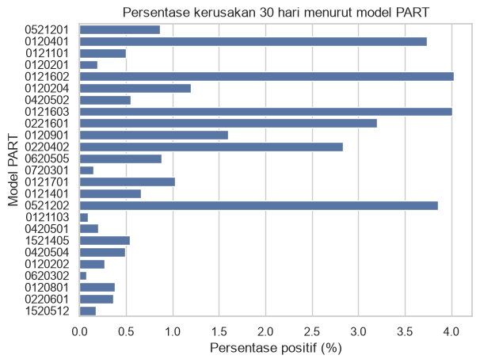

**Temuan utama:** model dengan positive rate tertinggi pada kelompok yang lolos minimum support adalah **0121602**.

**Interpretasi:** hasil ini adalah asosiasi; umur, era, lokasi, dan mix aktivitas perlu dikontrol pada model.

```python
by_model = query("""SELECT item_model_code_clean, COUNT(*) observations, COUNT(DISTINCT item_identifier_clean) items, COUNT(*) FILTER (WHERE target_failure_30d) positives, ROUND(100.0 * COUNT(*) FILTER (WHERE target_failure_30d) / COUNT(*), 3) positive_pct FROM analytics.item_observation_30d WHERE is_training_eligible GROUP BY 1 HAVING COUNT(DISTINCT item_identifier_clean) >= 20 AND COUNT(*) FILTER (WHERE target_failure_30d) >= 10 ORDER BY positives DESC LIMIT 25""")
display(by_model.rename(columns={'item_model_code_clean': 'Model PART', 'observations': 'Jumlah snapshot', 'items': 'Jumlah PART', 'positives': 'Rusak dalam 30 hari', 'positive_pct': 'Persentase positif'}))
sns.barplot(data=by_model, y='item_model_code_clean', x='positive_pct').set(title='Persentase kerusakan 30 hari menurut model PART', xlabel='Persentase positif (%)', ylabel='Model PART'); plt.show()
display(Markdown(f"""**Temuan utama:** model dengan positive rate tertinggi pada kelompok yang lolos minimum support adalah **{by_model.sort_values('positive_pct',ascending=False).iloc[0].item_model_code_clean}**.

**Interpretasi:** hasil ini adalah asosiasi; umur, era, lokasi, dan mix aktivitas perlu dikontrol pada model."""))
```

### 8.4 Risiko menurut lokasi dan interaksi model-lokasi

Hanya lokasi canonical yang dipakai. Positive rate dibandingkan pada kelompok dengan minimum support agar lokasi sibuk atau kombinasi kecil tidak menyesatkan.

|  | Lokasi terakhir | Jumlah snapshot | Jumlah PART | Rusak dalam 30 hari | Persentase positif |
| --- | --- | --- | --- | --- | --- |
| 0 | STASIUN TANAH TINGGI | 3529 | 68 | 39 | 1.1051 |
| 1 | STASIUN RASUNA SAID | 2124 | 201 | 19 | 0.8945 |
| 2 | STASIUN CIBITUNG | 1929 | 62 | 16 | 0.8294 |
| 3 | STASIUN DEPOK | 19943 | 300 | 151 | 0.7572 |
| 4 | STASIUN KARET | 9790 | 136 | 68 | 0.6946 |
| 5 | STASIUN CITAYAM | 28444 | 386 | 189 | 0.6645 |
| 6 | STASIUN BOJONG INDAH | 5319 | 71 | 35 | 0.6580 |
| 7 | STASIUN PARUNG PANJANG | 15124 | 216 | 99 | 0.6546 |
| 8 | STASIUN BOGOR | 57981 | 817 | 379 | 0.6537 |
| 9 | STASIUN DUREN KALIBATA | 14338 | 208 | 93 | 0.6486 |
| 10 | STASIUN TENJO | 4485 | 64 | 29 | 0.6466 |
| 11 | STASIUN TANJUNG PRIOK | 7787 | 141 | 50 | 0.6421 |
| 12 | STASIUN GROGOL | 5045 | 83 | 32 | 0.6343 |
| 13 | STASIUN PASAR MINGGU | 18814 | 278 | 119 | 0.6325 |
| 14 | STASIUN KEBAYORAN | 20938 | 309 | 132 | 0.6304 |
| 15 | STASIUN TANGERANG | 24171 | 349 | 151 | 0.6247 |
| 16 | STASIUN CILEBUT | 18677 | 253 | 115 | 0.6157 |
| 17 | STASIUN TEBET | 34900 | 488 | 212 | 0.6074 |
| 18 | STASIUN PORIS | 11444 | 143 | 68 | 0.5942 |
| 19 | STASIUN SAWAH BESAR | 11680 | 157 | 69 | 0.5908 |

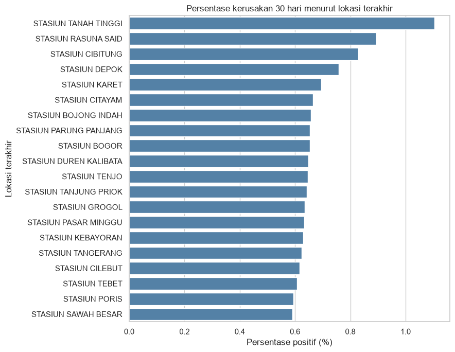

|  | Model PART | Lokasi terakhir | Jumlah snapshot | Jumlah PART | Rusak dalam 30 hari | Persentase positif |
| --- | --- | --- | --- | --- | --- | --- |
| 7 | 0120401 | STASIUN KEBAYORAN | 422 | 35 | 31 | 7.3460 |
| 5 | 0120401 | STASIUN DEPOK | 466 | 35 | 32 | 6.8670 |
| 8 | 0121603 | STASIUN TEBET | 548 | 28 | 30 | 5.4745 |
| 37 | 0120401 | STASIUN UNIVERSITAS INDONESIA | 352 | 21 | 19 | 5.3977 |
| 21 | 0121603 | STASIUN CITAYAM | 484 | 21 | 25 | 5.1653 |
| 0 | 0120401 | STASIUN BOGOR | 1829 | 89 | 93 | 5.0847 |
| 6 | 0120401 | STASIUN PASAR MINGGU | 708 | 35 | 31 | 4.3785 |
| 23 | 0121602 | STASIUN TEBET | 551 | 29 | 24 | 4.3557 |
| 31 | 0121602 | STASIUN BOGOR | 507 | 26 | 22 | 4.3393 |
| 42 | 0121602 | STASIUN CITAYAM | 442 | 21 | 19 | 4.2986 |
| 33 | 0121602 | STASIUN JAKARTA KOTA | 531 | 21 | 21 | 3.9548 |
| 18 | 0120401 | STASIUN CIKINI | 667 | 30 | 26 | 3.8981 |
| 22 | 0220402 | STASIUN JAKARTA KOTA | 656 | 28 | 25 | 3.8110 |
| 44 | 0221601 | STASIUN TANGERANG | 532 | 23 | 19 | 3.5714 |
| 4 | 0120401 | STASIUN CITAYAM | 1083 | 43 | 38 | 3.5088 |
| 12 | 0120401 | STASIUN JAKARTA KOTA | 839 | 32 | 28 | 3.3373 |
| 57 | 0120401 | STASIUN CILEBUT | 485 | 22 | 16 | 3.2990 |
| 16 | 0120401 | STASIUN SERPONG | 820 | 32 | 26 | 3.1707 |
| 55 | 0121602 | STASIUN SUDIMARA | 523 | 20 | 16 | 3.0593 |
| 9 | 0121603 | STASIUN BOGOR | 995 | 32 | 30 | 3.0151 |

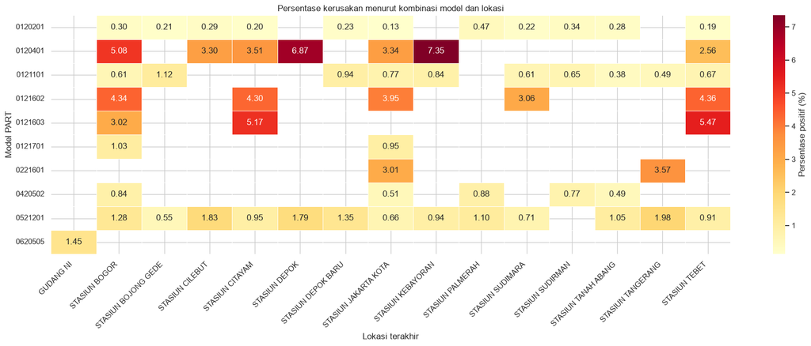

**Temuan utama:** ada **20 lokasi** dan **88 kombinasi model-lokasi** yang lolos minimum support.

**Keputusan:** uji baseline dengan dan tanpa lokasi; jangan menyimpulkan lokasi sebagai penyebab failure dari grafik ini.

```python
by_location = query("""SELECT last_place_clean, COUNT(*) observations, COUNT(DISTINCT item_identifier_clean) items, COUNT(*) FILTER (WHERE target_failure_30d) positives, ROUND(100.0 * COUNT(*) FILTER (WHERE target_failure_30d) / COUNT(*), 4) positive_pct FROM analytics.item_observation_30d WHERE is_training_eligible AND is_location_feature_eligible GROUP BY last_place_clean HAVING COUNT(DISTINCT item_identifier_clean) >= 50 AND COUNT(*) FILTER (WHERE target_failure_30d) >= 10 ORDER BY positive_pct DESC LIMIT 20""")
by_location['positive_pct'] = pd.to_numeric(by_location['positive_pct'], errors='coerce')
display(by_location.rename(columns={'last_place_clean': 'Lokasi terakhir', 'observations': 'Jumlah snapshot', 'items': 'Jumlah PART', 'positives': 'Rusak dalam 30 hari', 'positive_pct': 'Persentase positif'}))
plt.figure(figsize=(9, 7)); sns.barplot(data=by_location, y='last_place_clean', x='positive_pct', color='steelblue').set(title='Persentase kerusakan 30 hari menurut lokasi terakhir', xlabel='Persentase positif (%)', ylabel='Lokasi terakhir'); plt.tight_layout(); plt.show()
model_location = query("""SELECT item_model_code_clean, last_place_clean, COUNT(*) observations, COUNT(DISTINCT item_identifier_clean) items, COUNT(*) FILTER (WHERE target_failure_30d) positives, ROUND(100.0 * COUNT(*) FILTER (WHERE target_failure_30d) / COUNT(*), 4) positive_pct FROM analytics.item_observation_30d WHERE is_training_eligible AND is_location_feature_eligible GROUP BY 1, 2 HAVING COUNT(DISTINCT item_identifier_clean) >= 20 AND COUNT(*) FILTER (WHERE target_failure_30d) >= 10 ORDER BY positives DESC""")
model_location['positive_pct'] = pd.to_numeric(model_location['positive_pct'], errors='coerce')
display(model_location.sort_values('positive_pct', ascending=False).head(20).rename(columns={'item_model_code_clean': 'Model PART', 'last_place_clean': 'Lokasi terakhir', 'observations': 'Jumlah snapshot', 'items': 'Jumlah PART', 'positives': 'Rusak dalam 30 hari', 'positive_pct': 'Persentase positif'}))
heatmap_models = model_location.groupby('item_model_code_clean')['positives'].sum().nlargest(10).index
heatmap_locations = model_location.groupby('last_place_clean')['positives'].sum().nlargest(15).index
heatmap_source = model_location[model_location['item_model_code_clean'].isin(heatmap_models) & model_location['last_place_clean'].isin(heatmap_locations)]
heatmap_data = heatmap_source.pivot(index='item_model_code_clean', columns='last_place_clean', values='positive_pct')
plt.figure(figsize=(18, 7)); sns.heatmap(heatmap_data, cmap='YlOrRd', annot=True, fmt='.2f', linewidths=.4, cbar_kws={'label': 'Persentase positif (%)'}); plt.title('Persentase kerusakan menurut kombinasi model dan lokasi'); plt.xlabel('Lokasi terakhir'); plt.ylabel('Model PART'); plt.xticks(rotation=45, ha='right'); plt.tight_layout(); plt.show()
display(Markdown(f"""**Temuan utama:** ada **{len(by_location)} lokasi** dan **{len(model_location)} kombinasi model-lokasi** yang lolos minimum support.

**Keputusan:** uji baseline dengan dan tanpa lokasi; jangan menyimpulkan lokasi sebagai penyebab failure dari grafik ini."""))
```

### 8.5 Label gap: RETURNED/outcome tanpa onset tepercaya

RETURNED dan status outcome tidak otomatis membuka failure baru. Tabel ini mencari kandidat review agar ground truth tetap ketat.

|  | Siklus yang perlu diperiksa | Siklus dengan RETURNED | Siklus dengan status rusak yang jelas |
| --- | --- | --- | --- |
| 0 | 717 | 717 | 1 |

|  | Kelompok kejadian | Status | Jumlah kejadian | Jumlah siklus |
| --- | --- | --- | --- | --- |
| 0 | FAILURE_OUTCOME | BROKEN | 1 | 1 |
| 1 | RETURN_FLOW | RETURNED | 719 | 717 |

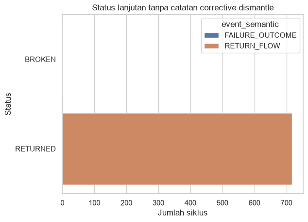

```python
label_gap_summary = query("""WITH candidate AS (SELECT c.installation_cycle_id, BOOL_OR(o.event_semantic = 'RETURN_FLOW') has_return, BOOL_OR(o.event_semantic = 'FAILURE_OUTCOME') has_failure_outcome FROM analytics.item_installation_cycle c JOIN analytics.item_journey_operational_timeline o ON o.item_identifier_clean = c.item_identifier_clean AND o.created_on > c.installed_on AND o.created_on <= c.cycle_end_on WHERE NOT c.has_observed_failure AND o.event_semantic IN ('RETURN_FLOW', 'FAILURE_OUTCOME') GROUP BY c.installation_cycle_id) SELECT COUNT(*) candidate_cycles, COUNT(*) FILTER (WHERE has_return) returned_cycles, COUNT(*) FILTER (WHERE has_failure_outcome) explicit_failure_outcome_cycles FROM candidate""")
display(label_gap_summary.rename(columns={'candidate_cycles': 'Siklus yang perlu diperiksa', 'returned_cycles': 'Siklus dengan RETURNED', 'explicit_failure_outcome_cycles': 'Siklus dengan status rusak yang jelas'}))
label_gap_detail = query("""SELECT o.event_semantic, o.status_clean, COUNT(*) event_count, COUNT(DISTINCT c.installation_cycle_id) cycle_count FROM analytics.item_installation_cycle c JOIN analytics.item_journey_operational_timeline o ON o.item_identifier_clean = c.item_identifier_clean AND o.created_on > c.installed_on AND o.created_on <= c.cycle_end_on WHERE NOT c.has_observed_failure AND o.event_semantic IN ('RETURN_FLOW', 'FAILURE_OUTCOME') GROUP BY o.event_semantic, o.status_clean ORDER BY o.event_semantic, event_count DESC""")
display(label_gap_detail.rename(columns={'event_semantic': 'Kelompok kejadian', 'status_clean': 'Status', 'event_count': 'Jumlah kejadian', 'cycle_count': 'Jumlah siklus'}))
sns.barplot(data=label_gap_detail, y='status_clean', x='cycle_count', hue='event_semantic').set(title='Status lanjutan tanpa catatan corrective dismantle', xlabel='Jumlah siklus', ylabel='Status'); plt.show()
```

### 8.6 Failure dengan flow lanjutan belum lengkap

Failure tetap positif bila onset-nya valid. Umur follow-up dipakai untuk membedakan proses yang mungkin masih berjalan dari kemungkinan histori hilang.

|  | Kelompok pemeriksaan | Jumlah failure | Jumlah PART | Tanggal paling awal | Tanggal paling akhir |
| --- | --- | --- | --- | --- | --- |
| 0 | Kemungkinan masih berjalan (0-30 hari) | 82 | 81 | 2026-07-05 | 2026-08-03 |
| 1 | Perlu dipantau (31-180 hari) | 217 | 209 | 2026-02-05 | 2026-07-03 |
| 2 | Kemungkinan histori hilang (>180 hari) | 478 | 467 | 2014-05-07 | 2026-02-03 |

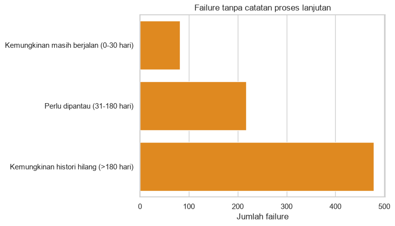

|  | Model PART | Tanggal dipasang | Lokasi pemasangan | Tanggal status rusak | Status rusak | Saran label review |
| --- | --- | --- | --- | --- | --- | --- |
| 0 | 0220601 | 2019-01-18 | STASIUN SUDIMARA | 2024-07-01 | BROKEN | FAILURE_WITH_MISSING_ONSET_REVIEW |

```python
incomplete = query("""SELECT * FROM analytics.eda_incomplete_failure_summary ORDER BY CASE followup_review_group WHEN 'LIKELY_ONGOING_0_30D' THEN 1 WHEN 'REVIEW_31_180D' THEN 2 ELSE 3 END""")
incomplete_labels = {'LIKELY_ONGOING_0_30D': 'Kemungkinan masih berjalan (0-30 hari)', 'REVIEW_31_180D': 'Perlu dipantau (31-180 hari)', 'LIKELY_HISTORY_GAP_GT_180D': 'Kemungkinan histori hilang (>180 hari)'}
incomplete_display = incomplete.assign(followup_review_group=incomplete['followup_review_group'].replace(incomplete_labels)).rename(columns={'followup_review_group': 'Kelompok pemeriksaan', 'failure_count': 'Jumlah failure', 'item_count': 'Jumlah PART', 'earliest_failure_date': 'Tanggal paling awal', 'latest_failure_date': 'Tanggal paling akhir'})
display(incomplete_display)
sns.barplot(data=incomplete_display, y='Kelompok pemeriksaan', x='Jumlah failure', color='darkorange').set(title='Failure tanpa catatan proses lanjutan', xlabel='Jumlah failure', ylabel=''); plt.show()
missing_onset = query('SELECT item_model_code_clean, installed_on::date installed_on, installed_place_clean, outcome_on::date outcome_on, outcome_status, suggested_label FROM analytics.failure_outcome_missing_onset_review ORDER BY outcome_on')
display(missing_onset.rename(columns={'item_model_code_clean': 'Model PART', 'installed_on': 'Tanggal dipasang', 'installed_place_clean': 'Lokasi pemasangan', 'outcome_on': 'Tanggal status rusak', 'outcome_status': 'Status rusak', 'suggested_label': 'Saran label review'}))
```

### 8.7 Sensitivitas cadence snapshot

Cadence 7 dan 30 hari dibandingkan berdasarkan failure yang tertangkap dan berapa kali satu failure muncul sebagai peringatan positif.

|  | Jarak snapshot (hari) | Semua snapshot | Layak digunakan | Follow-up belum lengkap | Snapshot positif | Persentase positif | Cycle dengan failure | Failure tertangkap | Failure tidak tertangkap | Rata-rata peringatan per failure |
| --- | --- | --- | --- | --- | --- | --- | --- | --- | --- | --- |
| 0 | 7 | 5990056 | 5640429 | 349627 | 22670 | 0.4019 | 5876 | 5876 | 0 | 3.86 |
| 1 | 30 | 1406086 | 1324145 | 81941 | 5876 | 0.4438 | 5876 | 5876 | 0 | 1.00 |

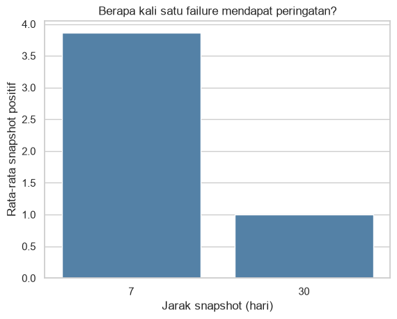

|  | Cara menghitung | Jumlah yang diperiksa | Jumlah positif | Persentase positif | Arti |
| --- | --- | --- | --- | --- | --- |
| 0 | INSTALLATION_CYCLE | 23927 | 5876 | 24.5580 | Satu periode sejak PART dipasang sampai failur... |
| 1 | SNAPSHOT_30D | 1324145 | 5876 | 0.4438 | Kondisi PART pada satu tanggal; satu PART dapa... |
| 2 | UNIQUE_PART | 19155 | 3727 | 19.4571 | Satu PART hanya dihitung sekali walaupun mempu... |

Ada **174** failure dalam maksimal satu hari setelah pemasangan, dan **174** semuanya tertangkap dari snapshot pertama.

```python
cadence = query('SELECT * FROM analytics.eda_snapshot_cadence_comparison ORDER BY cadence_days')
cadence_numeric = ['all_snapshots', 'eligible_snapshots', 'incomplete_followup_snapshots', 'positive_snapshots', 'positive_percentage', 'failure_cycles', 'captured_failure_cycles', 'uncaptured_failure_cycles', 'average_positive_snapshots_per_failure']
cadence[cadence_numeric] = cadence[cadence_numeric].apply(pd.to_numeric, errors='coerce')
display(cadence.rename(columns={'cadence_days': 'Jarak snapshot (hari)', 'all_snapshots': 'Semua snapshot', 'eligible_snapshots': 'Layak digunakan', 'incomplete_followup_snapshots': 'Follow-up belum lengkap', 'positive_snapshots': 'Snapshot positif', 'positive_percentage': 'Persentase positif', 'failure_cycles': 'Cycle dengan failure', 'captured_failure_cycles': 'Failure tertangkap', 'uncaptured_failure_cycles': 'Failure tidak tertangkap', 'average_positive_snapshots_per_failure': 'Rata-rata peringatan per failure'}))
sns.barplot(data=cadence, x='cadence_days', y='average_positive_snapshots_per_failure', color='steelblue').set(title='Berapa kali satu failure mendapat peringatan?', xlabel='Jarak snapshot (hari)', ylabel='Rata-rata snapshot positif'); plt.show()
unit_comparison = query('SELECT * FROM analytics.eda_failure_unit_comparison ORDER BY analysis_unit')
display(unit_comparison.rename(columns={'analysis_unit': 'Cara menghitung', 'population_count': 'Jumlah yang diperiksa', 'positive_count': 'Jumlah positif', 'positive_percentage': 'Persentase positif', 'explanation': 'Arti'}))
fast_failure = query("""SELECT COUNT(*) FILTER (WHERE failure_onset_on - installed_on <= INTERVAL '1 day') failure_le_1d, COUNT(*) FILTER (WHERE failure_onset_on > installed_on AND failure_onset_on - installed_on <= INTERVAL '1 day') captured_from_first_snapshot FROM analytics.item_installation_cycle WHERE is_initial_model_cohort AND has_observed_failure""")
display(Markdown(f"Ada **{int(fast_failure.failure_le_1d.iloc[0])}** failure dalam maksimal satu hari setelah pemasangan, dan **{int(fast_failure.captured_from_first_snapshot.iloc[0])}** semuanya tertangkap dari snapshot pertama."))
```

## 9. Hierarki PART-TERMINAL, analisis bivariat, dan multivariat

**Pertanyaan:** apakah PART terhubung dengan TERMINAL, apakah konteks terminal berasosiasi dengan failure PART, dan apakah asosiasi tersebut tetap terlihat setelah karakteristik PART dikontrol?

Relasi bersifat **many-to-one pada satu installation cycle** dan dapat menjadi many-to-many sepanjang histori karena PART dapat berpindah terminal. Mapping menggunakan `host_serial_code + wo_code` installation ke `t_item_request_out`, lalu `parent_serial_code` menjadi identitas TERMINAL. Timestamp pencatatan link tetap diaudit karena relasi historis lama dapat merupakan backfill.

### 9.1 Struktur relasi dan analisis bivariat

Bivariat membandingkan satu fitur dengan target tanpa adjustment. Positive rate, risk ratio, Wilson 95%, minimum support, dan Cramér's V dilaporkan bersama. Hasil ini adalah asosiasi prediktif, bukan sebab-akibat.

|  | Metrik relasi | Jumlah | Interpretasi |
| --- | --- | --- | --- |
| 0 | installation_cycles | 24045.0 | Seluruh installation cycle PART |
| 1 | linked_unique_parts | 19232.0 | PART unik yang mempunyai parent TERMINAL valid... |
| 2 | linked_unique_terminals | 2315.0 | TERMINAL fisik unik yang menjadi parent pada i... |
| 3 | parent_link_recorded_after_installation_cycles | 10313.0 | Relasi historis yang dicatat setelah waktu ins... |
| 4 | training_observations | 1324145.0 | Seluruh snapshot yang layak training |
| 5 | valid_parent_terminal_cycles | 24008.0 | Cycle dengan parent yang valid di master dan i... |
| 6 | valid_parent_terminal_training_observations | 1323877.0 | Snapshot training dengan konteks parent TERMIN... |

|  | Hubungan | Chi-square | Cramér's V | N | Interpretasi |
| --- | --- | --- | --- | --- | --- |
| 0 | PART_MODEL_VS_TERMINAL_TYPE | 47800.380214 | 0.705517 | 24008 | Confounding struktur: nilai tinggi menuntut ad... |
| 1 | TERMINAL_TYPE_VS_TARGET | 6168.583333 | 0.068260 | 1323877 | Effect size bivariat; target memiliki dua kelas |

|  | Tipe TERMINAL | Snapshot | PART | TERMINAL | Positif | Positive rate (%) | Risk ratio vs overall | Wilson lower 95% | Wilson upper 95% | Minimum support |
| --- | --- | --- | --- | --- | --- | --- | --- | --- | --- | --- |
| 0 | BALANCE READER | 6451 | 208 | 190 | 314 | 4.8675 | 10.9687 | 4.3687 | 5.4200 | True |
| 1 | UNMAPPED | 268 | 18 | 0 | 5 | 1.8657 | 4.2043 | 0.7995 | 4.2923 | False |
| 2 | CVIM | 217892 | 3049 | 262 | 2537 | 1.1643 | 2.6238 | 1.1201 | 1.2103 | True |
| 3 | VENDING MACHINE | 10157 | 454 | 80 | 65 | 0.6400 | 1.4421 | 0.5024 | 0.8148 | True |
| 4 | POS | 72316 | 1123 | 309 | 229 | 0.3167 | 0.7136 | 0.2783 | 0.3603 | True |
| 5 | GATE | 1017061 | 14275 | 1469 | 2726 | 0.2680 | 0.6040 | 0.2582 | 0.2783 | True |

|  | Model TERMINAL | Tipe TERMINAL | Snapshot | PART | TERMINAL | Positif | Positive rate (%) | Risk ratio vs overall | meets_minimum_support |
| --- | --- | --- | --- | --- | --- | --- | --- | --- | --- |
| 0 | 0312101 | BALANCE READER | 6451 | 208 | 190 | 314 | 4.8675 | 10.9687 | True |
| 1 | 0110401 | CVIM | 17602 | 384 | 26 | 312 | 1.7725 | 3.9944 | True |
| 2 | 0110403 | CVIM | 57137 | 905 | 95 | 777 | 1.3599 | 3.0645 | True |
| 3 | 0110402 | CVIM | 77806 | 1203 | 68 | 916 | 1.1773 | 2.6530 | True |
| 4 | 0310201 | VENDING MACHINE | 7303 | 253 | 36 | 65 | 0.8900 | 2.0057 | True |
| 5 | 0110404 | CVIM | 64516 | 827 | 50 | 523 | 0.8107 | 1.8268 | True |
| 6 | 0310301 | POS | 6212 | 197 | 36 | 30 | 0.4829 | 1.0883 | True |
| 7 | 0310302 | POS | 65176 | 861 | 261 | 199 | 0.3053 | 0.6880 | True |
| 8 | 0110501 | GATE | 911930 | 10638 | 1062 | 2568 | 0.2816 | 0.6346 | True |
| 9 | 1310102 | GATE | 6957 | 216 | 68 | 14 | 0.2012 | 0.4535 | True |
| 10 | 0510103 | GATE | 82595 | 2458 | 238 | 128 | 0.1550 | 0.3492 | True |
| 11 | 0510101 | GATE | 14798 | 815 | 81 | 13 | 0.0878 | 0.1980 | True |

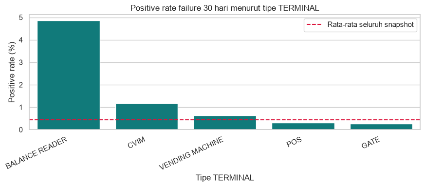

**Temuan bivariat:** tipe TERMINAL berasosiasi dengan target dengan Cramér's V **0.0683**, sedangkan hubungan model PART dengan tipe TERMINAL jauh lebih kuat, V **0.7055**. Karena itu perbedaan rate terminal berpotensi kuat dipengaruhi komposisi model PART dan wajib diuji multivariat.

```python
hierarchy_summary = query('SELECT * FROM analytics.eda_part_terminal_structure_summary ORDER BY metric')
hierarchy_summary['value'] = pd.to_numeric(hierarchy_summary.value, errors='coerce')
display(hierarchy_summary.rename(columns={'metric':'Metrik relasi','value':'Jumlah','interpretation':'Interpretasi'}))
association_summary = query('SELECT * FROM analytics.eda_bivariate_association_summary ORDER BY association')
for col in ['chi_square','cramers_v','observation_count']: association_summary[col] = pd.to_numeric(association_summary[col], errors='coerce')
display(association_summary.rename(columns={'association':'Hubungan','chi_square':'Chi-square','cramers_v':"Cramér's V",'observation_count':'N','interpretation':'Interpretasi'}))
terminal_type_risk = query('SELECT * FROM analytics.eda_bivariate_terminal_type_target ORDER BY positive_percentage DESC')
terminal_model_risk = query('SELECT * FROM analytics.eda_bivariate_terminal_model_target WHERE meets_minimum_support ORDER BY positive_percentage DESC')
for frame in [terminal_type_risk, terminal_model_risk]:
    for col in ['snapshot_count','part_count','terminal_count','positive_count','positive_percentage','risk_ratio_to_overall']:
        frame[col] = pd.to_numeric(frame[col], errors='coerce')
display(terminal_type_risk.rename(columns={'terminal_type':'Tipe TERMINAL','snapshot_count':'Snapshot','part_count':'PART','terminal_count':'TERMINAL','positive_count':'Positif','positive_percentage':'Positive rate (%)','risk_ratio_to_overall':'Risk ratio vs overall','wilson_lower_95_pct':'Wilson lower 95%','wilson_upper_95_pct':'Wilson upper 95%','meets_minimum_support':'Minimum support'}))
display(terminal_model_risk.rename(columns={'terminal_model_code':'Model TERMINAL','terminal_type':'Tipe TERMINAL','snapshot_count':'Snapshot','part_count':'PART','terminal_count':'TERMINAL','positive_count':'Positif','positive_percentage':'Positive rate (%)','risk_ratio_to_overall':'Risk ratio vs overall'}))
plot_type = terminal_type_risk.loc[terminal_type_risk.meets_minimum_support & terminal_type_risk.terminal_type.ne('UNMAPPED')].sort_values('positive_percentage', ascending=False)
plt.figure(figsize=(9,4)); sns.barplot(data=plot_type, x='terminal_type', y='positive_percentage', color='darkcyan'); plt.axhline(float(positive_row.class_percentage), color='crimson', linestyle='--', label='Rata-rata seluruh snapshot'); plt.title('Positive rate failure 30 hari menurut tipe TERMINAL'); plt.xlabel('Tipe TERMINAL'); plt.ylabel('Positive rate (%)'); plt.xticks(rotation=25, ha='right'); plt.legend(); plt.tight_layout(); plt.show()
terminal_target_v = float(association_summary.loc[association_summary.association.eq('TERMINAL_TYPE_VS_TARGET'),'cramers_v'].iloc[0])
part_terminal_v = float(association_summary.loc[association_summary.association.eq('PART_MODEL_VS_TERMINAL_TYPE'),'cramers_v'].iloc[0])
display(Markdown(f"""**Temuan bivariat:** tipe TERMINAL berasosiasi dengan target dengan Cramér's V **{terminal_target_v:.4f}**, sedangkan hubungan model PART dengan tipe TERMINAL jauh lebih kuat, V **{part_terminal_v:.4f}**. Karena itu perbedaan rate terminal berpotensi kuat dipengaruhi komposisi model PART dan wajib diuji multivariat."""))
```

### 9.2 Analisis multivariat bertingkat

Tiga Logistic Regression L2 dibandingkan: **M1 PART-only**, **M2 PART+TERMINAL**, dan **M3 adjusted operational history**. Data 2014-2024 menjadi train, 2025 validation, dan 2026 test; embargo 30 hari tetap berlaku. Seluruh positif dipertahankan dan negatif diambil deterministik 1:25 dengan bobot 25 untuk mengembalikan distribusi populasi. Analisis ini adalah screening multivariat EDA; final modeling tetap memerlukan tuning, calibration, clustered uncertainty, dan sensitivity terhadap link backfill.

|  | Model | Periode | PR-AUC | ROC-AUC | Brier | Log loss |
| --- | --- | --- | --- | --- | --- | --- |
| 0 | M0 Prevalence | Validation 2025 | 0.00579 | 0.50000 | 0.00576 | 0.03603 |
| 1 | M0 Prevalence | Test 2026 | 0.00898 | 0.50000 | 0.00893 | 0.05381 |
| 2 | M1 PART-only | Validation 2025 | 0.05175 | 0.75132 | 0.00563 | 0.03262 |
| 3 | M1 PART-only | Test 2026 | 0.06977 | 0.71843 | 0.00876 | 0.05056 |
| 4 | M2 PART+TERMINAL | Validation 2025 | 0.05185 | 0.73412 | 0.00563 | 0.03319 |
| 5 | M2 PART+TERMINAL | Test 2026 | 0.06571 | 0.68005 | 0.00877 | 0.05232 |
| 6 | M3 Adjusted history | Validation 2025 | 0.08744 | 0.73112 | 0.00554 | 0.03161 |
| 7 | M3 Adjusted history | Test 2026 | 0.11711 | 0.72476 | 0.00849 | 0.04718 |

|  | Fitur | Koefisien | Adjusted odds multiplier |
| --- | --- | --- | --- |
| 38 | terminal_type=CVIM | 0.8014 | 2.2288 |
| 40 | terminal_type=VENDING MACHINE | 0.7631 | 2.1449 |
| 42 | terminal_type=OTHER | 0.0187 | 1.0189 |
| 41 | terminal_type=BALANCE READER | -0.0924 | 0.9118 |
| 39 | terminal_type=POS | -0.7879 | 0.4548 |

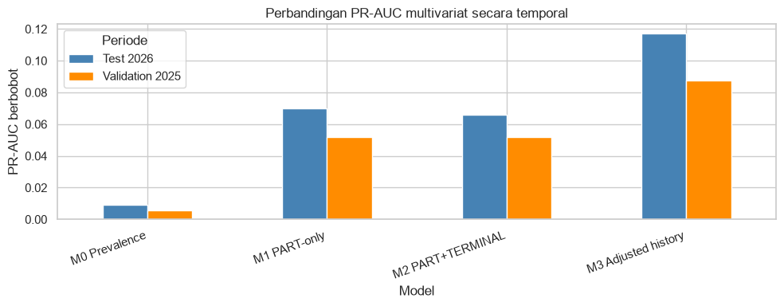

**Cara membaca:** kenaikan M1→M2 mengukur nilai tambah konteks TERMINAL setelah model PART dan umur dikontrol. M2→M3 menunjukkan nilai tambah histori operasional. Koefisien terminal adalah odds multiplier teradjust regularized terhadap referensi GATE, bukan estimasi kausal atau confidence interval final. Kategori dengan overlap model PART yang lemah—terutama Balance Reader yang hanya didukung satu model PART—tidak mempunyai efek terminal independen yang teridentifikasi dengan baik.

```python
multivariate_sample = query("""
SELECT CASE
         WHEN observation_on + INTERVAL '30 days' < DATE '2025-01-01' THEN 'TRAIN_2014_2024'
         WHEN observation_on >= DATE '2025-01-01' AND observation_on + INTERVAL '30 days' < DATE '2026-01-01' THEN 'VALIDATION_2025'
         WHEN observation_on >= DATE '2026-01-01' THEN 'TEST_2026'
       END split, target_failure_30d::integer target,
       item_model_code_clean,
       CASE WHEN is_parent_link_valid THEN terminal_type ELSE 'UNMAPPED' END terminal_type,
       installed_client_clean, observation_month::text observation_month,
       days_since_installation, total_prior_events, prior_failure_count,
       prior_corrective_count, prior_distinct_places, days_since_last_event,
       days_since_last_failure, days_since_last_corrective, prior_failure_365d,
       is_parent_link_recorded_after_installation
FROM analytics.eda_item_observation_30d_hierarchy
WHERE is_training_eligible AND observation_on >= DATE '2014-01-01'
  AND (target_failure_30d OR MOD(ABS(HASHTEXT(installation_cycle_id || observation_date::text)::bigint),25)=0)
  AND NOT (observation_on < DATE '2025-01-01' AND observation_on + INTERVAL '30 days' >= DATE '2025-01-01')
  AND NOT (observation_on < DATE '2026-01-01' AND observation_on + INTERVAL '30 days' >= DATE '2026-01-01')
""")
multivariate_sample['sample_weight'] = np.where(multivariate_sample.target.eq(1), 1.0, 25.0)
def _prepare_design(train, frames, categorical, numeric):
    matrices = [np.ones((len(frame),1), dtype=float) for frame in frames]
    names = ['intercept']
    for col in categorical:
        train_value = train[col].astype('string').fillna('UNKNOWN')
        counts = train_value.value_counts()
        levels = list(counts[counts.ge(50)].index)
        reference = 'GATE' if col == 'terminal_type' and 'GATE' in levels else levels[0]
        levels = [reference] + [v for v in levels if v != reference]
        for level in levels[1:] + ['OTHER']:
            for i, frame in enumerate(frames):
                value = frame[col].astype('string').fillna('UNKNOWN')
                mapped = value.where(value.isin(levels), 'OTHER')
                matrices[i] = np.column_stack([matrices[i], mapped.eq(level).to_numpy(float)])
            names.append(f'{col}={level}')
    for col in numeric:
        train_raw = pd.to_numeric(train[col], errors='coerce')
        median = float(train_raw.median()) if train_raw.notna().any() else 0.0
        transformed_train = np.log1p(np.clip(train_raw.fillna(median).to_numpy(float),0,None))
        mean, std = transformed_train.mean(), transformed_train.std() or 1.0
        for i, frame in enumerate(frames):
            raw = pd.to_numeric(frame[col], errors='coerce')
            missing = raw.isna().to_numpy(float)
            value = (np.log1p(np.clip(raw.fillna(median).to_numpy(float),0,None))-mean)/std
            matrices[i] = np.column_stack([matrices[i], value, missing])
        names.extend([col, f'{col}_missing'])
    return matrices, names
def _fit_ridge_logistic(X, y, weight, l2=1.0, max_iter=30):
    beta = np.zeros(X.shape[1]); penalty = np.ones(X.shape[1]); penalty[0] = 0
    weight = np.asarray(weight,float); weight = weight/weight.mean()
    for _ in range(max_iter):
        probability = 1/(1+np.exp(-np.clip(X@beta,-30,30)))
        curvature = weight*probability*(1-probability)
        hessian = X.T@(X*curvature[:,None]) + l2*np.diag(penalty)
        gradient = X.T@(weight*(y-probability)) - l2*penalty*beta
        step = np.linalg.solve(hessian, gradient); beta += step
        if np.max(np.abs(step)) < 1e-6: break
    return beta
def _weighted_metrics(y, probability, weight):
    y=np.asarray(y,int); p=np.clip(np.asarray(probability,float),1e-9,1-1e-9); w=np.asarray(weight,float)
    grouped=pd.DataFrame({'p':p,'y':y,'w':w}).groupby('p',sort=True).apply(lambda g: pd.Series({'pos':(g.y*g.w).sum(),'neg':((1-g.y)*g.w).sum()}),include_groups=False)
    ranked=grouped.sort_index(ascending=False); cumulative_positive=ranked.pos.cumsum(); cumulative_total=(ranked.pos+ranked.neg).cumsum()
    ap=float(np.sum((cumulative_positive/cumulative_total)*(ranked.pos/ranked.pos.sum())))
    cum_neg=grouped.neg.cumsum()-grouped.neg; auc=float((grouped.pos*(cum_neg+.5*grouped.neg)).sum()/(grouped.pos.sum()*grouped.neg.sum()))
    return {'PR-AUC':ap,'ROC-AUC':auc,'Brier':float(np.average((y-p)**2,weights=w)),'Log loss':float(np.average(-(y*np.log(p)+(1-y)*np.log(1-p)),weights=w))}
train_mv=multivariate_sample.loc[multivariate_sample.split.eq('TRAIN_2014_2024')].copy(); validation_mv=multivariate_sample.loc[multivariate_sample.split.eq('VALIDATION_2025')].copy(); test_mv=multivariate_sample.loc[multivariate_sample.split.eq('TEST_2026')].copy()
model_specs={
 'M1 PART-only': (['item_model_code_clean'],['days_since_installation']),
 'M2 PART+TERMINAL': (['item_model_code_clean','terminal_type'],['days_since_installation']),
 'M3 Adjusted history': (['item_model_code_clean','terminal_type','installed_client_clean','observation_month'],['days_since_installation','total_prior_events','prior_failure_count','prior_corrective_count','prior_distinct_places','days_since_last_event','days_since_last_failure','days_since_last_corrective','prior_failure_365d'])}
results=[]; fitted={}
base_probability=np.average(train_mv.target,weights=train_mv.sample_weight)
for split_name,frame in [('Validation 2025',validation_mv),('Test 2026',test_mv)]:
    results.append({'Model':'M0 Prevalence','Periode':split_name,**_weighted_metrics(frame.target,np.full(len(frame),base_probability),frame.sample_weight)})
for model_name,(categorical,numeric) in model_specs.items():
    (x_train,x_validation,x_test),feature_names=_prepare_design(train_mv,[train_mv,validation_mv,test_mv],categorical,numeric)
    coefficient=_fit_ridge_logistic(x_train,train_mv.target.to_numpy(),train_mv.sample_weight.to_numpy())
    fitted[model_name]=(coefficient,feature_names)
    for split_name,frame,X in [('Validation 2025',validation_mv,x_validation),('Test 2026',test_mv,x_test)]:
        probability=1/(1+np.exp(-np.clip(X@coefficient,-30,30)))
        results.append({'Model':model_name,'Periode':split_name,**_weighted_metrics(frame.target,probability,frame.sample_weight)})
multivariate_result=pd.DataFrame(results)
display(multivariate_result.round(5))
coef,names=fitted['M3 Adjusted history']; adjusted_terminal=pd.DataFrame({'Fitur':names,'Koefisien':coef}); adjusted_terminal=adjusted_terminal[adjusted_terminal.Fitur.str.startswith('terminal_type=')].copy(); adjusted_terminal['Adjusted odds multiplier']=np.exp(adjusted_terminal.Koefisien); display(adjusted_terminal.sort_values('Adjusted odds multiplier',ascending=False).round(4))
pivot_pr=multivariate_result.pivot(index='Model',columns='Periode',values='PR-AUC'); pivot_pr.plot(kind='bar',figsize=(10,4),color=['steelblue','darkorange']); plt.title('Perbandingan PR-AUC multivariat secara temporal'); plt.ylabel('PR-AUC berbobot'); plt.xticks(rotation=20,ha='right'); plt.tight_layout(); plt.show()
display(Markdown("**Cara membaca:** kenaikan M1→M2 mengukur nilai tambah konteks TERMINAL setelah model PART dan umur dikontrol. M2→M3 menunjukkan nilai tambah histori operasional. Koefisien terminal adalah odds multiplier teradjust regularized terhadap referensi GATE, bukan estimasi kausal atau confidence interval final. Kategori dengan overlap model PART yang lemah—terutama Balance Reader yang hanya didukung satu model PART—tidak mempunyai efek terminal independen yang teridentifikasi dengan baik."))
```

## 10. Feature readiness dan transformasi sebelum modeling

**Pertanyaan:** fitur mana yang tersedia, redundan, berpotensi informatif, atau berisiko leakage? Feature selection hanya boleh belajar dari periode train. Karena itu split waktu ditentukan lebih dahulu, lalu korelasi dan IV dihitung pada train 2014-2024 dengan embargo 30 hari.

### 10.1 Time-based split dan embargo target

Random split dilarang. Snapshot yang horizon 30 harinya menyeberangi batas tahun train/validation dikeluarkan sebagai embargo. Data 2026 tidak digunakan untuk memilih fitur, parameter, atau threshold.

```python
splits = query("""
SELECT split, COUNT(*) observations, COUNT(DISTINCT item_identifier_clean) items,
       COUNT(*) FILTER (WHERE target_failure_30d) positives,
       ROUND(100.0*COUNT(*) FILTER (WHERE target_failure_30d)/NULLIF(COUNT(*),0),4) positive_pct
FROM (
    SELECT o.*,
        CASE
          WHEN observation_on < DATE '2014-01-01' THEN 'EXCLUDED_PRE_2014'
          WHEN observation_on + INTERVAL '30 days' < DATE '2025-01-01' THEN 'TRAIN_2014_2024'
          WHEN observation_on < DATE '2025-01-01' THEN 'EXCLUDED_TRAIN_EMBARGO'
          WHEN observation_on + INTERVAL '30 days' < DATE '2026-01-01' THEN 'VALIDATION_2025'
          WHEN observation_on < DATE '2026-01-01' THEN 'EXCLUDED_VALIDATION_EMBARGO'
          ELSE 'TEST_2026'
        END split
    FROM analytics.item_observation_30d o
    WHERE is_training_eligible
) s GROUP BY split ORDER BY MIN(observation_on)
""")
display(splits.rename(columns={'split':'Pembagian waktu','observations':'Snapshot','items':'PART','positives':'Positif','positive_pct':'Positive rate (%)'}))
display(Markdown("""**Keputusan:** gunakan train 2014-2024, validation 2025, dan test 2026. Baris embargo/pre-2014 tidak masuk training baseline utama; data 2013 hanya digunakan untuk sensitivity comparison."""))
```

|  | Pembagian waktu | Snapshot | PART | Positif | Positive rate (%) |
| --- | --- | --- | --- | --- | --- |
| 0 | EXCLUDED_PRE_2014 | 23599 | 3056 | 34 | 0.1441 |
| 1 | TRAIN_2014_2024 | 1009744 | 15569 | 3852 | 0.3815 |
| 2 | EXCLUDED_TRAIN_EMBARGO | 13774 | 13771 | 34 | 0.2468 |
| 3 | VALIDATION_2025 | 162367 | 15385 | 947 | 0.5832 |
| 4 | EXCLUDED_VALIDATION_EMBARGO | 15066 | 15063 | 107 | 0.7102 |
| 5 | TEST_2026 | 99595 | 17214 | 902 | 0.9057 |

**Keputusan:** gunakan train 2014-2024, validation 2025, dan test 2026. Baris embargo/pre-2014 tidak masuk training baseline utama; data 2013 hanya digunakan untuk sensitivity comparison.

### 10.2 Missing, korelasi, redundansi, dan Information Value

Pearson dan Spearman memeriksa redundancy; IV adalah screening univariat, bukan feature importance final. Seluruh perhitungan pemilihan fitur di bagian ini dibatasi pada train agar validation/test tidak bocor ke keputusan fitur.

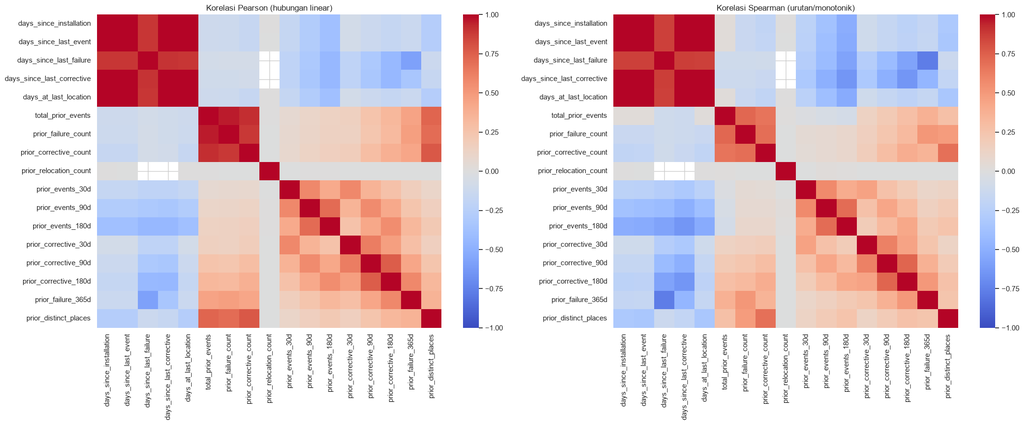

|  | Fitur pertama | Fitur kedua | \|Spearman\| | Tindakan |
| --- | --- | --- | --- | --- |
| 18 | days_since_last_event | days_at_last_location | 0.999894 | Hampir duplikat: prioritaskan satu setelah val... |
| 0 | days_since_installation | days_since_last_event | 0.997576 | Hampir duplikat: prioritaskan satu setelah val... |
| 3 | days_since_installation | days_at_last_location | 0.997573 | Hampir duplikat: prioritaskan satu setelah val... |
| 44 | days_since_last_corrective | days_at_last_location | 0.993084 | Hampir duplikat: prioritaskan satu setelah val... |
| 2 | days_since_installation | days_since_last_corrective | 0.992983 | Hampir duplikat: prioritaskan satu setelah val... |
| 17 | days_since_last_event | days_since_last_corrective | 0.992886 | Hampir duplikat: prioritaskan satu setelah val... |
| 31 | days_since_last_failure | days_since_last_corrective | 0.869594 | Redundan tinggi: uji salah satu/interaksi, jan... |
| 32 | days_since_last_failure | days_at_last_location | 0.861906 | Redundan tinggi: uji salah satu/interaksi, jan... |
| 16 | days_since_last_event | days_since_last_failure | 0.861382 | Redundan tinggi: uji salah satu/interaksi, jan... |
| 1 | days_since_installation | days_since_last_failure | 0.861170 | Redundan tinggi: uji salah satu/interaksi, jan... |

|  | Fitur | Information Value (IV) | Interpretasi awal |
| --- | --- | --- | --- |
| 3 | days_since_last_corrective | 1.207858 | Sangat kuat: cek leakage/drift |
| 19 | prior_distinct_places | 0.862052 | Sangat kuat: cek leakage/drift |
| 5 | total_prior_events | 0.849953 | Sangat kuat: cek leakage/drift |
| 2 | days_since_last_failure | 0.814137 | Sangat kuat: cek leakage/drift |
| 6 | prior_failure_count | 0.730529 | Sangat kuat: cek leakage/drift |
| 7 | prior_corrective_count | 0.719556 | Sangat kuat: cek leakage/drift |
| 14 | prior_corrective_30d | 0.463626 | Kuat |
| 18 | prior_failure_365d | 0.459803 | Kuat |
| 4 | days_at_last_location | 0.363286 | Kuat |
| 0 | days_since_installation | 0.362808 | Kuat |
| 1 | days_since_last_event | 0.353809 | Kuat |
| 13 | prior_events_180d | 0.291774 | Sedang |
| 8 | prior_relocation_count | 0.001177 | Sangat lemah |
| 11 | prior_events_30d | 0.000000 | Sangat lemah |
| 9 | prior_preventive_count | 0.000000 | Sangat lemah |
| 10 | prior_repair_process_count | 0.000000 | Sangat lemah |
| 15 | prior_corrective_90d | 0.000000 | Sangat lemah |
| 12 | prior_events_90d | 0.000000 | Sangat lemah |
| 17 | prior_preventive_90d | 0.000000 | Sangat lemah |
| 16 | prior_corrective_180d | 0.000000 | Sangat lemah |

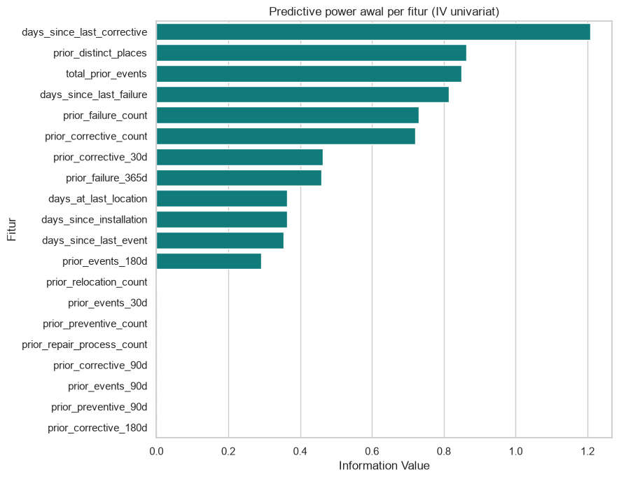

**Temuan utama:** terdapat **10 pasangan fitur** dengan |Spearman| minimal 0,80. IV train tertinggi adalah **days_since_last_corrective (1.2079)**.

**Tindak lanjut:** bandingkan feature subset melalui temporal validation; IV tinggi wajib diaudit terhadap missing struktural, leakage, dan drift.

```python
candidate_numeric_features = ['days_since_installation','days_since_last_event','days_since_last_failure','days_since_last_corrective','days_at_last_location','total_prior_events','prior_failure_count','prior_corrective_count','prior_relocation_count','prior_preventive_count','prior_repair_process_count','prior_events_30d','prior_events_90d','prior_events_180d','prior_corrective_30d','prior_corrective_90d','prior_corrective_180d','prior_preventive_90d','prior_failure_365d','prior_distinct_places']
feature_sql = ', '.join(candidate_numeric_features)
correlation_sample = query(f"SELECT target_failure_30d, {feature_sql} FROM analytics.item_observation_30d WHERE is_training_eligible AND observation_on >= DATE '2014-01-01' AND observation_on + INTERVAL '30 days' < DATE '2025-01-01' AND MOD(ABS(HASHTEXT(installation_cycle_id || observation_date::text)::bigint), 20)=0")
correlation_sample[candidate_numeric_features] = correlation_sample[candidate_numeric_features].apply(pd.to_numeric, errors='coerce')
correlation_features = [c for c in candidate_numeric_features if correlation_sample[c].nunique(dropna=True) > 1]
pearson_corr = correlation_sample[correlation_features].corr(method='pearson')
spearman_corr = correlation_sample[correlation_features].corr(method='spearman')
fig, axes = plt.subplots(1, 2, figsize=(22, 9)); sns.heatmap(pearson_corr, cmap='coolwarm', center=0, vmin=-1, vmax=1, ax=axes[0]); axes[0].set_title('Korelasi Pearson (hubungan linear)'); sns.heatmap(spearman_corr, cmap='coolwarm', center=0, vmin=-1, vmax=1, ax=axes[1]); axes[1].set_title('Korelasi Spearman (urutan/monotonik)'); plt.tight_layout(); plt.show()
upper_mask = np.triu(np.ones(spearman_corr.shape, dtype=bool), k=1)
redundant_pairs = spearman_corr.abs().where(upper_mask).stack().reset_index()
redundant_pairs.columns = ['feature_1','feature_2','abs_spearman']
redundant_pairs = redundant_pairs.loc[redundant_pairs.abs_spearman.ge(0.80)].sort_values('abs_spearman', ascending=False)
redundant_pairs['keputusan'] = np.where(redundant_pairs.abs_spearman.ge(0.95), 'Hampir duplikat: prioritaskan satu setelah validasi waktu', 'Redundan tinggi: uji salah satu/interaksi, jangan masukkan buta')
display(redundant_pairs.rename(columns={'feature_1':'Fitur pertama','feature_2':'Fitur kedua','abs_spearman':'|Spearman|','keputusan':'Tindakan'}))
iv_sample = query(f"SELECT target_failure_30d, {feature_sql} FROM analytics.item_observation_30d WHERE is_training_eligible AND observation_on >= DATE '2014-01-01' AND observation_on + INTERVAL '30 days' < DATE '2025-01-01' AND (target_failure_30d OR MOD(ABS(HASHTEXT(installation_cycle_id || observation_date::text)::bigint),100)<3)")
iv_sample[candidate_numeric_features] = iv_sample[candidate_numeric_features].apply(pd.to_numeric, errors='coerce')
def calculate_information_value(frame, feature, target='target_failure_30d'):
    work = frame[[feature, target]].copy()
    nonmissing = work[feature].dropna()
    if nonmissing.nunique() > 10:
        bins = pd.Series('MISSING', index=work.index, dtype='object')
        try:
            bins.loc[nonmissing.index] = pd.qcut(nonmissing, q=10, duplicates='drop').astype(str)
        except ValueError:
            bins.loc[nonmissing.index] = nonmissing.astype(str)
    else:
        bins = work[feature].astype('string').fillna('MISSING')
    table = pd.crosstab(bins, work[target].astype(bool))
    negative = table.get(False, pd.Series(0, index=table.index)).astype(float) + 0.5
    positive = table.get(True, pd.Series(0, index=table.index)).astype(float) + 0.5
    negative_dist, positive_dist = negative / negative.sum(), positive / positive.sum()
    return float(((positive_dist-negative_dist) * np.log(positive_dist/negative_dist)).sum())
iv_result = pd.DataFrame({'feature': candidate_numeric_features, 'information_value': [calculate_information_value(iv_sample, f) for f in candidate_numeric_features]})
iv_result['screening'] = pd.cut(iv_result.information_value, bins=[-np.inf,.02,.10,.30,.50,np.inf], labels=['Sangat lemah','Lemah','Sedang','Kuat','Sangat kuat: cek leakage/drift'])
iv_result = iv_result.sort_values('information_value', ascending=False)
display(iv_result.rename(columns={'feature':'Fitur','information_value':'Information Value (IV)','screening':'Interpretasi awal'}))
plt.figure(figsize=(9, 7)); sns.barplot(data=iv_result, y='feature', x='information_value', color='darkcyan').set(title='Predictive power awal per fitur (IV univariat)', xlabel='Information Value', ylabel='Fitur'); plt.tight_layout(); plt.show()
display(Markdown(f"""**Temuan utama:** terdapat **{len(redundant_pairs)} pasangan fitur** dengan |Spearman| minimal 0,80. IV train tertinggi adalah **{iv_result.iloc[0].feature} ({iv_result.iloc[0].information_value:.4f})**.

**Tindak lanjut:** bandingkan feature subset melalui temporal validation; IV tinggi wajib diaudit terhadap missing struktural, leakage, dan drift."""))
```

### 10.3 Keputusan final fitur dan output feature engineering

Keputusan fitur dibakukan dalam catalog database agar alasan keep/drop tidak hanya berada di narasi notebook. `failure_30d_baseline_features` hanya berisi key dan fitur baseline yang telah ditransformasi; `failure_30d_challenger_features` menambahkan lokasi, hierarchy terminal, interaksi, serta kandidat redundan untuk eksperimen terkontrol. Label dan temporal split berada terpisah pada `failure_30d_model_labels`. View `failure_30d_model_audit` hanya untuk QA dan tidak boleh menjadi input training langsung.

```python
feature_catalog = query('SELECT * FROM analytics.failure_30d_feature_catalog ORDER BY decision, feature_group, feature_name')
feature_quality = query('SELECT * FROM analytics.failure_30d_feature_quality_summary ORDER BY metric')
feature_split = query("SELECT temporal_split, COUNT(*) snapshots, COUNT(*) FILTER (WHERE target_failure_30d) positives FROM analytics.failure_30d_model_labels GROUP BY temporal_split ORDER BY temporal_split")
decision_summary = feature_catalog.groupby('decision',as_index=False).size().rename(columns={'decision':'Keputusan','size':'Jumlah fitur'})
display(decision_summary)
display(feature_catalog.loc[feature_catalog.decision.str.startswith('KEEP')].rename(columns={'feature_name':'Fitur hasil','source_column':'Sumber','feature_group':'Kelompok','decision':'Keputusan','transformation':'Transformasi','missing_handling':'Penanganan missing','rationale':'Alasan'}))
display(feature_catalog.loc[feature_catalog.decision.str.startswith('DROP')].rename(columns={'feature_name':'Fitur dibuang','source_column':'Sumber','feature_group':'Kelompok','decision':'Keputusan','transformation':'Transformasi','missing_handling':'Penanganan missing','rationale':'Alasan'}))
display(feature_quality.rename(columns={'metric':'Quality check','value':'Nilai','expectation':'Ekspektasi'}))
display(feature_split.rename(columns={'temporal_split':'Split waktu','snapshots':'Snapshot','positives':'Positif'}))
engineered_sample = query("SELECT * FROM analytics.failure_30d_baseline_features ORDER BY observation_on DESC LIMIT 10")
display(engineered_sample)
baseline_kept = int(feature_catalog.decision.eq('KEEP_BASELINE').sum()); challenger_kept = int(feature_catalog.decision.eq('KEEP_CHALLENGER').sum()); dropped = int(feature_catalog.decision.str.startswith('DROP').sum())
display(Markdown(f"""**Output siap modeling:** **{baseline_kept} fitur baseline**, **{challenger_kept} kandidat challenger**, dan **{dropped} fitur/kelompok raw yang dibuang atau diganti transformasi**. Quality gate memastikan jumlah feature row sama dengan label, key ganda nol, seluruh fitur inti/non-null hasil engineering lengkap, dan tidak ada nama kolom target/future pada feature views.

Join training yang diwajibkan: `(installation_cycle_id, item_identifier_clean, observation_on)`, filter `temporal_split`, lalu pilih view baseline atau challenger—jangan membaca `failure_30d_model_audit` sebagai matriks training."""))
```

|  | Keputusan | Jumlah fitur |
| --- | --- | --- |
| 0 | AUDIT_ONLY | 5 |
| 1 | DROP_LEAKAGE | 2 |
| 2 | DROP_RAW | 2 |
| 3 | DROP_REDUNDANT | 3 |
| 4 | DROP_REDUNDANT_WEAK | 2 |
| 5 | DROP_REPLACED | 2 |
| 6 | DROP_WEAK | 5 |
| 7 | DROP_WEAK_DRIFT | 1 |
| 8 | KEEP_BASELINE | 16 |
| 9 | KEEP_CHALLENGER | 10 |

|  | Fitur hasil | Sumber | Kelompok | Keputusan | Transformasi | Penanganan missing | Alasan |
| --- | --- | --- | --- | --- | --- | --- | --- |
| 22 | has_prior_corrective | prior_corrective_count | BINARY | KEEP_BASELINE | GREATER_THAN_ZERO | FALSE_IS_VALID | Pendamping missing struktural recency corrective |
| 23 | has_prior_failure | prior_failure_count | BINARY | KEEP_BASELINE | GREATER_THAN_ZERO | FALSE_IS_VALID | Memisahkan PART yang belum pernah failure dari... |
| 24 | month_cos | observation_month | CALENDAR | KEEP_BASELINE | CYCLIC_COS | NOT_NULL | Pasangan month_sin untuk merepresentasikan sik... |
| 25 | month_sin | observation_month | CALENDAR | KEEP_BASELINE | CYCLIC_SIN | NOT_NULL | Musiman tanpa menganggap Desember jauh dari Ja... |
| 26 | client_category | installed_client_clean | CATEGORICAL | KEEP_BASELINE | ONE_HOT | UNKNOWN_CATEGORY | Empat kategori dengan coverage penuh; konteks ... |
| 27 | part_model_category | item_model_code_clean | CATEGORICAL | KEEP_BASELINE | ONE_HOT_RARE_GROUP | UNKNOWN_CATEGORY | Model PART merupakan identitas teknis utama da... |
| 28 | log_prior_corrective_30d | prior_corrective_30d | COUNT | KEEP_BASELINE | LOG1P | ZERO_IS_VALID | Window corrective 30 hari kuat pada screening ... |
| 29 | log_prior_corrective_count | prior_corrective_count | COUNT | KEEP_BASELINE | LOG1P | ZERO_IS_NEVER_CORRECTIVE | Histori corrective mempunyai IV tinggi dan rel... |
| 30 | log_prior_distinct_places | prior_distinct_places | COUNT | KEEP_BASELINE | LOG1P | ZERO_IS_VALID | Mobilitas/lifecycle mempunyai IV tinggi |
| 31 | log_prior_events_180d | prior_events_180d | COUNT | KEEP_BASELINE | LOG1P | ZERO_IS_VALID | Window event 180 hari mempunyai IV sedang dan ... |
| 32 | log_prior_failure_365d | prior_failure_365d | COUNT | KEEP_BASELINE | LOG1P | ZERO_IS_VALID | Menangkap failure yang masih relatif baru |
| 33 | log_prior_failure_count | prior_failure_count | COUNT | KEEP_BASELINE | LOG1P | ZERO_IS_NEVER_FAILED | Failure berulang kuat membedakan snapshot posi... |
| 34 | log_total_prior_events | total_prior_events | COUNT | KEEP_BASELINE | LOG1P | ZERO_IS_VALID | IV tinggi; intensitas histori tanpa dominasi o... |
| 35 | installation_age_band | days_since_installation | DURATION | KEEP_BASELINE | BUSINESS_BINS | UNKNOWN_CATEGORY | Menangkap hubungan umur non-linear yang tidak ... |
| 36 | log_days_since_installation | days_since_installation | DURATION | KEEP_BASELINE | LOG1P | NOT_NULL_BY_COHORT | Umur cycle informatif tetapi sangat right-skewed |
| 37 | log_days_since_last_corrective | days_since_last_corrective | DURATION | KEEP_BASELINE | LOG1P_PLUS_FLAG | ZERO_PLUS_HAS_PRIOR_FLAG | Screening IV tertinggi; missing berarti belum ... |
| 38 | day_of_week_cos | observation_day_of_week | CALENDAR | KEEP_CHALLENGER | CYCLIC_COS | NOT_NULL | Pasangan day_of_week_sin |
| 39 | day_of_week_sin | observation_day_of_week | CALENDAR | KEEP_CHALLENGER | CYCLIC_SIN | NOT_NULL | Efek jadwal mungkin ada, tetapi dapat menjadi ... |
| 40 | last_status_category | last_status_clean | CATEGORICAL | KEEP_CHALLENGER | ONE_HOT_RARE_GROUP | UNKNOWN_CATEGORY | Point-in-time valid, tetapi perlu audit apakah... |
| 41 | location_category | last_place_clean | CATEGORICAL | KEEP_CHALLENGER | ONE_HOT_RARE_GROUP | UNKNOWN_CATEGORY | Coverage tinggi dan rate berbeda, tetapi perlu... |
| 42 | log_days_at_last_location | days_at_last_location | DURATION | KEEP_CHALLENGER | LOG1P | ZERO_PLUS_MISSING_FLAG | Informatif tetapi sangat berkorelasi dengan um... |
| 43 | log_days_since_last_event | days_since_last_event | DURATION | KEEP_CHALLENGER | LOG1P | ZERO_PLUS_MISSING_FLAG | Informatif tetapi hampir duplikat umur install... |
| 44 | terminal_model_category | terminal_model_code | HIERARCHY | KEEP_CHALLENGER | ONE_HOT_RARE_GROUP | UNKNOWN_CATEGORY | Lebih detail daripada tipe terminal, tetapi ra... |
| 45 | terminal_type_category | terminal_type | HIERARCHY | KEEP_CHALLENGER | ONE_HOT | UNKNOWN_CATEGORY | M2 tidak memberi lift test yang stabil; tetap ... |
| 46 | part_location_interaction | part_model_code + last_place_clean | INTERACTION | KEEP_CHALLENGER | CONCAT_RARE_GROUP | UNKNOWN_CATEGORY | Menguji risiko kombinasi model-lokasi tanpa me... |
| 47 | part_terminal_type_interaction | part_model_code + terminal_type | INTERACTION | KEEP_CHALLENGER | CONCAT_RARE_GROUP | UNKNOWN_CATEGORY | Compatibility PART-terminal dapat non-linear; ... |

|  | Fitur dibuang | Sumber | Kelompok | Keputusan | Transformasi | Penanganan missing | Alasan |
| --- | --- | --- | --- | --- | --- | --- | --- |
| 5 | cycle_end_and_observability | cycle_end_* / is_*observable | LEAKAGE | DROP_LEAKAGE | NONE | NOT_APPLICABLE | Menjelaskan bagaimana label masa depan dapat d... |
| 6 | future_failure_columns | next_failure_* | LEAKAGE | DROP_LEAKAGE | NONE | NOT_APPLICABLE | Berisi jawaban atau informasi setelah snapshot |
| 7 | installed_on | installed_on | RAW_DATETIME | DROP_RAW | DERIVE_DURATION_ONLY | NOT_NULL | Timestamp absolut mendorong memorisasi era dan... |
| 8 | observation_date | observation_date | RAW_DATETIME | DROP_RAW | DERIVE_CALENDAR_ONLY | NOT_NULL | Tanggal absolut tidak dipakai sebagai predictor |
| 9 | is_weekend | is_weekend | CALENDAR | DROP_REDUNDANT | NONE | NOT_NULL | Redundan dengan hari dalam minggu dan berpoten... |
| 10 | observation_quarter | observation_quarter | CALENDAR | DROP_REDUNDANT | NONE | NOT_NULL | Redundan dengan representasi siklik bulan |
| 11 | days_since_last_failure | days_since_last_failure | DURATION | DROP_REDUNDANT | NONE | STRUCTURAL_MISSING | Missing 94% dan berkorelasi tinggi dengan corr... |
| 12 | prior_corrective_180d | prior_corrective_180d | COUNT | DROP_REDUNDANT_WEAK | NONE | ZERO_IS_VALID | IV nol dan redundan dengan count total/30 hari |
| 13 | prior_corrective_90d | prior_corrective_90d | COUNT | DROP_REDUNDANT_WEAK | NONE | ZERO_IS_VALID | IV nol dan redundan dengan count total/30 hari |
| 14 | days_at_last_location | days_at_last_location | DURATION | DROP_REPLACED | REPLACED_BY_OPTIONAL_LOG | STRUCTURAL_MISSING | Raw scale hampir duplikat last-event/installat... |
| 15 | days_since_last_event | days_since_last_event | DURATION | DROP_REPLACED | REPLACED_BY_OPTIONAL_LOG | STRUCTURAL_MISSING | Raw scale sangat skewed dan hampir duplikat umur |
| 16 | prior_events_30d | prior_events_30d | COUNT | DROP_WEAK | NONE | ZERO_IS_VALID | IV univariat nol pada train |
| 17 | prior_events_90d | prior_events_90d | COUNT | DROP_WEAK | NONE | ZERO_IS_VALID | IV univariat nol; window 180 hari dipilih seba... |
| 18 | prior_preventive_30d_90d_180d | prior_preventive_* | COUNT | DROP_WEAK | NONE | ZERO_IS_VALID | Window preventive tidak menunjukkan separation... |
| 19 | prior_preventive_count | prior_preventive_count | COUNT | DROP_WEAK | NONE | ZERO_IS_VALID | IV nol dan event preventive sangat jarang |
| 20 | prior_relocation_count | prior_relocation_count | COUNT | DROP_WEAK | NONE | ZERO_IS_VALID | IV sekitar 0.001; tidak layak menambah komplek... |
| 21 | prior_repair_process_count | prior_repair_process_count | COUNT | DROP_WEAK_DRIFT | NONE | ZERO_IS_VALID | IV nol dan definisi proses berubah sejak 2025 |

|  | Quality check | Nilai | Ekspektasi |
| --- | --- | --- | --- |
| 0 | baseline_feature_rows | 1406086 | Harus sama dengan seluruh item_observation_30d |
| 1 | duplicate_feature_keys | 0 | Harus nol |
| 2 | label_rows | 1406086 | Harus sama dengan baseline_feature_rows |
| 3 | null_core_categories | 0 | Harus nol |
| 4 | null_engineered_numeric | 0 | Harus nol |

|  | Split waktu | Snapshot | Positif |
| --- | --- | --- | --- |
| 0 | EXCLUDED_LABEL_QUALITY | 81941 | 0 |
| 1 | EXCLUDED_PRE_2014 | 23599 | 34 |
| 2 | EXCLUDED_TRAIN_EMBARGO | 13774 | 34 |
| 3 | EXCLUDED_VALIDATION_EMBARGO | 15066 | 107 |
| 4 | TEST_2026 | 99595 | 902 |
| 5 | TRAIN_2014_2024 | 1009744 | 3852 |
| 6 | VALIDATION_2025 | 162367 | 947 |

|  | installation_cycle_id | item_identifier_clean | observation_on | part_model_category | client_category | log_days_since_installation | installation_age_band | log_total_prior_events | log_prior_failure_count | has_prior_failure | log_prior_corrective_count | has_prior_corrective | log_days_since_last_corrective | log_prior_distinct_places | log_prior_corrective_30d | log_prior_failure_365d | log_prior_events_180d | month_sin | month_cos |
| --- | --- | --- | --- | --- | --- | --- | --- | --- | --- | --- | --- | --- | --- | --- | --- | --- | --- | --- | --- |
| 0 | 012503400100096:1 | 012503400100096 | 2026-08-03 10:59:29.000 | 0120201 | KERETA COMMUTER INDONESIA (KCI) | 5.3518581334760665 | 181_365_DAYS | 1.7917594692280550 | 0E-16 | False | 1.6094379124341004 | True | 5.3518581334760665 | 1.0986122886681097 | 0E-16 | 0E-16 | 0E-16 | -0.5 | -0.866025 |
| 1 | 012602300300693:2 | 012602300300693 | 2026-08-03 10:59:18.966 | 0120201 | KERETA COMMUTER INDONESIA (KCI) | 0E-24 | 000_090_DAYS | 3.0445224377234230 | 0.6931471805599453 | True | 1.9459101490553133 | True | 0E-24 | 1.3862943611198906 | 1.9459101490553133 | 0.6931471805599453 | 2.9957322735539910 | -0.5 | -0.866025 |
| 2 | 012503100600288:2 | 012503100600288 | 2026-08-03 10:54:41.000 | 0120204 | KERETA COMMUTER INDONESIA (KCI) | 5.7071102647488757 | 181_365_DAYS | 2.9444389791664405 | 0.6931471805599453 | True | 1.7917594692280550 | True | 5.7071102647488757 | 1.6094379124341004 | 0E-16 | 0.6931471805599453 | 0E-16 | -0.5 | -0.866025 |
| 3 | 012503100600893:3 | 012503100600893 | 2026-08-03 10:47:04.102 | 0120201 | KERETA COMMUTER INDONESIA (KCI) | 0E-24 | 000_090_DAYS | 3.3322045101752039 | 1.0986122886681097 | True | 2.4849066497880003 | True | 0E-24 | 1.6094379124341004 | 2.4849066497880003 | 1.0986122886681097 | 3.1354942159291497 | -0.5 | -0.866025 |
| 4 | 011202400101483:1 | 011202400101483 | 2026-08-03 10:43:42.175 | 0521202 | KERETA COMMUTER INDONESIA (KCI) | 0E-24 | 000_090_DAYS | 2.8332133440562161 | 0.6931471805599453 | True | 1.9459101490553133 | True | 0E-24 | 1.3862943611198906 | 1.9459101490553133 | 0.6931471805599453 | 2.7725887222397812 | -0.5 | -0.866025 |
| 5 | 012503100600298:3 | 012503100600298 | 2026-08-03 10:27:10.326 | 0120204 | KERETA COMMUTER INDONESIA (KCI) | 3.4339872044851462 | 000_090_DAYS | 3.3322045101752039 | 1.0986122886681097 | True | 2.4849066497880003 | True | 3.4339872044851462 | 1.3862943611198906 | 0E-16 | 1.0986122886681097 | 2.7725887222397812 | -0.5 | -0.866025 |
| 6 | 011202400102838:3 | 011202400102838 | 2026-08-03 10:27:08.535 | 0521202 | KERETA COMMUTER INDONESIA (KCI) | 0E-24 | 000_090_DAYS | 3.6635616461296464 | 1.3862943611198906 | True | 2.8903717578961647 | True | 0E-24 | 1.3862943611198906 | 1.9459101490553133 | 1.3862943611198906 | 3.6375861597263858 | -0.5 | -0.866025 |
| 7 | 012503100600414:4 | 012503100600414 | 2026-08-03 10:23:47.890 | 1521405 | KERETA COMMUTER INDONESIA (KCI) | 3.4339872044851462 | 000_090_DAYS | 3.6888794541139363 | 1.3862943611198906 | True | 2.8903717578961647 | True | 3.4339872044851462 | 1.3862943611198906 | 0E-16 | 1.0986122886681097 | 3.3322045101752039 | -0.5 | -0.866025 |
| 8 | 011201100101372:2 | 011201100101372 | 2026-08-03 10:18:16.875 | 0521201 | KERETA COMMUTER INDONESIA (KCI) | 0E-24 | 000_090_DAYS | 2.7080502011022101 | 0.6931471805599453 | True | 1.9459101490553133 | True | 0E-24 | 1.3862943611198906 | 1.7917594692280550 | 0E-16 | 2.0794415416798359 | -0.5 | -0.866025 |
| 9 | 011201100201189:2 | 011201100201189 | 2026-08-03 10:10:17.000 | 0620505 | KERETA COMMUTER INDONESIA (KCI) | 6.0426328336823814 | 366_730_DAYS | 2.5649493574615367 | 0.6931471805599453 | True | 2.3025850929940457 | True | 6.0426328336823814 | 1.0986122886681097 | 0E-16 | 0E-16 | 0E-16 | -0.5 | -0.866025 |

**Output siap modeling:** **16 fitur baseline**, **10 kandidat challenger**, dan **17 fitur/kelompok raw yang dibuang atau diganti transformasi**. Quality gate memastikan jumlah feature row sama dengan label, key ganda nol, seluruh fitur inti/non-null hasil engineering lengkap, dan tidak ada nama kolom target/future pada feature views.

Join training yang diwajibkan: `(installation_cycle_id, item_identifier_clean, observation_on)`, filter `temporal_split`, lalu pilih view baseline atau challenger—jangan membaca `failure_30d_model_audit` sebagai matriks training.

## 11. Stability, keputusan, dan kesimpulan

**Pertanyaan:** apakah fitur dan risiko stabil setelah periode train? PSI 2025/2026 dibandingkan terhadap 2024, lalu hasil model/lokasi, anomaly, cleaning decision, dan next action dirangkum. Tahun 2026 masih parsial sampai cutoff data.

### 11.1 Feature drift dan stability model/lokasi

PSI <0,10 relatif stabil, 0,10-0,25 perlu dipantau, dan >=0,25 menunjukkan drift besar. Stability risiko tetap dilihat per model dan lokasi.

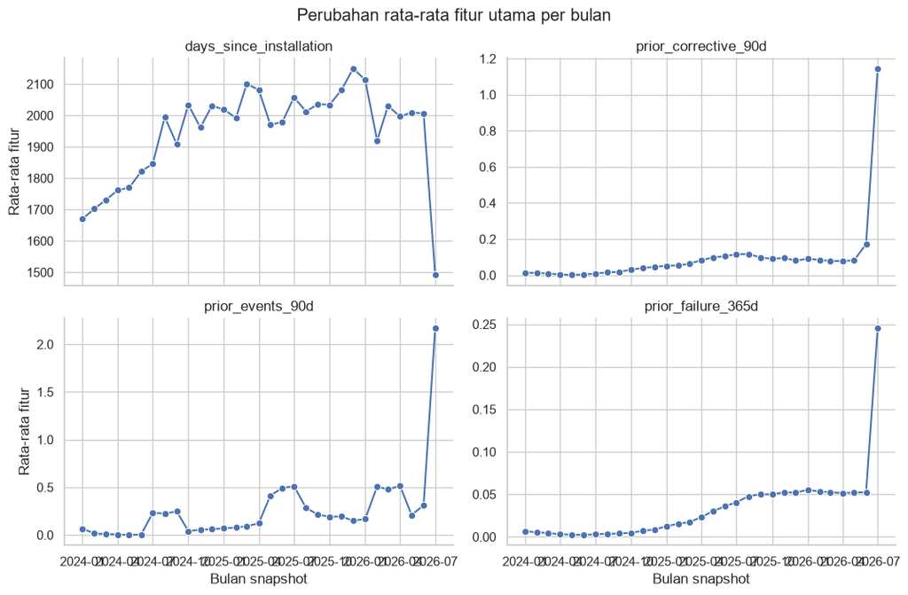

|  | Fitur | Tahun dibanding 2024 | PSI | Status drift |
| --- | --- | --- | --- | --- |
| 0 | days_since_installation | 2025 | 0.562095 | Drift besar |
| 2 | days_since_last_event | 2025 | 0.266108 | Drift besar |
| 8 | days_at_last_location | 2025 | 0.247249 | Perlu dipantau |
| 22 | prior_events_30d | 2025 | 0.104458 | Perlu dipantau |
| 4 | days_since_last_failure | 2025 | 0.053610 | Relatif stabil |
| 6 | days_since_last_corrective | 2025 | 0.053506 | Relatif stabil |
| 36 | prior_failure_365d | 2025 | 0.047895 | Relatif stabil |
| 32 | prior_corrective_180d | 2025 | 0.047576 | Relatif stabil |
| 20 | prior_repair_process_count | 2025 | 0.034954 | Relatif stabil |
| 16 | prior_relocation_count | 2025 | 0.025894 | Relatif stabil |
| 26 | prior_events_180d | 2025 | 0.025400 | Relatif stabil |
| 30 | prior_corrective_90d | 2025 | 0.021515 | Relatif stabil |
| 38 | prior_distinct_places | 2025 | 0.018166 | Relatif stabil |
| 12 | prior_failure_count | 2025 | 0.011885 | Relatif stabil |
| 28 | prior_corrective_30d | 2025 | 0.009619 | Relatif stabil |
| 10 | total_prior_events | 2025 | 0.009264 | Relatif stabil |
| 14 | prior_corrective_count | 2025 | 0.006084 | Relatif stabil |
| 18 | prior_preventive_count | 2025 | 0.000943 | Relatif stabil |
| 34 | prior_preventive_90d | 2025 | 0.000036 | Relatif stabil |
| 24 | prior_events_90d | 2025 | 0.000000 | Relatif stabil |
| 1 | days_since_installation | 2026 | 0.505108 | Drift besar |
| 9 | days_at_last_location | 2026 | 0.347579 | Drift besar |
| 3 | days_since_last_event | 2026 | 0.341624 | Drift besar |
| 23 | prior_events_30d | 2026 | 0.158043 | Perlu dipantau |
| 7 | days_since_last_corrective | 2026 | 0.124851 | Perlu dipantau |
| 5 | days_since_last_failure | 2026 | 0.112723 | Perlu dipantau |
| 27 | prior_events_180d | 2026 | 0.111097 | Perlu dipantau |
| 21 | prior_repair_process_count | 2026 | 0.100714 | Perlu dipantau |
| 17 | prior_relocation_count | 2026 | 0.100193 | Perlu dipantau |
| 37 | prior_failure_365d | 2026 | 0.081781 | Relatif stabil |
| 39 | prior_distinct_places | 2026 | 0.071764 | Relatif stabil |
| 33 | prior_corrective_180d | 2026 | 0.059452 | Relatif stabil |
| 11 | total_prior_events | 2026 | 0.041415 | Relatif stabil |
| 31 | prior_corrective_90d | 2026 | 0.030339 | Relatif stabil |
| 13 | prior_failure_count | 2026 | 0.026568 | Relatif stabil |
| 15 | prior_corrective_count | 2026 | 0.022226 | Relatif stabil |
| 29 | prior_corrective_30d | 2026 | 0.016532 | Relatif stabil |
| 19 | prior_preventive_count | 2026 | 0.008110 | Relatif stabil |
| 35 | prior_preventive_90d | 2026 | 0.003109 | Relatif stabil |
| 25 | prior_events_90d | 2026 | 0.000000 | Relatif stabil |

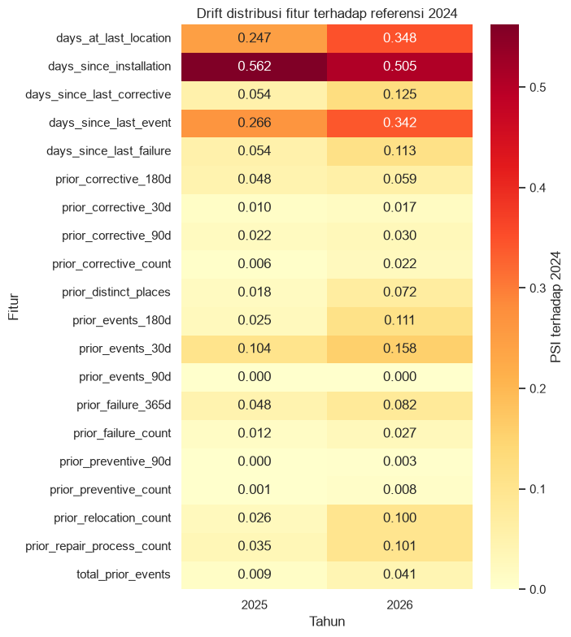

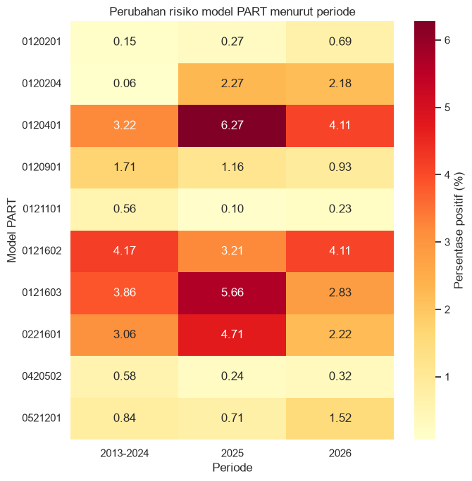

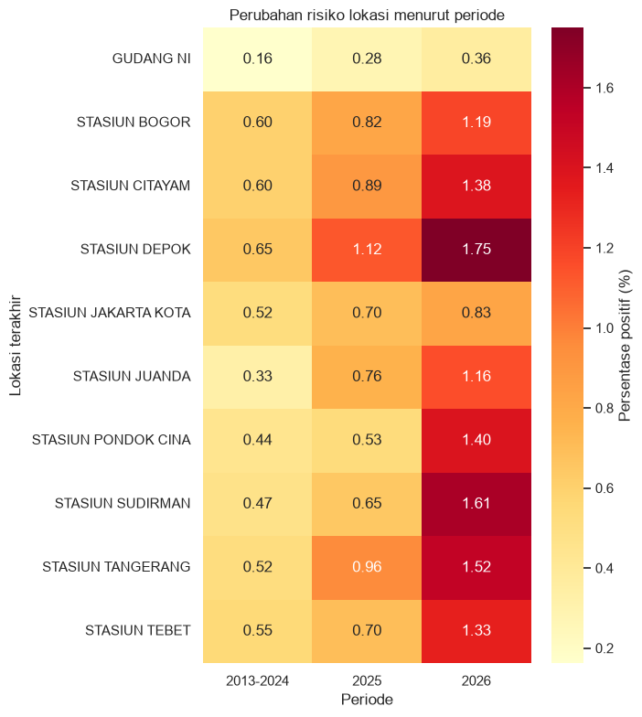

**Temuan utama:** ada **5 kombinasi fitur-tahun** dengan PSI minimal 0,25.

**Keputusan:** fitur drift tidak langsung dibuang; lakukan temporal validation, monitoring, dan tentukan kebijakan retraining.

```python
monthly_feature_stability = query("SELECT * FROM analytics.eda_feature_stability_monthly WHERE observation_month_start >= DATE '2024-01-01' ORDER BY feature_name, observation_month_start")
monthly_feature_stability['observation_month_start'] = pd.to_datetime(monthly_feature_stability.observation_month_start)
for col in ['mean_value','median_value','p90_value','missing_percentage']: monthly_feature_stability[col] = pd.to_numeric(monthly_feature_stability[col], errors='coerce')
monthly_plot = monthly_feature_stability[monthly_feature_stability.feature_name.isin(['prior_events_90d','prior_corrective_90d','prior_failure_365d','days_since_installation'])]
g = sns.relplot(data=monthly_plot, x='observation_month_start', y='mean_value', col='feature_name', col_wrap=2, kind='line', marker='o', facet_kws={'sharey':False}, height=3.4, aspect=1.6); g.set_axis_labels('Bulan snapshot','Rata-rata fitur'); g.set_titles('{col_name}'); g.fig.suptitle('Perubahan rata-rata fitur utama per bulan', y=1.03); plt.show()
drift_sample = query(f"SELECT observation_year, {feature_sql} FROM analytics.item_observation_30d WHERE is_training_eligible AND observation_on>=DATE '2024-01-01' AND MOD(ABS(HASHTEXT(installation_cycle_id || observation_date::text)::bigint),10)=0")
drift_sample[candidate_numeric_features] = drift_sample[candidate_numeric_features].apply(pd.to_numeric, errors='coerce')
def population_stability_index(reference, current):
    reference, current = pd.Series(reference), pd.Series(current)
    if reference.dropna().nunique() <= 10:
        ref_group = reference.astype('object').where(reference.notna(), 'MISSING').astype(str)
        cur_group = current.astype('object').where(current.notna(), 'MISSING').astype(str)
    else:
        internal = np.unique(reference.dropna().quantile(np.linspace(0,1,11)).to_numpy())[1:-1]
        edges = np.r_[-np.inf, internal, np.inf]
        ref_group = pd.cut(reference, edges, include_lowest=True, duplicates='drop').astype('string').fillna('MISSING')
        cur_group = pd.cut(current, edges, include_lowest=True, duplicates='drop').astype('string').fillna('MISSING')
    categories = sorted(set(ref_group) | set(cur_group))
    ref_pct = ref_group.value_counts(normalize=True).reindex(categories, fill_value=0).to_numpy(float)
    cur_pct = cur_group.value_counts(normalize=True).reindex(categories, fill_value=0).to_numpy(float)
    ref_pct, cur_pct = np.clip(ref_pct, 1e-4, None), np.clip(cur_pct, 1e-4, None)
    ref_pct, cur_pct = ref_pct/ref_pct.sum(), cur_pct/cur_pct.sum()
    return float(np.sum((cur_pct-ref_pct)*np.log(cur_pct/ref_pct)))
psi_rows = []
for feature in candidate_numeric_features:
    reference = drift_sample.loc[drift_sample.observation_year.eq(2024), feature]
    for year in [2025, 2026]:
        current = drift_sample.loc[drift_sample.observation_year.eq(year), feature]
        psi_rows.append((feature, year, population_stability_index(reference, current)))
psi_result = pd.DataFrame(psi_rows, columns=['feature','comparison_year','psi'])
psi_result['drift_status'] = pd.cut(psi_result.psi, bins=[-np.inf,.10,.25,np.inf], labels=['Relatif stabil','Perlu dipantau','Drift besar'])
display(psi_result.sort_values(['comparison_year','psi'], ascending=[True,False]).rename(columns={'feature':'Fitur','comparison_year':'Tahun dibanding 2024','psi':'PSI','drift_status':'Status drift'}))
psi_heatmap = psi_result.pivot(index='feature', columns='comparison_year', values='psi')
plt.figure(figsize=(7, 8)); sns.heatmap(psi_heatmap, annot=True, fmt='.3f', cmap='YlOrRd', vmin=0, cbar_kws={'label':'PSI terhadap 2024'}); plt.title('Drift distribusi fitur terhadap referensi 2024'); plt.xlabel('Tahun'); plt.ylabel('Fitur'); plt.tight_layout(); plt.show()
model_stability = query("""WITH top_model AS (SELECT item_model_code_clean FROM analytics.item_observation_30d WHERE is_training_eligible GROUP BY 1 ORDER BY COUNT(*) FILTER (WHERE target_failure_30d) DESC LIMIT 10) SELECT CASE WHEN observation_on < DATE '2025-01-01' THEN '2013-2024' WHEN observation_on < DATE '2026-01-01' THEN '2025' ELSE '2026' END period, item_model_code_clean, COUNT(*) observations, COUNT(DISTINCT item_identifier_clean) items, COUNT(*) FILTER (WHERE target_failure_30d) positives, ROUND(100.0 * COUNT(*) FILTER (WHERE target_failure_30d) / COUNT(*), 4) positive_pct FROM analytics.item_observation_30d JOIN top_model USING (item_model_code_clean) WHERE is_training_eligible GROUP BY 1, 2 HAVING COUNT(DISTINCT item_identifier_clean) >= 20""")
model_stability['positive_pct'] = pd.to_numeric(model_stability['positive_pct'], errors='coerce')
model_stability_heatmap = model_stability.pivot(index='item_model_code_clean', columns='period', values='positive_pct')
plt.figure(figsize=(7, 7)); sns.heatmap(model_stability_heatmap, annot=True, fmt='.2f', cmap='YlOrRd', cbar_kws={'label': 'Persentase positif (%)'}); plt.title('Perubahan risiko model PART menurut periode'); plt.xlabel('Periode'); plt.ylabel('Model PART'); plt.tight_layout(); plt.show()
location_stability = query("""WITH top_location AS (SELECT last_place_clean FROM analytics.item_observation_30d WHERE is_training_eligible AND is_location_feature_eligible GROUP BY 1 ORDER BY COUNT(*) FILTER (WHERE target_failure_30d) DESC LIMIT 10) SELECT CASE WHEN observation_on < DATE '2025-01-01' THEN '2013-2024' WHEN observation_on < DATE '2026-01-01' THEN '2025' ELSE '2026' END period, last_place_clean, COUNT(*) observations, COUNT(DISTINCT item_identifier_clean) items, COUNT(*) FILTER (WHERE target_failure_30d) positives, ROUND(100.0 * COUNT(*) FILTER (WHERE target_failure_30d) / COUNT(*), 4) positive_pct FROM analytics.item_observation_30d JOIN top_location USING (last_place_clean) WHERE is_training_eligible AND is_location_feature_eligible GROUP BY 1, 2 HAVING COUNT(DISTINCT item_identifier_clean) >= 30""")
location_stability['positive_pct'] = pd.to_numeric(location_stability['positive_pct'], errors='coerce')
location_stability_heatmap = location_stability.pivot(index='last_place_clean', columns='period', values='positive_pct')
plt.figure(figsize=(7, 8)); sns.heatmap(location_stability_heatmap, annot=True, fmt='.2f', cmap='YlOrRd', cbar_kws={'label': 'Persentase positif (%)'}); plt.title('Perubahan risiko lokasi menurut periode'); plt.xlabel('Periode'); plt.ylabel('Lokasi terakhir'); plt.tight_layout(); plt.show()
display(Markdown(f"""**Temuan utama:** ada **{int(psi_result.psi.ge(.25).sum())} kombinasi fitur-tahun** dengan PSI minimal 0,25.

**Keputusan:** fitur drift tidak langsung dibuang; lakukan temporal validation, monitoring, dan tentukan kebijakan retraining."""))
```

### 11.2 Anomali, cleaning decision, dan feature decision

Lonjakan aktivitas, timeline aneh, serta daftar cleaning ditampilkan bersama tindakan pipeline. Keputusan feature engineering di sini adalah rekomendasi berdasarkan EDA, belum transformasi modeling final.

|  | Dismantle tanpa installation sebelumnya | Urutan waktu negatif | Event dengan gap nol | Gap lebih dari 10 tahun |
| --- | --- | --- | --- | --- |
| 0 | 609 | 0 | 1554 | 322 |

|  | Hari dengan lonjakan ekstrem | Event terbanyak dalam satu hari | Rata-rata event harian | Batas outlier harian |
| --- | --- | --- | --- | --- |
| 0 | 320 | 4011 | 49.68 | 76.0 |

|  | Tanggal | Semua event | Installed | Dismantled | RECON administratif | Penerimaan gudang massal | Batas outlier |
| --- | --- | --- | --- | --- | --- | --- | --- |
| 0 | 2024-07-03 | 4011 | 0 | 0 | 0 | 4011 | 76.0 |
| 1 | 2023-08-21 | 3809 | 0 | 1 | 0 | 0 | 76.0 |
| 2 | 2023-08-28 | 3719 | 3715 | 4 | 11 | 0 | 76.0 |
| 3 | 2023-08-07 | 3718 | 1 | 3 | 0 | 0 | 76.0 |
| 4 | 2023-08-14 | 3712 | 2 | 0 | 2 | 0 | 76.0 |
| 5 | 2017-08-09 | 3444 | 2 | 1 | 0 | 0 | 76.0 |
| 6 | 2012-12-31 | 3060 | 0 | 0 | 0 | 0 | 76.0 |
| 7 | 2025-02-11 | 2974 | 1481 | 1481 | 2956 | 0 | 76.0 |
| 8 | 2023-03-05 | 2611 | 1564 | 1037 | 2600 | 0 | 76.0 |
| 9 | 2024-10-01 | 2548 | 1031 | 1496 | 2518 | 0 | 76.0 |
| 10 | 2025-02-20 | 2344 | 1178 | 1113 | 2274 | 0 | 76.0 |
| 11 | 2025-02-21 | 2262 | 1152 | 1107 | 2256 | 0 | 76.0 |
| 12 | 2013-05-31 | 2256 | 0 | 0 | 0 | 0 | 76.0 |
| 13 | 2025-02-22 | 2093 | 1064 | 1029 | 2093 | 0 | 76.0 |
| 14 | 2025-02-16 | 1755 | 858 | 897 | 1754 | 0 | 76.0 |
| 15 | 2017-08-08 | 1742 | 17 | 2 | 0 | 0 | 76.0 |
| 16 | 2017-08-06 | 1737 | 0 | 0 | 0 | 285 | 76.0 |
| 17 | 2017-08-10 | 1722 | 1718 | 0 | 0 | 0 | 76.0 |
| 18 | 2013-12-30 | 1600 | 0 | 0 | 0 | 0 | 76.0 |
| 19 | 2025-02-23 | 1597 | 783 | 794 | 1568 | 0 | 76.0 |

Lonjakan terbesar terjadi pada **03-07-2024** sebanyak **4.011 event**. Rinciannya: **4.011 penerimaan gudang massal**. **0 installation**. **0 dismantle**. dan **0 RECON administratif**. Karena itu lonjakan terbesar bukan failure maupun pemasangan.

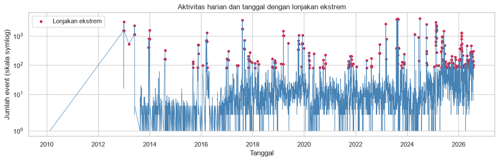

|  | Tindakan yang disarankan | Jumlah baris |
| --- | --- | --- |
| 0 | EXCLUDE_FROM_INITIAL_MODEL_COHORT | 732 |
| 1 | EXCLUDE_FROM_TIME_MODEL_AND_REVIEW_SOURCE | 75 |
| 2 | REVIEW_BEFORE_DEDUPLICATION | 50 |
| 3 | KEEP_EVENT_EXCLUDE_LOCATION_FEATURE | 15 |

|  | Journey ID | Model | Status | Lokasi mentah | Waktu | Masalah | Tindakan |
| --- | --- | --- | --- | --- | --- | --- | --- |
| 0 | 1030 | 0110402 | OK | STASIUN LENTENG AGUNG | 2017-08-06 09:00:00 | {JOURNEY_MODEL_INCONSISTENT} | EXCLUDE_FROM_INITIAL_MODEL_COHORT |
| 1 | 12467 | 0110402 | REQUESTED | STASIUN LENTENG AGUNG | 2017-08-08 12:00:00 | {JOURNEY_MODEL_INCONSISTENT} | EXCLUDE_FROM_INITIAL_MODEL_COHORT |
| 2 | 23904 | 0110402 | ISSUE ITEM | STASIUN LENTENG AGUNG | 2017-08-09 15:00:00 | {JOURNEY_MODEL_INCONSISTENT} | EXCLUDE_FROM_INITIAL_MODEL_COHORT |
| 3 | 35341 | 0110402 | DELIVERY | STASIUN LENTENG AGUNG | 2017-08-09 17:00:00 | {JOURNEY_MODEL_INCONSISTENT} | EXCLUDE_FROM_INITIAL_MODEL_COHORT |
| 4 | 46778 | 0110402 | INSTALLED | STASIUN LENTENG AGUNG | 2017-08-10 21:00:00 | {JOURNEY_MODEL_INCONSISTENT} | EXCLUDE_FROM_INITIAL_MODEL_COHORT |
| 5 | 144407 | 0110402 | DISMANTLED | STASIUN LENTENG AGUNG | 2023-03-05 09:00:00 | {JOURNEY_MODEL_INCONSISTENT} | EXCLUDE_FROM_INITIAL_MODEL_COHORT |
| 6 | 147258 | 0420503 | INSTALLED | STASIUN BOGOR | 2023-12-13 16:00:00 | {JOURNEY_MODEL_INCONSISTENT} | EXCLUDE_FROM_INITIAL_MODEL_COHORT |
| 7 | 147266 | 0420503 | INSTALLED | STASIUN BOGOR | 2023-03-05 16:00:00 | {JOURNEY_MODEL_INCONSISTENT} | EXCLUDE_FROM_INITIAL_MODEL_COHORT |
| 8 | 147316 | 0420503 | INSTALLED | STASIUN PONDOK RAJEG | 2024-02-18 16:00:00 | {JOURNEY_MODEL_INCONSISTENT} | EXCLUDE_FROM_INITIAL_MODEL_COHORT |
| 9 | 147331 | 0220601 | INSTALLED | STASIUN BOJONG GEDE | 2023-03-05 16:00:00 | {JOURNEY_MODEL_INCONSISTENT} | EXCLUDE_FROM_INITIAL_MODEL_COHORT |
| 10 | 147334 | 0220601 | INSTALLED | STASIUN BOJONG GEDE | 2023-03-05 16:00:00 | {JOURNEY_MODEL_INCONSISTENT} | EXCLUDE_FROM_INITIAL_MODEL_COHORT |
| 11 | 147342 | 0220602 | INSTALLED | STASIUN BOJONG GEDE | 2023-03-05 16:00:00 | {JOURNEY_MODEL_INCONSISTENT} | EXCLUDE_FROM_INITIAL_MODEL_COHORT |
| 12 | 147344 | 0420503 | INSTALLED | STASIUN BOJONG GEDE | 2023-03-05 16:00:00 | {JOURNEY_MODEL_INCONSISTENT} | EXCLUDE_FROM_INITIAL_MODEL_COHORT |
| 13 | 147359 | 0420503 | INSTALLED | STASIUN CAWANG | 2023-03-05 16:00:00 | {JOURNEY_MODEL_INCONSISTENT} | EXCLUDE_FROM_INITIAL_MODEL_COHORT |
| 14 | 147361 | 0420503 | INSTALLED | STASIUN CAWANG | 2023-03-05 16:00:00 | {JOURNEY_MODEL_INCONSISTENT} | EXCLUDE_FROM_INITIAL_MODEL_COHORT |
| 15 | 147381 | 0220601 | INSTALLED | STASIUN CIBINONG | 2023-03-05 16:00:00 | {JOURNEY_MODEL_INCONSISTENT} | EXCLUDE_FROM_INITIAL_MODEL_COHORT |
| 16 | 147420 | 0220601 | INSTALLED | STASIUN CILEBUT | 2023-03-05 16:00:00 | {JOURNEY_MODEL_INCONSISTENT} | EXCLUDE_FROM_INITIAL_MODEL_COHORT |
| 17 | 147437 | 0420503 | INSTALLED | STASIUN CITAYAM | 2023-03-05 16:00:00 | {JOURNEY_MODEL_INCONSISTENT} | EXCLUDE_FROM_INITIAL_MODEL_COHORT |
| 18 | 147448 | 0420503 | INSTALLED | STASIUN CITAYAM | 2023-04-24 16:00:00 | {JOURNEY_MODEL_INCONSISTENT} | EXCLUDE_FROM_INITIAL_MODEL_COHORT |
| 19 | 147461 | 0420503 | INSTALLED | STASIUN CITAYAM | 2023-03-05 16:00:00 | {JOURNEY_MODEL_INCONSISTENT} | EXCLUDE_FROM_INITIAL_MODEL_COHORT |
| 20 | 147472 | 0220601 | INSTALLED | STASIUN CITAYAM | 2023-03-05 16:00:00 | {JOURNEY_MODEL_INCONSISTENT} | EXCLUDE_FROM_INITIAL_MODEL_COHORT |
| 21 | 147476 | 0220602 | INSTALLED | STASIUN CITAYAM | 2023-03-05 16:00:00 | {JOURNEY_MODEL_INCONSISTENT} | EXCLUDE_FROM_INITIAL_MODEL_COHORT |
| 22 | 147484 | 0420503 | INSTALLED | STASIUN DEPOK | 2023-03-05 16:00:00 | {JOURNEY_MODEL_INCONSISTENT} | EXCLUDE_FROM_INITIAL_MODEL_COHORT |
| 23 | 147493 | 0220601 | INSTALLED | STASIUN DEPOK | 2023-03-05 16:00:00 | {JOURNEY_MODEL_INCONSISTENT} | EXCLUDE_FROM_INITIAL_MODEL_COHORT |
| 24 | 147503 | 0220601 | INSTALLED | STASIUN DEPOK | 2023-03-05 16:00:00 | {JOURNEY_MODEL_INCONSISTENT} | EXCLUDE_FROM_INITIAL_MODEL_COHORT |
| 25 | 147530 | 0420503 | INSTALLED | STASIUN DEPOK BARU | 2024-05-03 16:00:00 | {JOURNEY_MODEL_INCONSISTENT} | EXCLUDE_FROM_INITIAL_MODEL_COHORT |
| 26 | 147540 | 0420503 | INSTALLED | STASIUN DUREN KALIBATA | 2023-03-05 16:00:00 | {JOURNEY_MODEL_INCONSISTENT} | EXCLUDE_FROM_INITIAL_MODEL_COHORT |
| 27 | 147551 | 0420503 | INSTALLED | STASIUN DUREN KALIBATA | 2023-03-05 16:00:00 | {JOURNEY_MODEL_INCONSISTENT} | EXCLUDE_FROM_INITIAL_MODEL_COHORT |
| 28 | 147574 | 0420503 | INSTALLED | STASIUN LENTENG AGUNG | 2023-03-05 16:00:00 | {JOURNEY_MODEL_INCONSISTENT} | EXCLUDE_FROM_INITIAL_MODEL_COHORT |
| 29 | 147581 | 0420503 | INSTALLED | STASIUN LENTENG AGUNG | 2023-03-05 16:00:00 | {JOURNEY_MODEL_INCONSISTENT} | EXCLUDE_FROM_INITIAL_MODEL_COHORT |

|  | Kondisi | Perlakuan |
| --- | --- | --- |
| 0 | RECON administratif | Simpan untuk audit; keluarkan dari perhitungan... |
| 1 | Penerimaan gudang massal | Simpan sebagai event operasional dengan semant... |
| 2 | Tanggal invalid/masa depan | Keluarkan dari timeline/model dan periksa sumber |
| 3 | Identifier/model inti kosong | Keluarkan dari pembentukan cycle |
| 4 | Model tidak konsisten | Keluarkan dari cohort awal model |
| 5 | Fuzzy skor tinggi dan margin aman | Gunakan nama canonical; simpan nama sumber, sk... |
| 6 | Fuzzy skor rendah/ambigu | Jangan auto-map; masukkan daftar review |
| 7 | Lokasi tidak cocok master | Simpan event; jangan gunakan fitur lokasi |
| 8 | Isi log identik | Review journey_id; deduplikasi hanya setelah d... |
| 9 | Cycle durasi nol/negatif | Keluarkan dari cohort |
| 10 | Snapshot follow-up belum lengkap | Keluarkan dari training |
| 11 | Failure tanpa flow lanjutan | Tetap positif jika onset valid; tandai untuk r... |
| 12 | Reinstall tanpa failure tercatat | Tandai unknown; jangan otomatis menjadi negatif |
| 13 | Coverage aktivitas right-censored belum terkon... | Simpan flag dan uji sensitivity dataset konser... |
| 14 | Cycle masih berjalan | Gunakan hanya snapshot dengan follow-up 30 har... |

|  | Bulan invalid | Hari invalid | Flag weekend tidak sesuai |
| --- | --- | --- | --- |
| 0 | 0 | 0 | 0 |

|  | Fitur/ide | Keputusan EDA |
| --- | --- | --- |
| 0 | Target sangat imbalance | Gunakan stratified temporal evaluation; nilai ... |
| 1 | Model dan tipe PART | Gunakan; kategori utama item |
| 2 | Client canonical | Gunakan dengan minimum support; kelompokkan ka... |
| 3 | Lokasi canonical | Coverage aman; uji model dengan dan tanpa loka... |
| 4 | Umur sejak installation | Gunakan bila tidak redundan setelah seleksi ko... |
| 5 | Bulan, kuartal, hari, weekend | Gunakan sebagai kandidat; validasi kestabilan ... |
| 6 | Event/corrective/preventive 30-90-180 hari | Pilih window yang tidak redundan atau gunakan ... |
| 7 | Failure 365 hari sebelumnya | Gunakan sebagai kandidat |
| 8 | Waktu sejak corrective/failure terakhir yang k... | Missing bersifat struktural; gunakan indikator... |
| 9 | Lama di lokasi terakhir | Gunakan hanya dari event masa lalu dan lokasi ... |
| 10 | Fitur dengan PSI >=0,25 | Jangan langsung dibuang; cek perubahan proses/... |
| 11 | Interaksi model-lokasi | Uji dengan regularisasi/minimum support; janga... |
| 12 | Status/outcome setelah snapshot | Dilarang karena leakage |

```python
timeline_anomaly = query("""WITH ordered AS (SELECT o.*, MAX(created_on) FILTER (WHERE status_clean='INSTALLED') OVER (PARTITION BY item_identifier_clean ORDER BY created_on, journey_id ROWS BETWEEN UNBOUNDED PRECEDING AND 1 PRECEDING) prior_installed_on FROM analytics.item_journey_operational_timeline o) SELECT COUNT(*) FILTER (WHERE status_clean='DISMANTLED' AND prior_installed_on IS NULL) dismantle_without_prior_install, COUNT(*) FILTER (WHERE days_since_previous_operational_event<0) negative_gap, COUNT(*) FILTER (WHERE days_since_previous_operational_event=0) zero_gap, COUNT(*) FILTER (WHERE days_since_previous_operational_event>3652.5) gap_gt_10y FROM ordered""")
daily_anomaly_summary = query("SELECT COUNT(*) FILTER (WHERE is_extreme_activity_day) extreme_days, MAX(event_count) max_daily_events, ROUND(AVG(event_count)::numeric,2) average_daily_events, MAX(extreme_event_limit) extreme_limit FROM analytics.eda_daily_activity_anomaly")
display(timeline_anomaly.rename(columns={'dismantle_without_prior_install': 'Dismantle tanpa installation sebelumnya', 'negative_gap': 'Urutan waktu negatif', 'zero_gap': 'Event dengan gap nol', 'gap_gt_10y': 'Gap lebih dari 10 tahun'}))
display(daily_anomaly_summary.rename(columns={'extreme_days': 'Hari dengan lonjakan ekstrem', 'max_daily_events': 'Event terbanyak dalam satu hari', 'average_daily_events': 'Rata-rata event harian', 'extreme_limit': 'Batas outlier harian'}))
top_daily_anomaly = query("SELECT activity_date, event_count, installation_count, dismantle_count, admin_recon_count, bulk_warehouse_reception_count, extreme_event_limit FROM analytics.eda_daily_activity_anomaly WHERE is_extreme_activity_day ORDER BY event_count DESC LIMIT 20")
display(top_daily_anomaly.rename(columns={'activity_date': 'Tanggal', 'event_count': 'Semua event', 'installation_count': 'Installed', 'dismantle_count': 'Dismantled', 'admin_recon_count': 'RECON administratif', 'bulk_warehouse_reception_count': 'Penerimaan gudang massal', 'extreme_event_limit': 'Batas outlier'}))
largest_spike = top_daily_anomaly.iloc[0]
display(Markdown(f"Lonjakan terbesar terjadi pada **{largest_spike.activity_date:%d-%m-%Y}** sebanyak **{int(largest_spike.event_count):,} event**. Rinciannya: **{int(largest_spike.bulk_warehouse_reception_count):,} penerimaan gudang massal**, **{int(largest_spike.installation_count):,} installation**, **{int(largest_spike.dismantle_count):,} dismantle**, dan **{int(largest_spike.admin_recon_count):,} RECON administratif**. Karena itu lonjakan terbesar bukan failure maupun pemasangan.".replace(',', '.')))
daily_activity = query("SELECT activity_date, event_count, is_extreme_activity_day FROM analytics.eda_daily_activity_anomaly ORDER BY activity_date"); daily_activity['activity_date'] = pd.to_datetime(daily_activity.activity_date); daily_activity['event_count'] = pd.to_numeric(daily_activity.event_count)
plt.figure(figsize=(12, 4)); sns.lineplot(data=daily_activity, x='activity_date', y='event_count', color='steelblue', linewidth=.7); extreme_plot=daily_activity[daily_activity.is_extreme_activity_day]; plt.scatter(extreme_plot.activity_date, extreme_plot.event_count, color='crimson', s=12, label='Lonjakan ekstrem'); plt.yscale('symlog'); plt.title('Aktivitas harian dan tanggal dengan lonjakan ekstrem'); plt.xlabel('Tanggal'); plt.ylabel('Jumlah event (skala symlog)'); plt.legend(); plt.tight_layout(); plt.show()
cleaning_actions = query("SELECT suggested_action, COUNT(*) affected_rows FROM analytics.eda_cleaning_review_detail GROUP BY suggested_action ORDER BY affected_rows DESC")
display(cleaning_actions.rename(columns={'suggested_action': 'Tindakan yang disarankan', 'affected_rows': 'Jumlah baris'}))
cleaning_sample = query("SELECT journey_id, item_model_code_clean, status_clean, place_clean, created_on, review_issues::text, suggested_action FROM analytics.eda_cleaning_review_detail ORDER BY suggested_action, journey_id LIMIT 30")
display(cleaning_sample.rename(columns={'journey_id': 'Journey ID', 'item_model_code_clean': 'Model', 'status_clean': 'Status', 'place_clean': 'Lokasi mentah', 'created_on': 'Waktu', 'review_issues': 'Masalah', 'suggested_action': 'Tindakan'}))
cleaning_policy = pd.DataFrame([['RECON administratif','Simpan untuk audit; keluarkan dari perhitungan waktu'],['Penerimaan gudang massal','Simpan sebagai event operasional dengan semantic khusus; jangan artikan sebagai install/dismantle/failure'],['Tanggal invalid/masa depan','Keluarkan dari timeline/model dan periksa sumber'],['Identifier/model inti kosong','Keluarkan dari pembentukan cycle'],['Model tidak konsisten','Keluarkan dari cohort awal model'],['Fuzzy skor tinggi dan margin aman','Gunakan nama canonical; simpan nama sumber, skor, dan metode mapping'],['Fuzzy skor rendah/ambigu','Jangan auto-map; masukkan daftar review'],['Lokasi tidak cocok master','Simpan event; jangan gunakan fitur lokasi'],['Isi log identik','Review journey_id; deduplikasi hanya setelah dikonfirmasi'],['Cycle durasi nol/negatif','Keluarkan dari cohort'],['Snapshot follow-up belum lengkap','Keluarkan dari training'],['Failure tanpa flow lanjutan','Tetap positif jika onset valid; tandai untuk review'],['Reinstall tanpa failure tercatat','Tandai unknown; jangan otomatis menjadi negatif'],['Coverage aktivitas right-censored belum terkonfirmasi','Simpan flag dan uji sensitivity dataset konservatif'],['Cycle masih berjalan','Gunakan hanya snapshot dengan follow-up 30 hari penuh']], columns=['Kondisi','Perlakuan'])
display(cleaning_policy)
calendar_feature_check = query("SELECT COUNT(*) FILTER (WHERE observation_month NOT BETWEEN 1 AND 12) invalid_month, COUNT(*) FILTER (WHERE observation_day_of_week NOT BETWEEN 1 AND 7) invalid_day, COUNT(*) FILTER (WHERE is_weekend IS DISTINCT FROM (observation_day_of_week IN (6,7))) invalid_weekend FROM analytics.item_observation_30d")
display(calendar_feature_check.rename(columns={'invalid_month': 'Bulan invalid', 'invalid_day': 'Hari invalid', 'invalid_weekend': 'Flag weekend tidak sesuai'}))
feature_decisions = pd.DataFrame([['Target sangat imbalance','Gunakan stratified temporal evaluation; nilai precision, recall, PR-AUC, ROC-AUC, calibration; class weight/resampling hanya pada train'],['Model dan tipe PART','Gunakan; kategori utama item'],['Client canonical','Gunakan dengan minimum support; kelompokkan kategori langka bila perlu'],['Lokasi canonical','Coverage aman; uji model dengan dan tanpa lokasi, UNKNOWN, dan missing flag'],['Umur sejak installation','Gunakan bila tidak redundan setelah seleksi korelasi'],['Bulan, kuartal, hari, weekend','Gunakan sebagai kandidat; validasi kestabilan antarperiode'],['Event/corrective/preventive 30-90-180 hari','Pilih window yang tidak redundan atau gunakan regularisasi; keputusan berdasarkan temporal validation'],['Failure 365 hari sebelumnya','Gunakan sebagai kandidat'],['Waktu sejak corrective/failure terakhir yang kosong','Missing bersifat struktural; gunakan indikator belum pernah + sentinel, bukan imputasi nol tanpa flag'],['Lama di lokasi terakhir','Gunakan hanya dari event masa lalu dan lokasi valid; sertakan missing flag'],['Fitur dengan PSI >=0,25','Jangan langsung dibuang; cek perubahan proses/data, retrain policy, dan monitoring drift'],['Interaksi model-lokasi','Uji dengan regularisasi/minimum support; jangan langsung membuat ribuan kategori'],['Status/outcome setelah snapshot','Dilarang karena leakage']], columns=['Fitur/ide','Keputusan EDA'])
display(feature_decisions)
```

### 11.3 Kesimpulan dan next action

Kesimpulan berikut dibuat dari seluruh chapter. Angka detail dapat berubah ketika pipeline diperbarui, sehingga executive summary terpisah dihasilkan otomatis dari view database saat report diekspor.

```python
weekly = cadence.loc[cadence.cadence_days.eq(7)].iloc[0]
monthly = cadence.loc[cadence.cadence_days.eq(30)].iloc[0]
ongoing_count = int(incomplete.loc[incomplete.followup_review_group.eq('LIKELY_ONGOING_0_30D'), 'failure_count'].iloc[0])
history_gap_count = int(incomplete.loc[incomplete.followup_review_group.eq('LIKELY_HISTORY_GAP_GT_180D'), 'failure_count'].iloc[0])
display(Markdown(f"""**Kesimpulan sederhana**

- Snapshot 7 hari dan 30 hari sama-sama melewatkan **{int(weekly.uncaptured_failure_cycles)}** dan **{int(monthly.uncaptured_failure_cycles)}** failure.
- Snapshot mingguan memberi rata-rata **{weekly.average_positive_snapshots_per_failure:.2f}** peringatan untuk satu failure; snapshot 30 hari memberi **{monthly.average_positive_snapshots_per_failure:.2f}**.
- Ada **{ongoing_count}** failure yang kemungkinan masih berjalan karena terjadi maksimal 30 hari sebelum data berakhir.
- Ada **{history_gap_count}** failure lama yang lebih mungkin memiliki histori lanjutan tidak lengkap.
- Ada **{len(missing_onset)}** kandidat status rusak tanpa tanggal awal failure yang dapat dipercaya; kasus ini belum menjadi label utama.
- Ada **{unknown_reinstall_count} cycle reinstall** yang tidak lagi otomatis menjadi negatif dan **{coverage_unconfirmed_count} cycle** dengan coverage aktivitas belum terkonfirmasi.
- Target sangat tidak seimbang: positive rate hanya **{float(positive_row.class_percentage):.4f}%**, atau sekitar **1 positif berbanding {float(positive_row.negative_to_positive_ratio):.2f} negatif**.
- Audit korelasi menemukan **{len(redundant_pairs)} pasangan fitur** dengan |Spearman| minimal 0,80; pasangan tersebut perlu seleksi atau regularisasi, bukan dimasukkan seluruhnya tanpa evaluasi.
- Screening IV teratas adalah **{iv_result.iloc[0].feature}** dengan IV **{iv_result.iloc[0].information_value:.4f}**; hasil ini masih univariat dan wajib diuji dengan split waktu.
- Analisis PSI menemukan **{int(psi_result.psi.ge(.25).sum())} kombinasi fitur-tahun** dengan drift besar terhadap 2024; 2026 masih merupakan periode parsial.
- Unmatched lokasi hanya mengenai **{int(location_coverage.unmatched_snapshot)} snapshot ({float(location_coverage.unmatched_percentage):.4f}%)** dari data training; fitur lokasi boleh diuji dengan UNKNOWN/missing flag dan pembanding tanpa lokasi.
- Audit journal menemukan **{int(journal_quality.loc[journal_quality.check_name.eq('EXACT_LOG_DUPLICATE_EXTRA_ROWS'), 'affected_count'].iloc[0])}** baris tambahan dengan isi identik, **{int(journal_quality.loc[journal_quality.check_name.eq('INVALID_OR_FUTURE_DATE'), 'affected_count'].iloc[0])}** tanggal invalid/masa depan, dan **{int(journal_quality.loc[journal_quality.check_name.eq('LOCATION_NOT_IN_MASTER'), 'affected_count'].iloc[0])}** event lokasi non-master.
- Typo client `KERETE COMMUTER INDONESIA (KCI)` dipetakan secara fuzzy ke `KERETA COMMUTER INDONESIA (KCI)` dengan skor dan margin yang lolos batas aman.
- `GUDANG NUTECH` dipetakan ke `GUDANG NI` melalui alias kontekstual; `NOC JUANDA` tetap review karena kandidatnya ambigu.
- Lonjakan **{int(largest_spike.event_count):,} event** terbesar adalah penerimaan gudang massal, bukan installation, dismantle, atau failure.
- Lifecycle yang lokasi installation dan dismantle-nya sama memiliki median **{float(lifecycle_overall.median_days.iloc[0]):,.2f} hari**; cycle tanpa dismantle tidak dipaksa menjadi nol.
- Lokasi hanya digunakan apabila cocok dengan master lokasi.
- Fitur kalender bulan, kuartal, hari dalam minggu, dan weekend sudah ditambahkan tanpa memakai informasi setelah snapshot.
- Untuk baseline training, snapshot 30 hari lebih ringkas: semua failure tetap tertangkap dan satu failure tidak diulang hampir empat kali.
- Saat dipakai nanti, model tetap dapat dijalankan setiap hari atau setiap ada event baru; jadwal scoring tidak harus mengikuti jarak snapshot training.
- Data siap dilanjutkan ke baseline model, sambil mereview sampel kasus histori lama dan membandingkan performa model dengan serta tanpa fitur lokasi."""))
```

**Kesimpulan sederhana**

- Snapshot 7 hari dan 30 hari sama-sama melewatkan **0** dan **0** failure.

- Snapshot mingguan memberi rata-rata **3.86** peringatan untuk satu failure; snapshot 30 hari memberi **1.00**.

- Ada **82** failure yang kemungkinan masih berjalan karena terjadi maksimal 30 hari sebelum data berakhir.

- Ada **478** failure lama yang lebih mungkin memiliki histori lanjutan tidak lengkap.

- Ada **1** kandidat status rusak tanpa tanggal awal failure yang dapat dipercaya; kasus ini belum menjadi label utama.

- Ada **1185 cycle reinstall** yang tidak lagi otomatis menjadi negatif dan **16754 cycle** dengan coverage aktivitas belum terkonfirmasi.

- Target sangat tidak seimbang: positive rate hanya **0.4438%**, atau sekitar **1 positif berbanding 224.35 negatif**.

- Audit korelasi menemukan **10 pasangan fitur** dengan |Spearman| minimal 0,80; pasangan tersebut perlu seleksi atau regularisasi, bukan dimasukkan seluruhnya tanpa evaluasi.

- Screening IV teratas adalah **days_since_last_corrective** dengan IV **1.2079**; hasil ini masih univariat dan wajib diuji dengan split waktu.

- Analisis PSI menemukan **5 kombinasi fitur-tahun** dengan drift besar terhadap 2024; 2026 masih merupakan periode parsial.

- Unmatched lokasi hanya mengenai **174 snapshot (0.0131%)** dari data training; fitur lokasi boleh diuji dengan UNKNOWN/missing flag dan pembanding tanpa lokasi.

- Audit journal menemukan **27** baris tambahan dengan isi identik, **75** tanggal invalid/masa depan, dan **15** event lokasi non-master.

- Typo client `KERETE COMMUTER INDONESIA (KCI)` dipetakan secara fuzzy ke `KERETA COMMUTER INDONESIA (KCI)` dengan skor dan margin yang lolos batas aman.

- `GUDANG NUTECH` dipetakan ke `GUDANG NI` melalui alias kontekstual; `NOC JUANDA` tetap review karena kandidatnya ambigu.

- Lonjakan **4,011 event** terbesar adalah penerimaan gudang massal, bukan installation, dismantle, atau failure.

- Lifecycle yang lokasi installation dan dismantle-nya sama memiliki median **471.55 hari**; cycle tanpa dismantle tidak dipaksa menjadi nol.

- Lokasi hanya digunakan apabila cocok dengan master lokasi.

- Fitur kalender bulan, kuartal, hari dalam minggu, dan weekend sudah ditambahkan tanpa memakai informasi setelah snapshot.

- Untuk baseline training, snapshot 30 hari lebih ringkas: semua failure tetap tertangkap dan satu failure tidak diulang hampir empat kali.

- Saat dipakai nanti, model tetap dapat dijalankan setiap hari atau setiap ada event baru; jadwal scoring tidak harus mengikuti jarak snapshot training.

- Data siap dilanjutkan ke baseline model, sambil mereview sampel kasus histori lama dan membandingkan performa model dengan serta tanpa fitur lokasi.